# JJM User Guide

# SPRFMO

South Pacific Regional Fisheries Management Organisation

Jack Mackerel Working Group

The Joint Jack Mackerel (JJM) model: A user guide

Mirian GERONIMO, Criscely LUJAN, Josymar TORREJON, Elmer QUISPE  
Instituto del Mar del Peru (IMARPE)

# Abstract

This document is intended to serve as a user’s guide for those interested in learning about the JJM model internally and how to use it. Therefore, it focuses on the description of the mathematical equations of the population dynamics of Jack Mackerel, and computational aspects such as software installation (AD Model Builder), input and output files, model run, and a case study illustrating the practical application of the JJM model. Finally, it is important to mention that this document was created by Imarpe as a proposal to enhance the understanding of the model’s internal aspects and that it is open to collaborations for future versions.

# 1 Introduction

This document provides a concise overview of the model, including its history and the primary assumptions regarding its structure. It will also cover the algebraic specifications of the assessment model, detailing the mathematical equations used to simulate the population dynamics of Jack mackerel and the functions defined in the model code to obtain key quantities such as the maximum sustainable yield (MSY), biological reference points (BRPs), and catch projections.

To achieve this, the model code found [in the SPRFMO repository](https://github.com/SPRFMO/jjm/blob/main/src/jjm.tpl) has been reviewed and clarified regarding how the input data (data and control files) are used within the model, as well as what parameters are being estimated. In addition, a description of the main steps to install the JJM and run the model has been provided.

Finally, a data set is provided and used as part of a case study (Appendix A). This information is used as input to simulate an assessment (Appendix B). Part of the concepts of the JJM model presented here come from [SPRFMO SC10 Report-Annex 10- Jack Mackerel Technical Annex](https://www.sprfmo.int/assets/Meetings/SC/10th-SC-2022/Report-and-Annexes/Annex-8-JM-Technical-Advice-CV_2.pdf). This document is intended to provide an illustrative description of the JJM model that can support and guide current or potential users.

# 2 Joint Jack Mackerel (JJM) model

The JJM model was adopted as the assessment model in the South Pacific Regional Fisheries Management Organisation (SPRFMO) in 2010. Each year, the model data is updated, and then the model is run using the updated data inputs and indices. The results of the model are used to recommend the status of the Jack Mackerel population for its exploitation. Additionally, the JJM model has been adopted by SPRFMO delegations, such as the Peruvian delegation, which uses the same model to assess the Jack mackerel in Peruvian national jurisdictional waters.

The JJM model, implemented in AD Molder Builder ([ADMB](https://www.admb-project.org/)), uses a forward projection approach and maximum likelihood estimation to solve for model parameters. The operational population dynamics model of the JJM is defined by the standard catch equation with various modifications such as those described by Fournier & Archibald (1982)(D. Fournier and Archibald 1982), Hilborn & Walters (1992) (Hilborn and Walters 1992) and Schnute & Richards (1995)(Schnute and Richards 1995).

## 2.1 Model history

Since its adoption as an assessment method in 2010, the JJM model has undergone continuous development and improvement by scientists participating in the SPRFMO. The most important changes include: (i) the inclusion of length composition data and the specification or estimation of growth, (ii) the estimation of natural mortality by age and time, and (iii) the consideration of two stock hypotheses in one run execution.

Nowadays, the model allows the use of catch information either at age or size for any fleet. This is an important change that provides flexibility in data usage. Besides, another important change is the explicit incorporation of regime shifts.

The model consists of four main components: i) the dynamics of the stock, ii) the fishery dynamics, iii) the observation models for data, and iv) the procedure used for parameter estimation (including uncertainties).

## 2.2 Main assumptions

A statistical catch-at-age model analyzes data on the age of fish caught in scientific surveys and by fisheries to provide management advice. Catch-at-age models typically require information on age, fishing effort, and total catches for each fishery targeting a stock.

In order to use a statistical catch-at-age model, we need data on the observed catch from the fishery and index surveys, as well as weight-at-age information for both fisheries and index surveys. Additionally, population weight for each stock and maturity data are required for each age class, where an age class encompasses all fish of the same age.  
Catch-at-age results provide comprehensive management advice by estimating a stock’s current size and the management reference points (e.g. maximum sustainable yield (MSY)). The main assumptions of these models, implemented in the JJM model, are detailed in the following sections.

### 2.2.1 Stock dynamics

- The JJM model is not spatially-explicit, although the fisheries operate in geographically distinct areas.
- The model needs initial conditions that should preferably be set at equilibrium conditions.
- The population’s age composition considers individuals of different ages (from 1 to more). But in all cases, a stochastic Beverton-Holt relationship is included.
- The recruitment and the spawning season should be assumed to occur in a specific time.
- The source of mortality is age-specific and composed of fishing mortality at age by fleet and natural mortality. Currently, in the SPRFMO assessment, natural mortality is assumed to be constant over time and age but in the JJM model it is flexible to variability and even estimation.

### 2.2.2 Fishery dynamics

- The JJM model assumes that the interaction of the population with the fishery occurs through fishing mortality.
- The fishing mortality is assumed to be a composite of several processes: selectivity by fleet, catchability, and effort deviations.
- The selectivity reports the age-specific pattern of fishing mortality. The pattern is non-parametric and is assumed to be fishery-specific and time-variant.
- The catchability describes effort scales to fishing mortality. The catchability is specific to each abundance index.
- The effort deviations describe a random effect in the fishing effort.
- The JJM model includes temporal variation in both fishery and index selectivity patterns at the annual and regime scales, depending on the index and the stock structure hypothesis.

### 2.2.3 Observation models for data

- Four data components contribute to the log-likelihood function: the total catch data, the age-frequency data, the length-frequency data, and the abundance indices.
- Probability distributions for the age and length-frequency proportions are assumed to be approximated by multinomial distributions.
- Sample size is specified to be gear-specific but mostly constant over the years in the SPRFMO assessment, however, in the JJM model is flexible to variability over time.
- For the total catch by fishery and the abundance indices, a log-normal assumption has been assumed with a constant coefficient of variation (CV).

### 2.2.4 Parameter estimation

- The most numerous parameters estimated involve estimates of annual and age-specific components of fishing mortality for each year and each of the four fisheries identified in the model.
- Model parameters are estimated by maximizing the log-likelihoods of the data plus the log of the probability density functions of the priors and smoothing penalties specified in the model.
- Parameter estimation is conducted in a series of phases, the first of which uses arbitrary starting values for most parameters.

# 3 Mathematical Model details

## 3.1 Population Dynamics

This catch-at-age model is used as the underlying assessment model able to fit the CPUE indices and the catch-at-age and length data. The assessment process involves developing a model of the resource dynamics and conditioning its output to the available data by maximizing the log-likelihood function or equivalently by minimizing the negative of the log-likelihood function.

### 3.1.1 a. Numbers at age

The population dynamics are modeled following this set of equations:

$$\begin{equation}
N^s_{y,a=1}=e^{\mu_{R,y}^s+\epsilon_{y}^s} \ \ \ \ \ , y_{1}\leq y \leq y_{N}
\end{equation}$$

where:

- $N^s_{y,a=1}$ is the numbers of fish of group age *a=1* and stock *s* in year *y*;
- *s* is a fish stock with $1\leq s \leq n_{stk}$, where $n_{stk}$ is the total number of simulated stocks;
- $\mu_{R,y}^s$ is the mean of the logarithm of recruitment;
- $\epsilon_{y}^s$ is the annual deviation of recruitment.

The JJM has two options to calculate the numbers at age, the first is using the Popes approximation, a variant of the statistical catch-at-age, and the second is without it. For the first case,

$$\begin{equation}
N^{s}_{y+1,a+1}=N^s_{y,a}e^{-M^s_y}-C^s_{y,a}e^{-M^s_y*0.5}, \ \ \ \ \ 1\leq a \leq m-2,
\end{equation}$$

$$\begin{equation}
N^s_{y+1,a=m}=N^s_{y,m-1}e^{-M^s_y}-C^s_{y,m-1}e^{-M^s_y 0.5}+N^s_{y,m}e^{-M^s_y}-C^s_{y,m}e^{-M^s_y 0.5},
\end{equation}$$

where $y_1\leq y \leq y_N+1$ and:

- $m$ is the number of ages, inside the model it is calculated as $m=o_a-r_a+1$ where $r_a$ is the age at recruitment and $o_a$ is the oldest age;
- $N^{s}_{y+1,a+1}$ is the number of fish at age $a+1$ for the stock $s$ in the year $y+1$;
- $N^{s}_{y+1,m}$ is the number of fish at age $m$ for the stock $s$ in the year $y+1$;
- $M^{s}_{y}$ denotes the natural mortality rate on fish of stock $s$ in the year $y$;
- $C^s_{y,a}$ and $C^s_{y,m}$ denotes the total catch of stock $s$ in the year $y$ at age $a$ and $m$ respectively (see c. Catches).

In addition, the fishing mortalities and survival rate are calculated:

$$\begin{equation}
\label{eq: fs}
F^s_{y,a}=log\left(\dfrac{N^s_{y,a}}{N^s_{y+1,a+1}}\right)-M^s_y, \ \ \ \ \ 1\leq a \leq m-1
\end{equation}$$

$$\begin{equation}
F^s_{y,m}=log\left(\dfrac{N^s_{y,m-1}+N^s_{y,m}}{N^s_{y+1,m}}\right)-M^s_y
\end{equation}$$

where:

- $F^s_{y,a}$ is the fishing mortality for the stock *s* at the age *a* in the year *y*;
- $F^s_{y,m}$ is the fishing mortality for the stock *s* at the maximum age *m* considered in the year *y*.

Also, the fishing mortality for each fishery and the survival rate are calculated as follows:

$$\begin{equation}
F^k_{y,a}=F^s_{y,a}\dfrac{\sum_{a = 1} ^{m} Cat^k_{y,a}}{\sum_{a=1} ^{m} C^s_{y,a}}, \ \ \ \ \ 1\leq a \leq m.
\end{equation}$$

where:

- $k$ denotes the fishery number and $s$ is the corresponding stock due to the fishery;
- $1\leq k \leq n_{fsh}$ where $n_{fsh}$ is the total number of fisheries;
- $F^k_{y,a}$ is the fishing mortality for fishery $k$ at age $a$ in the year $y$;
- $Cat^k_{y,a}$ is the catch at age $a$ for fishery $k$ in the year $y$ (see section c. Catches 3.1.3);

For the second case, when the Pope approximation is not used, the number at age and survival rate are calculated as follows:

$$\begin{equation}
N^s_{y+1,a+1}=N^s_{y,a}S^s_{y,a}, \ \ \ \ \ 1\leq a \leq m-2
\end{equation}$$

$$\begin{equation}
N^s_{y+1,m}=N^s_{y,m-1}S^s_{y,m-1}+N^s_{y,m}S^s_{y,m}, \ \ \ \ a = m
\end{equation}$$
with $\ y_1\leq y \leq y_N+1$.
Defining the fishing mortality for the stock, and the fishing mortality for the fishery, respectively, as:

$$\begin{equation}
\label{eq: fs2}
F^s_{y,a} = \sum_{k_s}F^{k_s}_{y,a},
\end{equation}$$

where the sum is over all fisheries $k_s$ belonging to stock s;

$$\begin{equation}
F^k_{y,a}=e^{fmort^k_y}Se^k_{y,a}, \ \ \ y_0\leq y \leq y_N \ \ \ and \ \ \ 1\leq a \leq m
\end{equation}$$

where:

- $fmort^k_y$ is the annual mortality for the fishery $k$ in the year $y$, it is a parameter to be estimated;
- $Se^k_{y,a}$ is the fishing selectivity for the fishery $k$ in the year $y$ at the age $a$.

With Popes approximation and without Popes approximation the survival rate for the stock $s$ at age $a$ in the year $y$ is calculated as:
$$\begin{equation}
S^s_{y,a}=e^{-(F^s_{y,a}+M^s_{y})}.
\end{equation}$$

Also in both cases (i.e. with or without Popes approximation), the numbers at age for the year $y_0$, stock $s$, and age $a$ are calculated as follows:

$$\begin{equation}
N^s_{y_0,a=1}=e^{\mu^s_{R,y_0} + \epsilon^s_{y_0}},
\end{equation}$$
for all other ages, let $r_0 := y_0-m+r_a$ the first year of recruitment and $r_a$ the recruitment age. If $r_a=1$, then:

$$\begin{equation}
N^s_{y_0,a}=e^{\mu_{R,y_0-a+1}^s + \epsilon^s_{y_0-a+1}}
\prod_{j=1}^{a-1}e^{-M^s_{y_0,j}}, \ 1<a<m.
\end{equation}$$
Otherwise if $r_a>1$:

$$\begin{equation}
N^s_{y_0,a}=e^{\mu_{R,y_0-a+1}^s + \epsilon^s_{y_0-a+1}} \prod_{j=1}^{a-1}e^{-M^s_{y_0,j}}, \ 1<a\leq m-r_a+1,
\end{equation}$$

$$\begin{equation}
N^s_{y_0,a}=R_0^{s,1}\prod_{j=1}^{a-1}e^{-M^s_{y_0,j}}, \ m-r_a+1<a\leq m-1
\end{equation}$$

where $R_0^{s,1}$ is the recruitment for the first regime of stock $s$.

Finally, the number at age for the maximum age (i.e. $m$) considered in the population is:

$$\begin{equation}
N^s_{y_0,m}=N^s_{y_0-1,m-1}e^{-M^s_{y_0,m-1}}+N^s_{y_0-1,m}e^{-M^s_{y_0,m}}.
\end{equation}$$

### 3.1.2 b. Spawning stock biomass

The spawning stock biomass ($SSB$) is the total biomass of fish of reproductive age during the breeding season of a stock. $SSB$ is calculated from the first year of spawning denoted by $ssb_0$ until year $y_N+1$ as follows:

$$\begin{equation}
SSB^s_y=wt\_{mat}^s_1 e^{-M^s_{y_0,1}s_f} R^s_0 +
\sum_{a=2}^{m-1}wt\_{mat}^s_a e^{-M^s_{y_0,a}s_f} R^s_0\prod_{l=1}^{a-1}e^{-M^s_{y_0,l}}
\end{equation}$$
$$\begin{equation*}
+
{wt\_mat}^s_{m} e^{-M^s_{y_0,m}s_f} \dfrac{R^s_0}{1-e^{-M^s_{y_0,m}}}\prod_{l=1}^{m-1}e^{-M^s_{y_0,l}}
\end{equation*}$$

where:

- $SSB^s_y$ is the spawning stock biomass for the stock $s$ in the year $y$, when $ssb_0\leq y \leq r_0$;
- $ssb_0$ is calculated inside the model as $ssb_0 = r_0 - r_a + 1$;
- $r_0$ is the first year of recruitment;
- $r_a$ is the recruitment age;
- $wt\_{mat}^s_a$ is the proportion of mature females (in weight) at each age $a$ in each stock $s$ this is calculated as a product of the population weight at age ($wt\_pop^s_a$) and the maturity ($maturity^s_a$) as follows:
  $$\begin{equation}
  wt\_{mat}^s_a=wt\_pop^s_a .maturity^s_a, \ \ \ 1\leq a \leq m
  \end{equation}$$
- $M^s_{y_0,m}$ is the natural mortality for stock $s$ at age $m$ in the year $y_0$;
- $R^s_{0}$ is the is the recruitment to the first regime of stock s;
- $s_f$ is computed as $s_f=\dfrac{s_p-1}{12}$, where $s_p$ is the spawning month.
- according to the equation ([eq: b01]), $SSB^s_y$ is equal to virgin biomass $B^{s,1}_0$ for the years $ssb_0\leq y \leq r_0$.

Also, the $SSB$ is calculated for the years $r_0+1 \leq y \leq y_0 - 1$ and when $1\leq i \leq y_0-r_0$. First, the $nat_{age}$ is calculated as follows:
$$\begin{equation}
{nat_{age}}_{y=r_0+i,a}^s= e^{\epsilon^s_{r_0+i+1-a}+\mu^s_{R,r_0+i+1-a}}\prod_{t=1}^{a-1}e^{-M^s_{y_0,t}}, %\ \ and \
\ 2\leq a \leq i+1;
\end{equation}$$

$$\begin{equation}
{nat_{age}}_{y=r_0+i,a}^s=R^s_0\prod_{t=1}^{a-1}e^{-M^s_{y_0,t}}, \ \ i+2\leq a \leq m-1
\end{equation}$$

$$\begin{equation}
{nat_{age}}_{y=r_0+i,m}^s={nat_{age}}_{r_0+i-1,m-1}^s
+{nat_{age}}_{r_0+i-1,m}^s e^{-M^s_{m}}, \ \ a=m
\end{equation}$$

With these previous calculations, the $SSB$ is obtained:

$$\begin{equation}
SSB^s_y=\sum_{a=2}^{m}{nat_{age}}_{y,a}^s e^{-M^s_{y_0}s_f} wt\_{mat}^s_a, \ \ r_0 + 1 \leq y \leq y_0 - 1.
\end{equation}$$

Furthermore, after having calculated the numbers at age for each year and the survival rate (both depending on the choice of Popes, if it is true or false), the $SSB$ is calculated for the stock $s$ in the year $y$ with $y_0 \leq y \leq y_N$:

$$\begin{equation}
\label{eq: ssb}
SSB^s_y=\sum_{a=1}^{m}N^s_{y,a}{(S^s_{y,a})}^{s_f}{wt\_{mat}}^s_a, \ \ y_0 \leq y \leq y_N.
\end{equation}$$

Now for the year $y=y_N+1$:

$$\begin{equation}
SSB^s_{y_N+1}=e^{\mu^s_{R,y_N+1}}(S^{s}_{y_N,1})^{s_f}{wt\_{mat}}^s_1+\sum_{a=2}^{m-1}(N^{s}_{y_N,a-1}S^{s}_{y_N,a-1})(S^s_{y_N,a})^{s_f}wt\_{mat}^s_a
\end{equation}$$
$$\begin{equation*}
+(N^{s}_{y_N,m-1}S^s_{y_N,m-1}+N^s_{y_N,m}S^s_{y_N,m})(S^s_{y_N,m})^{s_f}wt\_{mat}^s_{m}.
\end{equation*}$$

But if the number of projected years is $nyrs_{proj}>0$ then the SSB for the next year ($SSB^s_{y_N+1}$) is also projected over time as a function of futures numbers at age ($N^s_{fut}$) and survival rate ($S^s_{fut}$):

$$\begin{equation}
SSB^s_{y_N+1}= \sum_{a=1}^m wt\_{mat}^s_a{N_{fut}}^s_{y_N+1,a}({{S_{fut}}^s_{y_N+1,a}})^{s_f}
\end{equation}$$

where:

- ${S_{fut}}^s_{y_N+1,a} = e^{-M^s_{y_N}}$, is the survival rate future for for the sixth projection scenario. The projection scenarios can be consulted in section 3.2.7 Fishing mortality for projections.
- ${N_{fut}}^s_{y_N+1,a} = N^s_{y_N,a-1}S^s_{y_N,a-1}, \ \ 2\leq a \leq m-1$
- ${N_{fut}}^s_{y_N+1,m} = N^s_{y_N,m-1}S^s_{y_N,m-1}+N^s_{y_N,m}S^s_{y_N,m}$, $a = m$
- ${N_{fut}}^s_{y_N,1} = SRecruit(SSB^s_{y_N+1-r_a},cum\_regs(s)+yy\_sr(s,y_N)).e^{\epsilon^s_{y_N+1}}$, where $SRecruit()$ is a function of spawning biomass and the number of regimens (for this function see f. Recruitment 3.1.6). $\epsilon^s_{y_N+1}$, in this case, is the future annual (for the year $y_N+1$) recruitment deviation for the stock $s$.
- $yy\_sr$ is a matrix of regimes where each row is a stock $s$ and column is a year $y$ with $styr\_sp \leq y \leq y_N + nyrs_{proj}$, i.e., $yy\_sr(s,y)$ is the index of the regime, of stock $s$, to which year $y$ belongs.
- $cum\_regs(s)$ is the sum of the number of regimes from stock 1 to stock $s-1$. For $s=1$ it is initialized with $cum\_regs(1)=0$.

### 3.1.3 c. Catches {#ch: catches}

When the model is using the Popes approximation, the total catch of a stock ($C^s_{y,a}$) is calculated as a function of ${C_{tmp}}^{k_s}_{y,a}$ for each stock *s* ($1\leq s \leq n_{stk}$) at age *a* in the year *y* ($y_0 \leq y \leq y_N$) as follows:

$$\begin{equation}
{C_{tmp}}^{k_s}_{y,a}=N^s_{y,a} e^{-0.5M^s_{y,a}} Se_{y,a}^{k_s} \dfrac{c_{tmp}^{k_s}}{v_{bio}^{k_s}}, \ \ 1\leq a \leq m, \ \ \text{where}
\end{equation}$$

$$\begin{equation}
v_{bio}^{k_s}=\sum_{a=1}^m N^s_{y,a} e^{-0.5M^s_{y,a}} Se_{y,a}^{k_s} wt\_fsh^{k_s}_{y,a}, \ \ \text{and}
\end{equation}$$

$$\begin{equation}
c_{tmp}^{k_s} = v_{bio}^{k_s}-posfun\left(\frac{v_{bio}^{k_s} - {C_{obs}}_{k_s,y}}{v_{bio}^{k_s}} , 0.1 , pen_{tmp}=0 \right) v_{bio}^{k_s}, fpen(4)=pen_{tmp},
\end{equation}$$

$k_s$ denotes the fisheries that correspond to the stock $s$. Note ${C_{tmp}}^{k_s}_{y,a}$ is different to $c_{tmp}^{k_s}$, $c_{tmp}^{k_s}$ is a function for calculate ${C_{tmp}}^{k_s}_{y,a}$. In ADMB, the $posfun()$ function constrains the argument $\displaystyle x = \frac{v_{bio}^{k_s} - {C_{obs}}_{k_s,y}}{v_{bio}^{k_s}}$ to be positive, it follows the net instruction: if $(x\geq eps=0.1)$ then returns x, otherwise $pen_{tmp}=0.01(x-eps)^2$ and returns $eps/(2-x/eps)$, $pen_{tmp}$ is a penalty function which is part of $fpen(4)$ which is a summand of the function $obj\_fun$ (function to be minimized).

Then the catch of the stock ($C$), catch-at-age ($Cat$) and the predicted catch ($C_{pred}$) are calculated as follows:

$$\begin{equation}
%catage\_tot(s,i)+=Ctmp, consultar
C^s_{y,a}=\sum_{k_s}{C_{tmp}}^{k_s}_{y,a}
%(sum on the fisheries belonging to the stock s)
\end{equation}$$

$$\begin{equation}
%catage(k,i)=Ctmp
Cat^{k_s}_{y,a}={C_{tmp}}^{k_s}_{y,a}, \ \ \ 1\leq a \leq m
\end{equation}$$

In the last optimization phase, the predicted catch for the fishery $k_s$ in the year $y$ is calculated as follows

$$\begin{equation}
{C_{pred}}^{k_s}_y=\sum_{a=1}^{m}{C_{tmp}}^{k_s}_{y,a} wt\_fsh^{k_s}_{y,a}
\end{equation}$$

where:

- $Se_{y,a}^{k_s}$ is the fishing selectivity of the fishery $k$ at the age $a$ in the year $y$;
- $wt\_fsh^{k}_{y,a}$ is the weight at age $a$ for the fishery $k$ in the year $y$ of observation;
- $C_{obs}$ is the observed catch.

However, when the Pope’s approximation is not used, the catch-at-age and predicted catch are estimated as follows:

$$\begin{equation}
Cat^{k_s}_{y,a} = \dfrac{F^{k_s}_{y,a}}{F^s_{y,a}+M^{s}_{y,a}}\left(1-S^s_{y,a}\right)N^s_{y,a}
\end{equation}$$

$$\begin{equation}
{C_{pred}}^{k_s}_y = \sum_{a=1}^{m}Cat^{k_s}_{y,a} wt\_fsh^{k_s}_{y,a}
\end{equation}$$

### 3.1.4 d. Calculation of virgin biomass

The virgin biomass of a stock $s$ is calculated for each regime $r$ ($1 \leq r \leq n_{reg_s}$ ). This calculation is needed for recruitment estimation, and is calculated as follows:

$$\begin{equation}
\label{eq: b01}
B^{s,1}_0 = wt\_{mat}^s_1 e^{(-M^s_{y_0,1})(s_f)} R^{s,1}_0
+\sum_{a=2}^{m-1} wt\_{mat}^s_a e^{(-M^s_{y_0,a})(s_f)} R^{s,1}_0\prod_{l=1}^{a-1}e^{-M^s_{y_0,l}}
\end{equation}$$
$$\begin{equation*}
+ wt\_{mat}^s_{m} e^{(-M^s_{y_0,m})(s_f)}\frac{R^{s,1}_0}{1-e^{-M^s_{y_0,m}}}\prod_{l=1}^{m-1}e^{-M^s_{y_0,l}},
\end{equation*}$$

and for the rest of regimes
$$\begin{equation}
\label{eq: b0r}
B^{s,r}_0 = SSB^s_{reg\_shift^s_{r-1}-r_a}, \ \ \ 2\leq r \leq n_{reg_s};
\end{equation}$$

where:

- $n_{reg_s}$ is the number of regimes of stock number $s$;
- $B^{s,r}_0$ is the virgin biomass for regime $r$ belonging to stock $s$ with $1\leq r \leq n_{reg_s}$;
- $R_0^{s,1}$ is the recruitment for the first regime belonging to the stock $s$. It is obtained in section 3.1.5;
- $reg\_shift^s_{r-1}$ year of regime change, is input in control file, for each stock $s$ and regime number $r$.

### 3.1.5 e. Stock-Recruitment parameters {#ch: s-r}

The parameters of the recruitment curve, $\alpha^r$ and $\beta^r$ for each regimen $r$ ($1\leq r \leq n_{regs}$, $n_{regs}$ is the total number of regimes of all stock numbers), are calculated according to the specified stock-recruitment relationship type ($sr_{type}$). These parameters are also parameterized in terms of the steepness of the stock-recruitment relationship ($h$), the recruitment to the first regime of stock ($R_0$), and the virgin biomass ($B_0$).  
Using the Ricker stock-recruitment relationship ($sr_{type} = 1$):

$$\begin{equation}
\alpha^r = log\left(\dfrac{-4h^{r}}{h^{r}-1}\right),
\end{equation}$$

Using the Beverton-Holt stock-recruitment relationship ($sr_{type} = 2$):

$$\begin{equation}
\alpha^r = \dfrac{B^{r}_0}{R^{r}_0}\left(\dfrac{1 - h^{r}}{4h^{r}}\right),
\end{equation}$$

$$\begin{equation}
\beta^r = \dfrac{5h^{r}-1}{4h^{r}R^{r}_0}
\end{equation}$$

When $sr_{type}$ = 4:

$$\begin{equation}
\beta^r = log\left(\dfrac{5h^{r}} {0.8 B^{r}_0}\right)
\end{equation}$$

$$\begin{equation}
\alpha^r = log\left(\dfrac{R^{r}_0} {B^{r}_0}\right) + \beta .B^{r}_0,
\end{equation}$$

where:

- $R^{r}_0$ is the recruitment for the regimen $r$ ($1\leq r \leq n_{regs}$). It is calculated from:
  $$\begin{equation}
  R^r_0=e^{log\_Rzero(r)},
  \end{equation}$$
  $log\_Rzero$ is a vector parameter to be estimated and it has $n_{regs}$ elements.
- $h^{r}$ is the steepness of the regimen $r$.
- $B^{r}_0$ is the virgin biomass for the regimen $r$ when $1\leq r \leq n_{regs}$. This is obtained from $B^{r}_0:=B^{s,r_s}_0$ where $s$ is the stock to which the $r$ regime belongs and $r_s$ is the index of regime $r$ among all regimes belonging to stock $s$ (i.e. when it corresponds to the first, second, third, etc. regime of stock $s$). Finally, $B^{s,r_s}_0$ is calculated in section $d$ (equations [eq: b01] and [eq: b0r]). Analogously it follows for $R^{r}_0 := R^{s,r_s}_0$.

### 3.1.6 f. Recruitment {#ch: recruitment}

The number of recruits is calculated for each year $y$, $y_0\leq y \leq y_N+1$, and stock $s$ ($1\leq s \leq n_{stk}$), as follows:

$$\begin{equation}
recruits^s_y =N^s_{y,a = 1}, \ when \ y_0\leq y \leq y_N\ \text{and}
%es calculado en la función calc_dependent_vars
\end{equation}$$

$$\begin{equation}
recruits^s_{y}=e^{\mu^s_{R,y_N+1}}, \ when \ y = y_{N+1}.
\end{equation}$$

Also, the recruitment is calculated according to a specified type of the stock-recruitment relationship. For plotting the stock-recruitment curve (i.e. $stk^r_i$ vs $SRecruit(stk^r_i, r)$), this depends on the virgin biomass of the stock ($stk_i^r$), where:

$$\begin{equation}
stk^r_i=\dfrac{2i . B^{r}_0}{250}, \ \ 1\leq i \leq 300, \ 1\leq r \leq n_{regs},
\end{equation}$$

$SRecruit(s_{tmp}, r)$ is the recruitment depending of the stock ($s_{tmp}$) and regime $r$ ($1\leq r \leq n_{regs}$), defined by:

- When $sr_{type}=1$ (Ricker form ):

  $$\begin{equation}
  \label{srecruit}
  SRecruit(s_{tmp}, r) = \dfrac{R^{r}_0 .s_{tmp}}{B^{r}_0}e^{\alpha^r \left(1-\dfrac{s_{tmp}}{B^{r}_0}\right)}m,
  \end{equation}$$
- When $sr_{type}=2$ (Beverton-Holt form):

  $$\begin{equation}
  SRecruit(s_{tmp}, r) = \dfrac{s_{tmp}}{\alpha^r+\beta^r s_{tmp}},
  \end{equation}$$
- When $sr_{type}=3$ (mean recruitment):

  $$\begin{equation}
  SRecruit(s_{tmp}, r) = e^{\mu_{R,r}},
  \end{equation}$$

  where $\mu_{R,r}$ is the average recruitment in the regime $r$.
- When $sr_{type}=4$ (old Ricker form):

  $$\begin{equation}
  SRecruit(s_{tmp}, r) = s_{tmp} e^{\alpha^r-s_{tmp} \beta^r}.
  \end{equation}$$

$n_{regs}$ is the total number of regimes i.e $n_{regs} = \displaystyle\sum_{s=1}^{n_{stk}} n_{reg_s}$.

### 3.1.7 g. Growth model {#ch: g}

For the fish growth, the JJM uses the von Bertalanffy growth model as follows:
$$\begin{equation}
\mu_{age}(g,1)=L_0(g)
\end{equation}$$
$$\begin{equation}
\mu_{age}(g,i)=L_{\infty}(g)(1-e^{-{k\_coeff(g)}})+\mu_{age}(g,i-1)(e^{-k\_{coeff(g)}}).
\end{equation}$$

- $\mu_{age}(g,i)$ is the mean length for each age $i$ with $1\leq i \leq m$.
- $g$ is a integer with $1\leq g \leq n_{growth}$ ($n_{growth}$ is the maximum of the Growth map matrix elements).
- $L_{\infty}(g)$ is the maximum length.
- $k\_coeff(g)$ is the growth coefficient or curvature parameter.
- $L_0(g)$ is the length initial.

### 3.1.8 h. Equation weight at length

$$\begin{equation}
wt\_age\_vb(g,i) = lw\_a \left(\mu_{age}(g,i)\right)^{lw\_b}
\end{equation}$$

- $wt\_age\_vb(g,i)$ is the weight at length $\mu_{age}(g,i)$ 3.1.7.
- $lw\_a$, $lw\_b$ are growth parameters given by $lw\_a=0.007778994e-3$ and $lw\_b=3.089248476$ in the model.

### 3.1.9 i. Maturity equation

$$\begin{equation}
maturity\_vb(g,i) = \dfrac{1}{1+e^{32.93-1.45.\mu_{age}(g,i)}}
\end{equation}$$

- $maturity\_vb(g,i)$ is the proportion of mature species at length $\mu_{age}(g,i)$ where $g$ and $i$ as in section g 3.1.7.

### 3.1.10 j. Matrix age composition to length composition

It uses a normal distribution to calculate the probability:

$$\begin{equation}
\label{eq: page}
P(l-0.5\leq X_a\leq l+0.5 ) = P\left(\dfrac{(l-0.5)-\mu_a}{\sigma_a}\leq Z\leq\dfrac{(l+0.5)-\mu_a}{\sigma_a}\right),
\end{equation}$$
$$\begin{equation*}
Z = \dfrac{X_a-\mu_a}{\sigma_a},
\end{equation*}$$

where $P(l-0.5\leq X_a\leq l+0.5 )$ is the probability that the number of fish at age $a$ varies in length between $l-0.5$ and $l+0.5$.
Be the fixed integer $g$ such that $1\leq g \leq n_{growth}$. The right expression in ([eq: page]) is the normalization for $X_a$ since $X_a$ is (assumed) a random variable with normal distribution with mean $\mu_a =\mu_{age}(g,a)$ and standard deviation $\sigma_{a}= sd_{age}(g) \mu_{age}(g,a)$.
$P\_age2len_g$ is the matrix such that $Cl(1,nyears,1,n_L) = C(1,nyears,1,m) P\_age2length_g$ where $n_L$ (input) is the number of sizes considered . $Cl$ is the annual length composition matrix, and $C$ is the annual ages composition matrix. The elements of $P\_age2len_g$ are defined as:
$$\begin{equation}
P\_age2len_g(a,j) = \dfrac{P(l_j-0.5\leq X_a\leq l_j+0.5 )}{\displaystyle\sum_{j=1}^{n_L}P(l_j-0.5\leq X_a\leq l_j+0.5 )},
\end{equation}$$

- with age $1\leq a \leq m$ and size $1\leq j \leq n_L$,
- $sd_{age}(g)$ is obtained for each $g$ with $1\leq g\leq n_{growth}$ as $sd_{age}(g) = e^{log\_sdage(g)}$, where $log\_sedage$ is a parameter that can be estimated.
- $l_j$ is the length $jth$ considered from the vector $len\_bins$ (vector sizes, input in data file).

In addition, the sum over all the lengths of the matrix $Cl$ is equal to the sum over all ages. In fact $Cl_{i,j} = \displaystyle\sum_{k=1}^m C_{i,k} P\_age2len_r(k,j) = \displaystyle\sum_{k=1}^m C_{i,k} \dfrac{P(l_j-0.5\leq X_k\leq l_j+0.5 )}{\displaystyle\sum_{j=1}^{n_L}P(l_j-0.5\leq X_k\leq l_j+0.5 )}$, then $\displaystyle\sum_{j=1}^{n_L}Cl_{i,j} = \displaystyle\sum_{k=1}^m{C_{i,k}}$.

### 3.1.11 k. Survey Predictions

Prediction for the index number *k* in year *y* is denoted by $pred\_ind(k,y)$, where $1\leq y \leq nyrs_{ind}^k$ and $nyrs_{ind}^k$ is the number of observation years for a index survey $k$.  
Let’s first look at the equations for $q\_ind(k,y)$ for each $k$ survey ($1\leq k \leq n_{ind}$) and each year $y$ of observation ($1\leq y \leq nyrs_{ind}^k$). This is explained by cases as follows:

$$\begin{equation}
q\_ind(k,y) = e^{log\_q\_ind(k)}, \ for \ 1\leq y \leq yrs\_rw\_q^k_1 %yrs\_rw\_q(k,1)
-yrs\_ind(k,1)
\end{equation}$$

Now let $i\in\mathbb{N}$ such that $2\leq i \leq npars\_rw\_q^k$ and $p_i=yrs\_rw\_q^k_{i-1}-yrs\_ind(k,1)+1$, then:

$$\begin{equation}
q\_ind(k,y) = q\_ind(k,p_i -1)e^{log\_rw\_q\_ind(k,i-1)}, \ for \ p_i\leq y \leq p_{i+1}-1
\end{equation}$$

and for $i=1+npars\_rw\_q^k :$
$$\begin{equation}
q\_ind(k,y) = q\_ind(k,p_i-1) e^{log\_rw\_q\_ind(k,i-1)}, \ for \ p_i\leq y \leq nyrs^k_{ind},
\end{equation}$$

where:

- $log\_q\_ind_k$ is the logarithm of the survey catchability coefficient ($q\_ind$). It is a parameter to be estimated for each index survey $k$. It is initialized with $log\_qprior=log(q^{prior})$ where $q^{prior}$ is part of the model input.
- $yrs\_ind(k,1)$ is the first year of observation for the index survey $k$.
- $yrs\_rw\_q^k_i$ is input for each index survey $k$ and $1\leq i \leq npars\_rw\_q^k$.
- $yrs\_ind(k)$ is the set of years of observation of survey number $k$.
- $log\_rw\_q\_ind(k)$ is a parameter (vector with $npars\_rw\_q^k$ elements) to be estimated for each index survey $k$.
- $npars\_rw\_q^k$ is input for each index survey $k$.

Now is calculated the prediction for the survey number $k$ in the year $1\leq y \leq nyrs_{ind}^k$ as:

$$\begin{equation}
\label{eq: predind}
pred\_ind(k,y)=q\_ind(k,y).
\left(\sum_{j=1}^mN^{istk}_{iyr,j}.{S^{istk}_{iyr,j}}^{ind\_month\_frac(k)}sel\_ind_j(k,iyr).wt\_ind_j(k,iyr)\right)^{q\_power\_ind(k)},
\end{equation}$$
where $iyr=yrs\_ind(k,y)$, besides:

- $yrs\_ind(k,y)$ is the $yth$ year belonging to the set $yrs\_ind(k)$.
- $ind\_month\_frac$ is calculated for each fishery $k$ as $ind\_month\_frac(k)=\dfrac{mo_{ind}(k)-1}{12}$, where $mo_{ind}$ is input.
- $istk=sel\_map(1,k+n_{fsh})$ i.e., it is the stock number corresponding to the index survey number $k$.
- $sel\_ind_j(k,iyr)$ is the selectivity index of survey number $k$ in year $iyr$ at age $j$.
- $wt\_ind_j(k,iyr)$ weight composition at age $j$ in year $iyr$ of survey number $k$.
- $q\_power\_ind(k)$ is estimated from $q\_power\_ind(k) = e^{log\_q\_power\_ind(k) }$ where $log\_q\_power\_ind$ is a parameter to be estimated.

Then, to calculate the expected age composition for each index $k$, year with data available and age $j$, let $i$ the index of the year for which age data are available for survey $k$, that is, $1\leq i \leq Inyrs^k_{age}$:

- If $use\_age\_err$=TRUE, then:
  $$\begin{equation}
  eac\_ind_j(k,i)=\sum_{l=1}^m \left(age\_err^j_l \dfrac{tmp\_n_l}{\sum_{j=1}^mtmp\_n_j}\right)
  \end{equation}$$
- If $use\_age\_err$=FALSE, then:
  $$\begin{equation}
  eac\_ind_j(k,i)=\dfrac{tmp\_n_j}{\sum_{j=1}^mtmp\_n_j}
  \end{equation}$$

  where
  $$\begin{equation}
  tmp\_n_j= {S^{istk}_{iyr,j}}^{ind\_month\_frac(k)}sel\_ind_j(k,iyr)N^{istk}_{iyr,j},
  % \end{equation}.
  \end{equation}$$

  $iyr=Iyrs^{k,i}_{age}$ and $1\leq j\leq m$.
- $Inyrs^k_{age}$ is the number of years with available data for each index survey $k$. It is defined as model input.
- $age\_err^j_l$ is matrix input for each group age $j$ and each age $l$.
- $use\_age\_err$ is input in control file. If it is TRUE (or 1) the matrix $age\_err$ is used, otherwise (i.e. FALSE or zero), the matrix $age\_err$ is not used.
- $Iyrs^{k,i}_{age}$ is the year of index $i$ for which index survey $k$ has age data available.

Then, to calculate the expected size composition for each index $k$, year with data available and size $l$ , let $i$ the index of the year for which size data are available for survey $k$, that is $1\leq i \leq Inyrs^k_{length}$:

$$\begin{equation}
elc\_ind_l(k,i) = \sum_{j=1}^m\dfrac{tmp\_n_j}{\left(\displaystyle\sum_{j=1}^mtmp\_n_j\right)}P\_age2len_{igrowth}(j,l), \ 1\leq l \leq n_L
\end{equation}$$

where

$$\begin{equation}
tmp\_n_j= {S^{istk}_{iyr,j}}^{ind\_month\_frac(k)}sel\_ind(k,iyr)_j N^{istk}_{iyr,j}, \ 1\leq j \leq m
\end{equation}$$
and
$$\begin{equation}
igrowth=growth\_map^{istk}_{yy\_sr(istk,iyr)}.
\end{equation}$$

- $growth\_map$ is the growth matrix. It is defined as model input.
- $P\_age2len_{igrowth}(j,l)$ is the element of the respective matrix at age $j$ and size $l$.
- $iyr=Iyrs^{k,i}_{length}$, year of index $i$ for which survey $k$ length data are available.
- $yy\_sr$ is a matrix of regimes where each row is a stock $s$ and column is a year $y$ with $styr\_sp \leq y \leq y_N + nyrs_{proj}$, i.e., $yy\_sr(s,y)$ is the index of the regime, of stock $s$, to which year $y$ belongs.

Index predicted for the year $y_N$ of the survey $k$, $pred\_ind\_nextyr(k)$, is calculated from:

$$\begin{equation}
pred\_ind\_nextyr(k)=q\_ind(k,nyrs^k_{ind})
\end{equation}$$

$$\begin{equation*}
\left( SRecruit {\left(S^{istk}_{y_N,1}\right)}^{ind\_month\_frac(k)} sel\_ind_1(k,y_N) wt\_ind_1(k,y_N)\right.
\end{equation*}$$

$$\begin{equation}
+\sum_{i=2}^{m-1}S^{istk}_{y_N,i-1}N^{istk}_{y_N,i-1}{\left(S^{istk}_{y_N,i}\right)}^{ind\_month\_frac(k)} sel\_ind_i(k,y_N) . wt\_ind_i(k,y_N)+
\end{equation}$$

$$\begin{equation*}
\left (S^{istk}_{y_N,m-1} N^{istk}_{y_N,m-1} + N^{istk}_{y_N,m}S^{istk}_{y_N,m}) {\left(S^{istk}_{y_N,m}\right)}^{ind\_month\_frac(k)} sel\_ind_m(k,y_N) . wt\_ind_m(k,y_N) \right)^{q\_power\_ind(k)},
\end{equation*}$$

where,

$$\begin{equation}
SRecruit=SRecruit(SSB^{istk}_{y_N+1-r_a},cum\_regs(istk)+yy\_sr(istk,styr\_fut)),
\end{equation}$$

- $SRecruit()$ is a function of spawning biomass and the number of regimens (for this function see f. Recruitment 3.1.6).
- $nyrs^k_{ind}$ is the number of years of observation of the $k$ index.
- $sel\_ind_i(k,y)$ is the selectivity of index $k$, year $y$ and age $i$.
- $cum\_regs(s)$ is the sum of the number of regimes from stock 1 to stock $s-1$. For $s=1$ it is initialized with $cum\_regs(1)=0$.
- $m$ is the maximum age considered.
- $wt\_ind_i(k,y)$ matrix weight at age $i$ for each year $y$ and index value $k$, it is input.

### 3.1.12 l. Fishery Predictions {#ch: fshpred}

Calculate the expected age composition (i.e. $eac\_fsh$) for each fishery $k$, year with data available and age $a$. Let *y* be the index of the year for which age data are available for fishery $k$, i.e. $1\leq y \leq Fnyrs^k_{age}$ and the age *a*:

- If $use\_age\_err=TRUE$:
  $$\begin{equation}
  {eac{F}}_a(k,y) = \dfrac{\sum_{j=1}^m age\_err^a_j Cat_{Fyrs^{k,y}_{age},j}^k}{\displaystyle\sum_{a=1}^mCat_{Fyrs^{k,y}_{age},a}^k}, \ 1\leq a \leq m
  \end{equation}$$
- If $use\_age\_err=FALSE$:
  $$\begin{equation}
  eacF_a(k,y)=\dfrac{Cat_{Fyrs^{k,y}_{age},a}^k}{\displaystyle\sum_{a=1}^mCat_{Fyrs^{k,y}_{age},a}^k}, \ 1\leq a \leq m
  \end{equation}$$

Then, calculate $eac\_fsh_a(k,y)$ as:

$$\begin{equation}
eac\_fsh_a(k,y) = \dfrac{eacF_a(k,y)}{\displaystyle\sum_{a=1}^m eacF_a(k,y)}, \ 1\leq a \leq m
\end{equation}$$

For lengths, analogously, *y* be the index of the year for which length data are available for fishery $k$, i.e. $1\leq y \leq Fnyrs^k_{length}$ and the length group *l* then the expected length composition (i.e. $elc\_fsh$) for each fishery $k$ is calculated from:

$$\begin{equation}
elcF_l(k,y)=\sum_{a=1}^m Cat_{Fyrs^{k,y}_{length},a}^k P\_age2len_{igrowth^{istk}_{iyr}}(a,l),
\end{equation}$$

Finally,

$$\begin{equation}
elc\_fsh_l(k,y)=\dfrac{elcF_l(k,y)}{\displaystyle\sum_{l=1}^{n_L} elcF_l(k,y)},
\end{equation}$$

where

- $igrowth^{istk}_{iyr}:=growth\_map^{istk}_{yy\_sr(istk,iyr)}$,
- $istk$ is the stock number corresponding to fishery $k$,
- $iyr$ is the index year $y$ for which fishery $k$ has available data,
- $growth\_map$ is input matrix.
- $age\_err^a_j$ is matrix input for each group age $a$ and each age $j$.

### 3.1.13 m. Selectivity {#ch: selec}

Let $k$ the number of fishery and $y$ the year between $y_0$ and $y_N$. Selectivity is calculated depending on the value of the variable $F^k_{Se,opt}$ which is input for each fishery $k$. First the logarithm of the selectivity is calculated and then the exponential function is applied.

- If $F^k_{Se,opt}=1:$  
  $y_0$ is assumed as the first year of selectivity change, that is, $Fyrs_{Se,ch}^{k,1}%yrs\_sel\_ch\_fsh(k,1) =y_0$, then the rest of the years of selectivity change are taken into account being stored in $Fyrs_{Se,ch}^{k,y}$, for $2\leq y \leq Fn_{Se,ch}^k%n\_sel\_ch\_fsh(k)$. $Fyrs_{Se,ch}^{k,y}$ and $Fn_{Se,ch}^k$ are given in the control file.

  $Fyrs_{Se,ch}^{k,.}$ is the set of years of selectivity change for each fishery number $k$ and $Fn_{Se,ch}^k$ is the number of selectivity changes for the fishery $k$.

  Selectivity of the fishery $k$ in the year $y_0\leq y \leq y_N$ and each age $a$ is calculated as follows. Let $A$ be the set of years of selectivity change for a given fishery $k$ ( i.e. $A= Fyrs_{Se,ch}^{k,.}$, as stated above, it includes $y_0$) and $p_i\in A$ some element of $A$ ($p_{i+1}$ would be the next year of selectivity change):
  $$\begin{equation}
  log\_sel\_fsh_a(k,y)=log\_selcoffs\_fsh_a(k,jj_{p_i})-log\left(\dfrac{1}{m}.\left(\sum_{i=1}^{Fn_{Se,ages}^k}e^{log\_selcoffs\_fsh_i(k,jj_{p_i})}+\right.\right.
  \end{equation}$$
  $$\begin{equation*}
  \left. \left.\sum_{i=Fn_{Se,ages}^k+1}^{m}e^{log\_selcoffs\_fsh_{Fn_{Se,ages}^k}(k,jj_{p_i})}\right)\right),
  \end{equation*}$$
  for $\ 1\leq a \leq Fn_{Se,ages}^k$.
  Now for the remaining ages:
  $$\begin{equation}
  log\_sel\_fsh_a(k,y)=log\_selcoffs\_fsh_{Fn_{Se,ages}^k}(k,jj_{p_i})-log\left(\dfrac{1}{m}.\left(\sum_{i=1}^{Fn_{Se,ages}^k}e^{log\_selcoffs\_fsh_i(k,jj_{p_i})}+\right.\right.
  \end{equation}$$
  $$\begin{equation*}
  \left. \left.\sum_{i=Fn_{Se,ages}^k+1}^{m}e^{log\_selcoffs\_fsh_{Fn_{Se,ages}^k}(k,jj_{p_i})}\right)\right),
  \end{equation*}$$
  where $Fn_{Se,ages}^k\leq a \leq m$ and $p_i\leq y < p_{i+1}$.
  Also is calculated
  $$\begin{equation}
  avgsel\_fsh(k,jj_{p_i})=log\left(\dfrac{1}{Fn_{Se,ages}^k}\left( \sum_{i=1}^{Fn_{Se,ages}^k}e^{log\_selcoffs\_fsh_i(k,jj_{p_i})}\right)\right).
  \end{equation}$$
  - $jj_{p_i}$is the change number that corresponds to the year of change $p_i\in A$.
  - $log\_selcoffs\_fsh$ is a parameter to estimate, it is initialized in function of $log\_selcoffs\_fsh\_in$ if $phase\_selcoff\_fsh(k)<0$.
  - $Fn_{Se,ages}^k$ is input for each fishery $k$.

  The optimization phases of the estimable parameters in this case are as follows:

  $$\begin{equation}
  \begin{tabular}{c c c}
  $phase\_selcoff\_fsh(k)$ & = & $phase\_sel\_fsh(k)$;\\
  $phase\_logist\_fsh(k)$ & = & -1;\\
  $ phase\_dlogist\_fsh(k)$ & = & -1;\\
  $phase\_sel\_spl\_fsh(k)$ & = & -1;
  \end{tabular}
  \end{equation}$$
  []{#tab: phase1 label=“tab: phase1”}
- If $F^k_{Se,opt}=2:$ Let $p_i$ as before and $p_i\leq y < p_{i+1}$
  $$\begin{equation}
  log\_sel\_fsh_a(k,y)=-log( 1.0 + e^{(-1.sel\_slope\_fsh(k,jj_{p_i}) * ( age\_vector_a - sel50\_fsh(k,jj_{p_i})) )})
  \end{equation}$$
  for $1\leq a \leq nselages\_fsh(k)$;
  $$\begin{equation}
  log\_sel\_fsh_a(k,y)=log\_sel\_fsh_{Fn_{Se,ages}^k}(k,y),
  \end{equation}$$
  for $nselages\_fsh(k) \leq a \leq m$.
  - $sel\_slope\_fsh(k,jj_{p_i}) = e^{logsel\_slope\_fsh(k,jj_{p_i})}$.
  - $logsel\_slope\_fsh$ and $sel50\_fsh$ are parameters to be estimated.
  - $age\_vector$ is calculated as follows: $age\_vector_a=2.(a+r_a-1)$, for $1\leq a \leq m$ .

  The optimization phases of the estimable parameters in this case are as follows:

  $$
  $$\begin{equation}
  \begin{tabular}{c c c}
  $ phase\_selcoff\_fsh(k)$& = &-1;\\
  $phase\_logist\_fsh(k)$ &=& $phase\_sel\_fsh(k)$;\\
  $phase\_dlogist\_fsh(k)$ & =& -1;\\
  $phase\_sel\_spl\_fsh(k)$ & =& -1;\\
  $logsel\_slp\_in\_fshv(k)$ &=& $logsel\_slp\_in\_fsh(k,1)$;\\
  $sel\_inf\_in\_fshv(k) $& =& $sel\_inf\_in\_fsh(k,1)$;
  \end{tabular}
  \end{equation}$$
  $$ []{#tab: phase2 label=“tab: phase2”}
- If $F^k_{Se,opt}=3:$ Let $p_i$ as before,
  $$\begin{equation}
  log\_sel\_fsh_a(k,y) = \left( -log(1.0 + e^{(\frac{-2.9444389792}{du}.( age\_vector_a - bu) )}) \right.
  \end{equation}$$
  $$\begin{equation*}
  \left.+log\left(1 - \dfrac{1}{1 + e^{\left(\frac{-2.9444389792}{dd} ( age\_vector_a - bd)\right)}} \right) \right)+0.102586589
  \end{equation*}$$
  for $1\leq a \leq Fn_{Se,ages}^k$.
  Now for the remaining ages:
  $$\begin{equation}
  log\_sel\_fsh_a(k,y) = log\_sel\_fsh_{Fn_{Se,ages}^k}(k,y),
  \end{equation}$$
  for $Fn_{Se,ages}^k\leq a \leq m$.
  - $bu = e^{logsel\_p1\_fsh(k,jj_{p_i})}$
  - $du = e^{logsel\_p2\_fsh(k,jj_{p_i})}$
  - $dd = e^{logsel\_p3\_fsh(k,jj_{p_i})}$
  - $bd = bu + du + dd$.
  - $logsel\_p1\_fsh$, $logsel\_p2\_fsh$ and $logsel\_p3\_fsh$ are parameters to be estimated.

  The optimization phases of the estimable parameters in this case are as follows:

  $$
  $$\begin{equation}
  \begin{tabular}{c c c}
  $phase\_selcoff\_fsh(k)$ &= &-1;\\
  $ phase\_logist\_fsh(k)$ & = &-1;
  \\ $phase\_dlogist\_fsh(k)$& = & $phase\_sel\_fsh(k)$;\\
  $phase\_sel\_spl\_fsh(k)$ & =& -1;\\
  $logsel\_p1\_in\_fshv(k)$& = & $logsel\_p1\_in\_fsh(k,1)$;\\
  $logsel\_p2\_in\_fshv(k)$& = & $logsel\_p2\_in\_fsh(k,1)$;\\
  $logsel\_p3\_in\_fshv(k)$ &= & $logsel\_p3\_in\_fsh(k,1)$;\\
  $logsel\_slp\_in\_fshv(k)$& = &$logsel\_slp\_in\_fsh(k,1)$;\\
  $sel\_inf\_in\_fshv(k)$& = & $sel\_inf\_in\_fsh(k,1)$.
  \end{tabular}
  \end{equation}$$
  $$ []{#tab: phase3 label=“tab: phase3”}

Now for the surveys. Selectivity of index survey $k$ in the year $y$, $y_0\leq y \leq y_N$, and for each age $a$ is calculated as follows:

- If $I_{Se,opt}=1$: Let $B$ the set of years of selectivity change for a given index $k$ (i.e. $B= Iyrs_{Se,ch}^{k,.}$, besides $y_0\in B$) y $p_i\in B$, some element of $B$:
  $$\begin{equation}
  sel\_tmp_{y,a} = log\_selcoffs\_ind_a(k,jj_{p_i})
  \end{equation}$$
  for $1\leq a \leq In_{Se,ages}^k$. Now for the remaining ages
  $$\begin{equation}
  sel\_tmp_{y,a}= log\_selcoffs\_ind_{In_{Se,ages}^k}(k,jj_{p_i}),
  \end{equation}$$
  for $In_{Se,ages}^k\leq a \leq m$.
  Now $log\_sel\_ind$ is calculated as
  $$\begin{equation}
  log\_sel\_ind_a(k,y)=sel\_tmp_{y,a}-log\left(\dfrac{1}{q\_age\_max(k)-q\_age\_min(k)+1}\sum_{i=q\_age\_min(k)}^{q\_age\_max(k)}sel\_tmp_{y,i}\right)
  \end{equation}$$
  for $1\leq a \leq m$ and $p_i\leq y < p_{i+1}$.
  Also is calculated
  $$\begin{equation}
  avgsel\_ind(k,jj_{p_i})=log\left(\dfrac{1}{In_{Se,ages}^k}\left( \sum_{i=1}^{In_{Se,ages}^k}e^{log\_selcoffs\_ind_i(k,jj_{p_i})}\right)\right).
  \end{equation}$$
  - $jj_{p_i}$ is the change number corresponding to the change year $p_i\in B$.
  - $log\_selcoffs\_ind$ is a parameter to estimate.
  - $In_{Se,ages}^k$ is input for each index survey $k$.
  - $q\_age\_max$, $q\_age\_min$ are input and are updated as $q\_age\_min(k) \leftarrow q\_age\_min(k) - r_a + 1$, $q\_age\_max(k) \leftarrow q\_age\_max(k) - r_a + 1$.

  The optimization phases of the estimable parameters in this case are as follows:

  $$\begin{equation}
  \begin{tabular}{c c c}
  $phase\_selcoff\_ind(k)$ &= & $phase\_sel\_ind(k)$;\\
  $phase\_logist\_ind(k)$ &=& -3;\\
  $phase\_dlogist\_ind(k)$ &= &-2.
  \end{tabular}
  \end{equation}$$
  []{#tab: phase4 label=“tab: phase4”}
- If $I_{Se,opt}=2:$ Let $p_i$ as before,
  $$\begin{equation}
  log\_sel\_ind_a(k,y) = - log( 1.0 + e^{(-sel\_slope\_ind(k,jj_{p_i}) . ( age\_vector_a - sel50\_ind(k,jj_{p_i})) )}).
  \end{equation}$$
  for $1\leq a \leq m$ where $p_i\leq y < p_{i+1}$.
  - $sel\_slope\_ind(k,jj_{p_i}) = e^{logsel\_slope\_ind(k,jj_{p_i})}$.
  - $logsel\_slope\_ind$ and $sel50\_ind$ are parameters to be estimated.
  - $age\_vector$ is calculated as follows: $age\_vector_a=2.(a+r_a-1)$, for $1\leq a \leq m$ .

  The optimization phases of the estimable parameters in this case are as follows:

  $$
  $$\begin{equation}
  \begin{tabular}{c c c}
  $phase\_selcoff\_ind(k)$ &= &-1;\\
  $phase\_logist\_ind(k)$& = &$phase\_sel\_ind(k)$;\\
  $phase\_dlogist\_ind(k)$ & =&-1;\\
  $logsel\_slp\_in\_indv(k)$ &= & $logsel\_slp\_in\_ind(k,1)$;\\
  $sel\_inf\_in\_indv(k)$& = & $sel\_inf\_in\_ind(k,1).$
  \end{tabular}
  \end{equation}$$
  $$ []{#tab: phase5 label=“tab: phase5”}
- If $I_{Se,opt}=3:$
  $$\begin{equation}
  log\_sel\_ind_a(k,y) = -log(1.0 + e^{(\frac{-2.9444389792}{p1} . ( age\_vector_a - i1) )})
  \end{equation}$$
  $$\begin{equation}
  +log\left(1 - \frac{1}{(1 + e^{(\frac{-2.9444389792}{p3} . ( age\_vector_a - i2))})} \right)+0.102586589
  \end{equation}$$
  for $1\leq a \leq In_{Se,ages}^k.$
  Now for the remaining ages
  $$\begin{equation}
  log\_sel\_ind_a(k,y) = log\_sel\_ind_{In_{Se,ages}^k}(k,y),
  \end{equation}$$
  for $In_{Se,ages}^k\leq a \leq m$ where $p_i\leq y < p_{i+1}$.
  - $p1 = e^{logsel\_p1\_ind(k,jj_{p_i})}$
  - $p2 = sel\_p2\_ind(k,jj_{p_i})$
  - $p3 = e^{logsel\_p3\_ind(k,jj_{p_i})}$
  - $i1 = p1 + p2$
  - $i2 = p1 + i1 + p3$
  - $logsel\_p1\_ind$, $sel\_p2\_ind$ y $logsel\_p3\_ind$ are parameters to be estimated.
  - $age\_vector$ is calculated as follows: $age\_vector_a=2.(a+r_a-1)$, for $1\leq a \leq m$

    The optimization phases of the estimable parameters in this case are as follows:

    $$
    $$\begin{equation}
    \begin{tabular}{c c c}
    $phase\_selcoff\_ind(k)$& =& -3;\\
    $phase\_logist\_ind(k)$ &= &-3;\\
    $phase\_dlogist\_ind(k)$ & = & $phase\_sel\_ind(k)$;\\
    $logsel\_p1\_in\_indv(k)$& = &$logsel\_p1\_in\_ind(k,1)$;\\
    $sel\_p2\_in\_indv(k)$ &= & $sel\_p2\_in\_ind(k,1)$;\\
    $logsel\_p3\_in\_indv(k)$ &= &$logsel\_p3\_in\_ind(k,1)$;\\
    $logsel\_slp\_in\_indv(k)$ &= &$logsel\_slp\_in\_ind(k,1)$;\\
    $sel\_inf\_in\_indv(k)$& = & $sel\_inf\_in\_ind(k,1)$.
    \end{tabular}
    \end{equation}$$
    $$ []{#tab: phase6 label=“tab: phase6”}

Let’s look at the change in the selectivity of the fisheries according to the selectivity matrix. In the selectivity matrix, if we look at the elements in the third row and see that some value do not match the respective fishery number then the selectivity of the fishery of that value is used, that is, let the fishery $k$

- If $sel\_map(3,k) \neq k$ then
  $$\begin{equation}
  log\_sel\_fsh(k)=log\_sel\_fsh(sel\_map(3,k))
  \end{equation}$$
  where $k$ is the fishery number and $sel\_map(3,k)$ is the element of row 3 and column $k$ of the selectivity matrix.

Now let’s look at the change in index survey selectivities:

- Si $sel\_map(2,k) \neq 2$:
  $$\begin{equation}
  log\_sel\_ind(k-n_{fsh})=log\_sel\_fsh(sel\_map(3,k))
  \end{equation}$$
- Si $sel\_map(2,k) = 2$ y $sel\_map(3,k) \neq k-n_{fsh}$:
  $$\begin{equation}
  log\_sel\_ind(k-n_{fsh}) = log\_sel\_ind(sel\_map(3,k)).
  \end{equation}$$

Finally, fishery and index selectivity respectively is obtained from
$$\begin{equation}
sel\_fsh=e^{log\_sel\_fsh},
\end{equation}$$
$$\begin{equation}
sel\_ind=e^{log\_sel\_ind}.
\end{equation}$$

## 3.2 Replacement yield, Maximum Sustainable Yield, and projections

This section presents the calculations for obtaining the replacement yield for each stock using the function $repl\_ssb()$ (3.2.2). It also includes the calculations for obtaining the Maximum Sustainable Yield (MSY) using the functions $yield()$ and $yld()$, described in 3.2.5 and 3.2.3 respectively. Additionally, the unfished abundance ($N\_NoFsh$) is presented. The projections are then developed as follows: first, in the Fishing Mortality for Projections section 3.2.7, different scenarios of the fishing mortality rate (a total of 6) are presented, and finally, in the Future Projections section 3.2.8, the projections of spawning biomass and catch under these scenarios are presented.

In addition, some functions have a pseudocode included for a better understanding of the iteration of the method (usually Newton’s method).

### 3.2.1 Replacement Yield

In the last phase of the optimization process, the model calculates the Replacement yield, which is the volume (in weight) that can be removed from a fish stock without increasing or decreasing the biomass of the stock (Restrepo). To calculate the replacement yield for each stock $s$, it uses the Newton method of 4 iterations to find the root of the function $dssb_{s}$ defined as:

$$\begin{equation}
dssb_{s} = \dfrac{ssb2_{s} - ssb3_{s}}{df}, \ \text{with} \ df=1e^{-3}
\end{equation}$$
$dssp_{s}$ is the derivative of $dssb_{s}$ calculated as:

$$\begin{equation}
dssbp_{s} = \dfrac{(ssb2_{s} + ssb3_{s} - 2 ssb1_{s})}{(0.25. df^2)},
\end{equation}$$

where:

$$\begin{equation}
ssb1_{s}=-1000 \left(log\left(\dfrac{repl\_ssb(F_1^s,s)}{SSB^s_{y_N}}\right)\right)^2,
\end{equation}$$

$$\begin{equation}
ssb2_{s}=-1000 \left(log\left(\dfrac{repl\_ssb(F_2^s,s)}{SSB^s_{y_N}}\right)\right)^2,
\end{equation}$$

$$\begin{equation}
ssb3_{s}=-1000 \left(log\left(\dfrac{repl\_ssb(F_3^s,s)}{SSB^s_{y_N}}\right)\right)^2.
\end{equation}$$
The iteration is on:

$$\begin{equation}
F_{1}^s\leftarrow F_{1}^s-\dfrac{dssb_{s}}{dssbp_{s}}, \ \text{with initial $F_{1}^s=0.1$}
\end{equation}$$

Other variables are:

$$\begin{equation}
F_2^s \leftarrow F_1^s+df.0.5,
\end{equation}$$

$$\begin{equation}
F_3^s \leftarrow F_2^s -df.
\end{equation}$$

The numerical solution $F_1^s$ is the fishing mortality rate for replacement yield calculations for each stock $s$.
Finally, for each stock s
$$\begin{equation}
repl\_F(s) = F_1^s,
\end{equation}$$

$$\begin{equation}
repl\_SSB(s) = repl\_ssb(F_1^s,s)
\end{equation}$$

where

- $repl\_F(s)$ is the fishing mortality rate for replacement yield calculations for each stock $s$.
- $repl\_SSB(s)$ is the replacement yield for each stock $s$,
- $repl\_ssb(F,s)$ is a function with two arguments $F$ and stock $s$ described in 3.2.2.
- $SSB^s_y$ is the spawning stock biomass for each stock $s$ and year $y$ described in b. 3.1.2

In addition, this function (in tpl file $Get\_Replacement\_Yield$) also calculates:
$$\begin{equation}
sumF(s)=\sum_{k_s}\sum_{a=1}^m F^{k_s}_{y_N,a}, \ \text{with} \ 1\leq s \leq n_{stk},
\end{equation}$$

where $\displaystyle\sum_{k_s}$ denotes the sum over the fisheries belonging to stock $s$, and

$$\begin{equation}
\label{fratio}
Fratio(k)=\displaystyle\dfrac{\sum_{a=1}^mF^k_{y_N,a}}{sumF(s_k)}, \ \text{with} \ 1\leq k \leq n_{fsh},
\end{equation}$$

where $s_k$ is the stock to which fishery $k$ belongs.

The pseudocode of the method for obtaining the replacement yield for each stock $s$ is presented in Algorithm 1.

1. $\ \$Let $F_1=0.1$, $df=1e^{-3}$, $breakout=0$
2. $\ \$For $s=1,2,...,n_{stk}$, Do
3. $\ \ \quad$ For $ii=1,...,4$, Do
4. $\ \ \qquad$ If $(mceval\_phase()\&\&(F_1>5||F_1< -5))$
5. $\ \ \qquad$$\quad$ $ii=8$
6. $\ \ \qquad$$\quad$ If ($F_1>5$): $F_1=5.0$
7. $\ \ \qquad$$\quad$ Else: $F_1=-5.0$
8. $\ \ \qquad$$\quad$ breakout = 1.
9. $\ \ \qquad$ $F_2 = F_1+df.0.5$
10. $\ \qquad$ $F_3 = F_2 - df$
11. $\quad$ $\quad$ $ssb1=-1000\left(log\left(\dfrac{repl\_ssb(F_1,s)}{SSB^s_{y_N}}\right)\right)^2,$
12. $\quad$ $\quad$ $ssb2=-1000\left(log\left(\dfrac{repl\_ssb(F_2,s)}{SSB^s_{y_N}}\right)\right)^2,$
13. $\quad$ $\quad$ $ssb3=-1000\left(log\left(\dfrac{repl\_ssb(F_3,s)}{SSB^s_{y_N}}\right)\right)^2$
14. $\quad$$\quad$ $dssb = \dfrac{ssb2 - ssb3}{df},$
15. $\quad$$\quad$ $dssbp = \dfrac{(ssb2 + ssb3 - 2 ssb1)}{(0.25. df^2)}$.
16. $\quad$$\quad$ If $(breakout=0):$ $F_1=F_{1}-\dfrac{dssb}{dssbp}$
17. $\quad$$\quad$ Else:
18. $\qquad$$\quad$ If ($F_1>5$): print "Frepl v. high".
19. $\qquad$$\quad$ Else: print "Frepl v. low".
20. $\quad$ EndDo
21. $\quad$ $repl\_F(s) = F1$
22. $\quad$ $repl\_SSB(s) = repl\_ssb(F1,s)$.
23. $\ \$EndDo

### 3.2.2 Function repl_ssb(F, s)

This function has as input $F$ (which has the role of fishing mortality) and $s$ (which has the role of stock), and returns $repl\_ssb$ as follows:

$$\begin{equation}
repl\_ssb(F,s)=\sum_{a=1}^m ntmp_a .(Stmp_a)^{s_f} . wt\_mat^s_a,
\end{equation}$$

where

$$\begin{equation}
Ztmp_a=M^s_{y_{N},a}+\sum_{k=1}^{n_{fsh}}F.Fratio(k),
\end{equation}$$

$$\begin{equation}
Stmp_a=e^{-Ztmp_a}, \ \text{with} \ 1\leq a \leq m,
\end{equation}$$
$Fratio(k)$ for each fishery $k$ ($1\leq k \leq n_{fsh}$) is obtained in ([fratio]) and
$$\begin{equation}
ntmp_1 = \dfrac{\displaystyle\sum_{i=r_0}^{y_N} {mod\_rec}(s,i)}{{y_N}-r_0+1},
\end{equation}$$

$$\begin{equation}
ntmp_a=Stmp_{a-1}N^s_{y_N+1,{a-1}}, \ 2\leq a\leq m-1,
\end{equation}$$

$$\begin{equation}
ntmp_{m}=Stmp_{m-1}N^s_{y_N+1,m-1}+(Stmp_{m-1}N^s_{y_N+1,m-1})Stmp_{m}
\end{equation}$$

- $mod\_rec(s,i)$ is the recruitment as estimated by model. It is calculated, from year $r_0$ to year $y_N$, for each stock $s$ as
  $$\begin{equation}
  mod\_rec(s,i)=e^{\epsilon^s_i+\mu^s_{R,i}}, \ r_0\leq i \leq y_0-1,
  \end{equation}$$
  $$\begin{equation}
  mod\_rec(s,y_0)=N^s_{y_0,1},
  \end{equation}$$
  $$\begin{equation}
  mod\_rec(s,i+1)=N^s_{i+1,1}, \ y_0\leq i \leq y_N-1.
  \end{equation}$$

This function $repl\_ssb(.,.)$ also calculates
$$\begin{equation}
repl\_yld(s)=\sum_{a=1}^m Ctmp_a,
\end{equation}$$
where
$$\begin{equation}
Ctmp_a=\sum_{k=1}^{n_{fsh}} wt\_fsh^{k}_{y_N,a}\dfrac{F. Fratio(k)}{Ztmp_a}(1-Stmp_a)ntmp_a, \ 1\leq a \leq m.
\end{equation}$$

### 3.2.3 Function yld(Fratio, Ftmp, s)

This function has as inputs $Fratio$, $Ftmp$ (which has the role of fishing mortality), and $s$ (which has a role of stock), and returns $msy\_stuff(i)$ for $i$ positive integer with $1\leq i \leq 5$.

- The $msy\_stuff(5)$ is calculated from:

  $$\begin{equation}
  msy\_stuff(5) = \left(\sum_{a=1}^m Ntmp_a . wt\_pop^s_a\right) msy\_stuff(3),
  \end{equation}$$

  where $Ntmp_a$ for each age $a$ is obtained from:

  $$\begin{equation}
  Ntmp_1=1,
  \end{equation}$$

  $$\begin{equation}
  Ntmp_{j+1} = Ntmp_j . survtmp_j, \ 1\leq j \leq m-2,
  \end{equation}$$

  $$\begin{equation}
  Ntmp_m=\dfrac{Ntmp_{m-1} . survtmp_{m-1}}{1-survtmp_m}
  \end{equation}$$

  with
  $$\begin{equation}
  survtmp_a = e^{-Ztmp_a}, \ 1\leq a \leq m,
  \end{equation}$$

  and

  $$\begin{equation}
  Ztmp_a=M^s_{y_0,a}+\sum_{k_s}Fratio(k). Ftmp .Se^{k_s}_{y_N,a}, \ 1\leq a \leq m,
  \end{equation}$$

  $k_s$ are the indexes of the fisheries belonging to the stock $s$.

Let
$$\begin{equation}
phi= \sum_{a=1}^m Ntmp_a .(survtmp_a)^{s_f} . wt\_mat^s_a,
\end{equation}$$

and

$$\begin{equation}
phizero(r)=\dfrac{B_0^r}{R_0^r}, \ 1\leq r \leq n_{regs}.
\end{equation}$$

- The $msy\_stuff(3)$ (Eq. Recruitment) is calculated from

  $$\begin{equation}
  msy\_stuff(3) = Requil(phi,y_N,s),
  \end{equation}$$

  where $Requil(phi,y_N,s)$ is a function that depends on the choice of $SrType$, that is, let $ireg=cum\_regs(s)+yy\_sr(s,y_N)$ (i.e $ireg$ is equal to the sum over the number of regimes of stock 1 to $s-1$ + the index of the regime, of stock $s$, to which year $y_N$ belongs.):  
  If $SrType=1$

  $$\begin{equation}
  \label{eq: rec1}
  Requil(phi,y_N,s)=B_0^{ireg} \dfrac{(\alpha^{ireg} + log(phi) - log(phizero(ireg)) )} {(\alpha^{ireg}. phi)};
  \end{equation}$$

  If $SrType=2$

  $$\begin{equation}
  Requil(phi,y_N,s)=\dfrac{(phi-\alpha^{ireg})}{(\beta^{ireg}.phi)};
  \end{equation}$$

  If $SrType=3$

  $$\begin{equation}
  Requil(phi,y_N,s)=e^{\mu^s_{R,y_N}};
  \end{equation}$$

  If $SrType=4$

  $$\begin{equation}
  \label{eq: rec2}
  Requil(phi,y_N,s)=\dfrac{(log(phi)+\alpha^{ireg})}{(\beta^{ireg}.phi)}.
  \end{equation}$$
- The $msy\_stuff(4)$ (SPR) is calculated from:

  $$\begin{equation}
  msy\_stuff(4)=\dfrac{phi}{phizero(t)}, \ t=cum\_regs(s)+yy\_sr(s,y_N)
  \end{equation}$$
- The $msy\_stuff(2)$ (MSY) is calculated from:

  $$\begin{equation}
  \label{msystuff2}
  msy\_stuff(2) = \left(\sum_{k_s}\sum_{a=1}^m wt\_fsh^{k_s}_{y_N,a}Ntmp_aFratio(k_s)Ftmp Se^{k_s}_{y_N,a}\left(\dfrac{1-survtmp_a}{Ztmp_a}\right)\right) msy\_stuff(3)
  \end{equation}$$

  Note that the sum $\displaystyle\sum_{k_s}$ in equation ([msystuff2]) is about the indexes of fisheries belonging to stock $s$.
- Finally, the $msy\_stuff(1)$ (Bmsy) is calculated from:

  $$\begin{equation}
  msy\_stuff(1)=phi.msy\_stuff(3).
  \end{equation}$$

**Obs.** This $yld()$ function in 3.2.3 uses the last year of observation i.e. $y_N$ but if you want to consider another year, replace $y_N$ by the required year.

### 3.2.4 Maximum Sustainable Yield

This section describes the method called $get\_msy$ for finding the maximum Sustainable Yield (MSY), fishing rate mortality at maximum Sustainable Yield (FMSY), and biomass at maximum Sustainable Yield (Bmsy) in the last year of observation ($y_N$). It uses Newton Raphson method with 8 iterations to find the root of $dyld_s$ for each stock $s$ defined as follows:

$$\begin{equation}
dyld_s=\dfrac{yld_{2,s}-yld_{3,s}}{df}, \ \text{with} \ df=1e^{-5}
\end{equation}$$
$dyldp_s$ is the derivative of $dyld_s$ calculated as:

$$\begin{equation}
dyldp_s=\dfrac{yld_{2,s}+yld_{3,s} - 2.yld_{1,s}}{0.25. df^2}
\end{equation}$$

where:

$$\begin{equation}
yld_{1,s}=yield(Fratio,F_1^s,s),
\end{equation}$$

$$\begin{equation}
yld_{2,s}=yield(Fratio,F_2^s,s),
\end{equation}$$

$$\begin{equation}
yld_{3,s}=yield(Fratio, F_3^s,s),
\end{equation}$$

the function $yield(Fratio,F^s,s)$ is calculated in the next section. $Fratio$ is a vector whose elements are obtained from:

$$\begin{equation}
\label{fratio1}
Fratio(k)=\dfrac{\displaystyle\sum_{j=1}^m F^k_{y_N,j}}{sumF(s_k)}, \ \ 1 \leq k \leq n_{fsh}
\end{equation}$$

where $s_k$ is stock number to which fishery $k$ belongs and it is obtained from

$$\begin{equation}
sumF(s)=\sum_{k_s}\left(\sum_{j=1}^mF^{k_s}_{y_N,j}\right),\ \ 1\leq s \leq n_{stk}.
\end{equation}$$

The iterations are on:
$$\begin{equation}
F_2^s \leftarrow F_1^s + df.0.5,
\end{equation}$$

$$\begin{equation}
F_3^s\leftarrow F_2^s-df,
\end{equation}$$

and

$$\begin{equation}
F_1^s\leftarrow F_1^s-\dfrac{dyld_s}{dyldp_s}, \ \text{with initial value } \ F_1^s=0.8. M^{prior}(mort\_map^s_1).
\end{equation}$$

After obtaining the numerical solution $Fmsy(s)=F_1^s$ (FMSY) for each stock $s$, function $yld(Fratio, F_1^s,s)$ (from the previous section) is used in the last year ($y_N$) to get:

$$\begin{equation}
Rtmp(s):=msy\_stuff(3),
\end{equation}$$

$$\begin{equation}
MSY(s):=msy\_stuff(2),
\end{equation}$$

$$\begin{equation}
Bmsy(s):=msy\_stuff(1),
\end{equation}$$

$$\begin{equation}
MSYL(s):=\dfrac{msy\_stuff(1)}{B_0^t},\ with \ t=cum\_regs(s)+yy\_sr(s,y_N),
\end{equation}$$

exploitation fraction relative to total biomass:

$$\begin{equation}
lnFmsy(s) := log\left(\dfrac{MSY(s)}{msy\_stuff(5)}\right),
\end{equation}$$

and

$$\begin{equation}
Bcur\_Bmsy(s):= \dfrac{SSB^s_{y_N}}{Bmsy(s)}.
\end{equation}$$

On the other hand, it is also calculated

$$\begin{equation}
FFtmp_s:=\sum_{k_s}\left(\dfrac{1}{m}\sum_{a=1}^mF^{k_s}_{y_N,a}\right),
\end{equation}$$

$$\begin{equation}
Fcur\_Fmsy(s):= \dfrac{FFtmp_s}{Fmsy(s)},
\end{equation}$$
and

$$\begin{equation}
Rmsy(s) := Rtmp(s)
\end{equation}$$

**Obs.** This $get\_msy$ function uses the last year of observation i.e. $y_N$ but if you want to consider another year, replace $y_N$ with the required year.

The pseudocode for the obtention of $FMSY$ in $get\_msy$ method is presented here:

1. $\ \$Let $df=1e^{-05}$.
2. $\ \$For $s=1,2,...,n_{stk}$, Do
3. $\ \ \quad$ $F_1=0.8. M^{prior}(mort\_^s_1map^)$,
4. $\ \ \quad$ $breakout=0$
5. $\ \ \quad$ For $ii=1,...,8$, Do
6. $\ \ \qquad$ If $(mceval\_phase()\&\&(F_1>5||F_1< 0.01))$
7. $\ \ \qquad$$\quad$ $ii=8$
8. $\ \ \qquad$$\quad$ If ($F_1>5$): $F_1=5.0$
9. $\ \ \qquad$$\quad$ Else: $F_1=0.001$
10. $\ \ \qquad$$\quad$ breakout = 1.
11. $\ \qquad$ $F_2 = F_1+df 0.5$
12. $\ \qquad$ $F_3 = F_2 - df$
13. $\quad$ $\quad$ $yld1 = yield(Fratio, F_1,s),$
14. $\quad$ $\quad$ $yld2=yield(Fratio,F_2,s),$
15. $\quad$ $\quad$ $yld3=yield(Fratio,F_3,s).$
16. $\ \quad$$\quad$ $dyld=\dfrac{(yld2-yld3)}{df},$
17. $\ \quad$$\quad$ $dyldp=\dfrac{(yld2+yld3-2*yld1)}{(0.25 df df)}$.
18. $\ \quad$$\quad$ If $(breakout=0)$ $F_1=F_{1}-\dfrac{dyld}{dyldp}$
19. $\ \quad$$\quad$ Else
20. $\qquad$$\quad$ If ($F_1>5$) print "Fmsy v. high".
21. $\qquad$$\quad$ Else print "Fmsy v. low".
22. $\quad$ EndDo
23. $\ \$EndDo.

### 3.2.5 Function yield (Fratio, Ftmp,s)

This function has as input $Fratio$, $Ftmp$ (with the role of fishing mortality), and $s$ (with the role of stock number) and returns $yield$ as follows.
Let
$$\begin{equation}
Ztmp_a=M^s_{y_0}+\sum_{k_s}Fratio(k) Ftmp.Se^{k_s}_{y_N,a}, \ 1\leq a \leq m,
\end{equation}$$

where $k_s$ are the indexes of the fisheries belonging to the stock $s$, and:

$$\begin{equation}
survtmp_a=e^{-Ztmp_a}, \ 1\leq a \leq m,
\end{equation}$$

$$\begin{equation}
Ntmp_1=1,
\end{equation}$$

$$\begin{equation}
Ntmp_{j+1} = Ntmp_j survtmp_j, \ 1\leq j \leq m-2,
\end{equation}$$

$$\begin{equation}
Ntmp_m=\dfrac{Ntmp_{m-1} survtmp_{m-1}}{1-survtmp_m},
\end{equation}$$

$$\begin{equation}
phi=\sum_{a=1}^m Ntmp_a(survtmp_a)^{s_f}wt\_mat^s_a,
\end{equation}$$

to get
$$\begin{equation}
Req:=Requil(phi,y_N,s) \ \text{ (defined in eq. \ref{eq: rec1} to eq. \ref{eq: rec2})}.
\end{equation}$$

Finally, this function returns

$$\begin{equation}
yield=\left(\sum_{k_s}\sum_{a=1}^m wt\_fsh^{k_s}_{y_N,a}Ntmp_a.Fratio(k_s) .Ftmp.Se^{k_s}_{y_N,a}\dfrac{1-survtmp_a}{Ztmp_a}\right).Req
\end{equation}$$

**Obs.** This $yield()$ function in 3.2.5 uses the last year of observation i.e. $y_N$ but if you want to consider another year, replace $y_N$ with the required year.

### 3.2.6 Unfished abundance

In this section the equations for obtaining unfished abundance $N\_NoFsh^s_{y,a}$ for a stock $s$ ($1\leq s \leq n_{stk}$) in the year $y$ ($y_0\leq y \leq endyr\_fut$) corresponding to the age $a$ ($1 \leq a \leq m$), no fishing biomass $SSB\_NoFish^s_y$, the total unfished biomass $totbiom\_NoFish^s_y$, and others quantities are presented as follows.

For $y=y_0$ the unfished abundance is obtained as:

$$\begin{equation}
N\_NoFsh^s_{y_0,a}=N^s_{y_0,a}, \ 1\leq a \leq m,
\end{equation}$$

and the no fishing spawning biomass $SSB\_NoFish^s_y$ for $styr\_sp \leq y < y_0$ as:

$$\begin{equation}
SSB\_NoFish^s_y:=SSB^s_{y}.
\end{equation}$$
where $N^s_{y,a}$ was obtained in Numbers at age section 3.1.1 and $SSB^s_{y}$ was obtained in b. Spawning stock biomass section 3.1.2.
For $y_0\leq y \leq y_N$, the number of recruits from stock $s$ in year $y$ is assumed equal to the number of individuals of stock $s$ in year $y$ at age 1 i.e. $recruits^s_y=N^s_{y,1}$ with $y_0 \leq y \leq y_N$. This provides the remainder of the unfished abundance for year $y$ with $y_0 < y \leq y_N$ as follows:
$$\begin{equation}
N\_NoFsh^s_{y,1} = recruits^s_y \dfrac{SRecruit(SSB\_NoFish^s_{y-r_a},cum\_regs(s)+yy\_sr(s,y))}{SRecruit(SSB^s_{y-r_a},cum\_regs(s)+yy\_sr(s,y))}, \ a=1;
\end{equation}$$
$$\begin{equation}
N\_NoFsh^s_{y,a}=N\_NoFsh^s_{y-1,a-1}.e^{-M^s_{y-1, a-1}}, \ 2\leq a \leq m-1,
\end{equation}$$

$$\begin{equation}
N\_NoFsh^s_{y,m}=N\_NoFsh^s_{y-1,m-1} e^{-M^s_{y-1,m-1}}+N\_NoFsh^s_{y-1,m} e^{-M^s_{y-1,m}}, \ a=m
\end{equation}$$

where $SRecruit()$ is a function defined in eq. ([srecruit])-(48) and no fishing spawning biomass is calculated for $y_0 \leq y \leq y_N$ and $1\leq s \leq n_{stk}$ as

$$\begin{equation}
SSB\_NoFish^s_y=\sum_{j=1}^m N\_NoFsh^s_{y,a} e^{-M^s_{y,a}.s_f} wt\_mat^s_a
\end{equation}$$

The total unfished biomass and the total biomass for each stock $s$ and year $y$ with $y_0 \leq y \leq y_N$ are respectively:

$$\begin{equation}
totbiom\_NoFish^s_y=\sum_{a=1}^m N\_NoFsh^s_{y,a}wt\_pop^s_a,
\end{equation}$$

$$\begin{equation}
totbiom^s_y=\sum_{a=1}^m N^s_{y,a}wt\_pop^s_a.
\end{equation}$$

The ratio, $Sp\_Biom\_NoFishRatio^s_y$, between spawning biomass and unfished biomass for each stock $s$ and $y_0+1\leq y \leq y_N$ is obtained from
$$\begin{equation}
Sp\_Biom\_NoFishRatio^s_y=\dfrac{SSB^s_y}{SSB\_NoFish^s_y}.
\end{equation}$$
Other quantities for each stock $s$ are
$$\begin{equation}
depletion^s=\dfrac{totbiom^s_{y_N}}{totbiom^s_{y_0}},
\end{equation}$$

$$\begin{equation}
depletion\_dyn^s=\dfrac{totbiom^s_{y_N}}{totbiom\_NoFish^s_{y_N}}.
\end{equation}$$

- $depletion\_dyn^s$ ratio between total biomass and unfished biomass in the last year $y_N$ for each stock $s$.

In addition, $totbiom^s_y$ for $y=y_N+1$ is calculated as

$$\begin{equation}
totbiom^s_{y_N+1}=\sum_{a=1}^m Nnext^s_a wt\_pop^s_a
\end{equation}$$

where

$$\begin{equation}
\label{next}
%calculado en Spawning stock biomass
Nnext^s_j=N^s_{y_N,j-1} S^s_{y_N,j-1}, \ for \ 2\leq j\leq m-1,
\end{equation}$$

$$\begin{equation}
Nnext^s_m=N^s_{y_N,m-1} S^s_{y_N,m-1}+N^s_{y_N,m} S^s_{y_N,m},
\end{equation}$$

$$\begin{equation}
Nnext^s_1=e^{\mu^s_{R,y_N+1}}.
\end{equation}$$

With the previous $Nnext$ equation ([next]-173) is possible to obtain other quantities such as:

- Recruits for stock $s$ and year $y=y_N+1$:

  $$\begin{equation}
  recruits^s_{y_N+1}=Nnext^s_1
  \end{equation}$$
- The acceptable biological catch ($ABCBiom$) for each stock $s$:
  $$\begin{equation}
  ABCBiom(s) = \sum_{j=1}^mNnext^s_jwt\_pop^s_j
  \end{equation}$$
- The overfishing limit ($OFL$) for each stock $s$:

  $$\begin{equation}
  OFL(s) =\sum_{k_s} \left(\sum_{a=1}^mwt\_fsh^{k_s}_{y_N,a} \left(Nnext_a^s Fatmp_a(k_s) \dfrac{1 - e^{-Ztmp^s_a}}{Ztmp^s_a}\right)\right), \ 1\leq s \leq n_{stk},
  \end{equation}$$

  where $1\leq k \leq n_{fsh}$,

  $$\begin{equation}
  Fatmp_a(k)=Fratio(k) Fmsy(s_k) Se^k_{y_N,a}, \ 1\leq a \leq m
  \end{equation}$$
  ($Fratio$ is in equation ([fratio1])) and
  $$\begin{equation}
  Ztmp_a(s)=M^s_{y_0,a}+ \sum_{k_s}Fatmp_a(k_s).
  \end{equation}$$

The remaining unfished abundance (for $y_N+1\leq y\leq endyr\_fut$) will be developed in the Future projections section 3.2.8 as it requires additional calculations.

### 3.2.7 Fishing mortality for projections

This section presents the different scenarios that take fishing mortality i.e. different ways to calculate fishing mortality to make abundance projections. In total, there are 6 scenarios. Each scenario will be denoted by $iscen$, which takes six values $iscen = 1,2,3,4,5\ \text{or} \ 6$. The fishing mortality obtained will be called Future fishing mortality ($F_{fut}$) and from this, the Future total mortality ($Z_{fut}$) and Future survival rate ($S_{fut}$) will be obtained. First is necessary to calculate $F\_fut\_tmp_a$ for each value of $iscen$ as follows.  
Let a stock number $s$, the year $y$ and some scenario $iscen$, then for $1\leq a \leq m$ and $1\leq k \leq n_{fsh}$

- Case $iscen=1$:
  $$\begin{equation}
  F\_fut\_tmp_a(k)=F^k_{y_N,a};
  \end{equation}$$
- Case $iscen=2$:
  $$\begin{equation}
  F\_fut\_tmp_a(k) = F^k_{y_N,a} 0.75;
  \end{equation}$$
- Case $iscen=3$:
  $$\begin{equation}
  F\_fut\_tmp_a(k) = F^{k}_{y_N,a} 1.25;
  \end{equation}$$
- Case $iscen=4$:
  $$\begin{equation}
  F\_fut\_tmp_a(k)=Se^k_{y_N,a} Fratio(k) Fmsy(s),
  \end{equation}$$
  where $Fratio(k)$ is in equation ([fratio1]);
- Case $iscen=5$:
  $$\begin{equation}
  \label{nfut}
  F\_fut\_tmp_a(k)=f_{tmp}(k) Se^k_{y_N,a}
  \end{equation}$$

  where $f_{tmp}(k) = ftmp_2 .Fratio(k)$ with $ftmp_2 = SolveF3(y_N, {N_{fut}}_{{styr\_fut}}^{s}, hcr\_tac(s), s)$. $hcr\_tac$ is at the end of this section and ${N_{fut}}_{{styr\_fut}}^{s}$ is described in Future Projections section 3.2.8;
- Case $iscen=6$:
  $$\begin{equation}
  F\_fut\_tmp_a(k) = 0.0,
  \end{equation}$$

Then
$$\begin{equation}
\label{ffut}
{F_{fut}}^{k_s}_{y,a} = F\_fut\_tmp_a({k_s}),
\end{equation}$$
$$\begin{equation}
\label{zfut}
{Z_{fut}}^s_{y,a}=M^s_{y_N,a}+\sum_{k_s}F\_fut\_tmp_a(k_s)
\end{equation}$$
and the future survival rate
$$\begin{equation}
{S_{fut}}^s_{y,a}=e^{-{Z_{fut}}^s_{y,a}}.
\end{equation}$$

For $iscenario = 5$, it is necessary to calculate for each stock $s$
$$\begin{equation}
hcr\_tac(s) = \sum_{k_s} hcr\_tac\_in.p\_lastyr(k_s),
\end{equation}$$
where $\displaystyle\sum_{k_s}$ refers to the sum over the fisheries belonging to the stock $s$, $hcr\_tac\_in = 10$ and
$p\_lastyr(k) = \dfrac{catch\_lastyr(k)}{\displaystyle\sum_{k=1}^{n_{fsh}}catch\_lastyr(k)}$, $catch\_lastyr(k)$ is the observed catch for the last year $y_N$ of fishery $k$.

### 3.2.8 Future Projections

This section presents the equations for obtaining future spawning biomass ($SSB\_fut$), future numbers-at-age ($N_{fut}$), unfished numbers-at-age ($N\_NoFsh$), unfished spawning biomass ($SSB\_NoFish$) and total catches ($catch\_future$). These results are based on the previous calculation of fishing mortality for the different scenarios, so in this section, $iscen$ will continue to denote the scenario as in the previous one (Fishing mortality for projections 3.2.7). The equations are developed as follows:
The future biomass $SSB\_fut^{s,iscen}_{y}$ is calculated for each stock s with $1 \leq s \leq n_{stk}$ and year $y$ with $styr\_fut-r_a\leq y \leq endyr\_fut$, and different scenarios $iscen$ with $1\leq iscen \leq 6$, where $styr\_fut=y_N+1$ if $nyrs_{proj}>0$ otherwise $styr\_fut=y_N$, and $endyr\_fut=y_N+nyrs_{proj}$.
For $\ styr\_fut-r_a\leq y \leq styr\_fut-1$ future spawning biomass is assumed to be equal to spawning biomass $SSB$ (equation [eq: ssb]):
$$\begin{equation}
SSB\_fut^{s,iscen}_y=\sum_{a=1}^m wt\_{mat}^s_a N^s_{y,a}(S^s_{y,a})^{s_f} .
\end{equation}$$

Now for $y=styr\_fut$
$$\begin{equation}
SSB\_fut^{s,iscen}_{y}= \sum_{a=1}^mwt\_{mat}^s_a {N_{fut}}^{s,iscen}_{y,a} ({{S_{fut}}^{s,iscen}_{y,a}})^{s_f},
\end{equation}$$

where

- ${N_{fut}}^{s,iscen}_{y,a}=N^s_{y_N,a-1} S^s_{y_N,a-1}, \ \text{for}\ 2\leq a \leq m-1$, are the future numbers at age $a$ of stock $s$, in the scenario $iscen$ and in year $y$;
- ${N_{fut}}^{s,iscen}_{y,m}=N^s_{y_N,m-1}S^s_{y_N,m-1}+N^s_{y_N,m}S^s_{y_N,m},$ are the future numbers at age $m$ of stock $s$, in the scenario $iscen$ and in year $y$;
- ${N_{fut}}^{s,iscen}_{y,1}=SRecruit( SSB\_fut^{s,iscen}_{y-r_a},cum\_regs(s)+yy\_sr(s,y_N) ). e^{rec\_dev\_future^s_y}$, $rec\_dev\_future^s_y$ is a parameter to be estimated. For $SRecruit()$ function see f. Recruitment;
- ${{S_{fut}}^{s,iscen}_{y,a}}$ is the future survival rate in stock $s$, scenario $iscen$, in year $y$ and for age $a$. It is obtained in the preceding section for the respective $iscen$ scenario, see equation (188);
- $s_f$ is computed as $s_f=\dfrac{s_p-1}{12}$, where $s_p$ is the spawning month.
- $wt\_{mat}^s_a$ is the proportion of mature females (in weight) at each age $a$ in each stock $s$, this is calculated as a product of the population weight at age ($wt\_pop^s_a$) and the maturity ($maturity^s_a$) as follows:
  $$\begin{equation*}
  wt\_{mat}^s_a=wt\_pop^s_a *maturity^s_a, \ \ \ 1\leq a \leq m.
  \end{equation*}$$

From the $N_{fut}$ equations above we can infer that given a stock number $s$, ${N_{fut}}^{s,iscen}_{y,a}$ is constant for all scenarios when $y=styr\_fut$. Let us denote this constant by ${N_{fut}}_{{styr\_fut}}^{s}$ which is required for equation ([nfut]).

Considering the above notations, for the rest of years $y$ with $styr\_fut < y \leq endyr\_fut$ the future spawning biomass is
$$\begin{equation}
SSB\_fut^{s,iscen}_y = \sum_{a=1}^m wt\_mat^s_{a} {N_{fut}}^{s,iscen}_{y,a} ({S_{fut}}^{s,iscen}_{y,a})^{s_f}
\end{equation}$$

where

- ${N_{fut}}^{s,iscen}_{y,a}={N_{fut}}^{s,iscen}_{y-1,a-1}{S_{fut}}^{s,iscen}_{y-1,a-1}, \ 2\leq a \leq m-1$;
- ${N_{fut}}^{s,iscen}_{y,m}={N_{fut}}^{s,iscen}_{y-1,m-1}{S_{fut}}^{s,iscen}_{y-1,a-1} + {N_{fut}}^{s,iscen}_{y,m}{S_{fut}}^{s,iscen}_{y,m}$;
- ${N_{fut}}^{s,iscen}_{y,1}=SRecruit(SSB\_fut^{s,iscen}_{y-r_a},cum\_reg(s)+yy\_sr(s,y_N)). e^{rec\_dev\_future^s_y}$.

Unfished numbers at age $N\_NoFsh^s_{y,a}$ and unfished spawning biomass $SSB\_NoFish^s_y$ for $y_N+1\leq y \leq endyr\_fut$, $1\leq a \leq m$ and each stock $s$, are calculated in the first scenario, i.e. when $iscen = 1$ as follows

$$\begin{equation}
N\_NoFsh^{s}_{y,1}={N_{fut}}^{s,1}_{y,1}\dfrac{SRecruit(SSB\_NoFish^s_{y-r_a},cum\_regs(s)+yy\_sr(s,y_N))}{SRecruit(SSB\_fut^s_{y-r_a},cum\_regs(s)+yy\_sr(s,y_N))},
\end{equation}$$

$$\begin{equation}
N\_NoFsh^{s}_{y,a}=N\_NoFsh^s_{y-1,a-1}.e^{-mean(natmort(s))}, \ 2\leq a\leq m-1,
\end{equation}$$

$$\begin{equation}
N\_NoFsh^s_{y,m}=N\_NoFsh^s_{y-1,m-1}e^{-mean(natmort(s))}+N\_NoFsh^s_{y-1,m}.e^{-mean(natmort(s))},
\end{equation}$$

and
$$\begin{equation}
SSB\_NoFish^s_y = \sum_{a=1}^mN\_NoFsh^s_{y,a}(e^{-mean(natmort(s))})^{s_f}.wt\_{mat}^s_a,
\end{equation}$$
where $mean(natmort(s))$ is the average of the elements of the vector $natmort(s)$, this vector is obtained in function of $Mest$ .

Finally future total catches ($catch\_future$) i.e total catches for $styr\_fut \leq y \leq endyr\_fut$ is calculated for the first five scenarios ($iscen\neq 6$) as follows:

$$\begin{equation}
catch\_future^s_{iscen,y}=\sum_{k_s} \sum_{a=1}^m{N_{fut}}^{s,iscen}_{y,a}{F_{fut}}^{k_s, iscen}_{y,a}\dfrac{1-{S_{fut}}^{s,iscen}_{y,a}}{{Z_{fut}}^{s,iscen}_{y,a}} wt\_fsh^s_{y_N,a}
\end{equation}$$

where $\displaystyle\sum_{k_s}$ represents the sum over all fisheries $k_s$ belonging to stock $s$. ${F_{fut}}^{k, iscen}_{y,a}$ and ${Z_{fut}}^{s,iscen}_{y,a}$ are the future fishing mortality and future total mortality respectively, they are obtained in the Fishing mortality for projections section 3.2.7 for the respective $iscen$ (see equations ([ffut]) and ([zfut])).

# 4 The likelihood components

The model is fit to biomass indices, fishery and survey length and age frequencies, as well as to the stock-recruitment curve to estimate model parameters by minimizing the negative of the penalised log-likelihood function. The contributions by each of these to the negative of the penalised log-likelihood are as follows.

For abundance indices the likelihood contribution is calculated by assuming that the observed abundance index is log-normally distributed around its expected value, that is

$$\begin{equation}
I^i_y = \hat{I^i_y}e^{\varepsilon^i_y}
\end{equation}$$

where $I^i_y$ is the observed value of index $i$ in year $y$, $\hat{I^i_y}$ is the model predicted value and $\varepsilon^i_y$ is the error with Normal distribution $N(0, \sigma^i_y)$, $\sigma^i_y$ is the variance with respect to the observed abundance. Also for stock recruitment residuals the contribution to the negative of the penalised log-likelihood function is assuming these residuals are log-normally distributed.

Then the negative of the penalised log-likelihood function $obj\_fun$ is calculated as the sum of the negative of likelihood contribution of each variable (biomass indices, length and age frequencies, S-R model parameters, etc), since it is also assumed that they are independent variables, and the contributions of Bayesian estimation processes (priors) as follows:

$$\begin{equation}
obj\_fun=obj\_fun_1+obj\_fun_2+obj\_fun_3+\sum_{k=1}^{n_{fsh}}catch\_like^k+\sum_{k=1}^{n_{fsh}}age\_like\_fsh(k)+\sum_{k=1}^{n_{fsh}}length\_like\_fsh(k)+
\end{equation}$$

$$\begin{equation*}
\sum_{k=1}^{n_{fsh}}\sum_{i=1}^4
sel\_like\_fsh(k,i)+
\sum_{k=1}^{n_{ind}}ind\_like(k)+\sum_{k=1}^{n_{ind}}age\_like\_ind(k)+\sum_{k=1}^{n_{ind}}length\_like\_ind(k)+
\end{equation*}$$

$$\begin{equation*}
\sum_{k=1}^{n_{ind}}\sum_{i=1}^4sel\_like\_ind(k,i)+\sum_{s=1}^{n_{stk}}\sum_{1\leq i \leq 4}rec\_like(s,i)+\sum_{i=1,2,4}^{}fpen(i)+\sum_{k=1}^{n_{ind}}post\_priors\_indq(k)+\sum_{r=1}^{n_{rec}}\sum_{i=1}^{7}post\_priors(r,i),
\end{equation*}$$

where $obj\_fun_1$ is defined is equation ([objfun1]), $obj\_fun_2$ in equation ([objfun2]) and  
$obj\_fun_3=\displaystyle\sum_{r\in R^{**}}\dfrac{1}{2}\left(log\_Rzero(r)-\mu_{R,r}\right)^2$, with $R^{**}=\{r\in\mathbb{N}: log\_Rzero(r) \ is \ active, \ 1\leq r \leq n_{regs}\}$ ($obj\_fun_3$ = 0 if $R^{**} = \emptyset$).  
Let’s analyze each function that composes the sum that gives rise to $obj\_fun$.

## 4.1 Catch likelihood

Catch likelihood for fishery $k$ with $1\leq k \leq n_{fsh}$ is denoted by $catch\_like^k$ and is calculated when $fmort$ is active. $catch\_like^k$ depends on the optimization phase and is calculated as a function of $C\_tmp^k$ as follows:
If the current optimization phase (current_phase) is greater than 3, then:
$$\begin{equation}
C\_tmp^k = \sum_{y=y_0}^{y_N}\dfrac{1}{2}\dfrac{(log({C_{obs}}_{k,y}+0.0001) - log({C_{pred}}^k_y+.0001) )^2}{catch\_bio\_lva^k_y};
\end{equation}$$

Else (if the current optimization phase is less or equal to 3):

$$\begin{equation}
C\_tmp^k = catchbiomass\_pen.\left(\sum_{y=y_0}^{y_N}(log({C_{obs}}_{k,y} + 0.000001) - log({C_{pred}}^{k}_y + 0.000001))^2\right)
\end{equation}$$

Finally,
$$\begin{equation}
catch\_like^k = C\_tmp^k.catch\_pen
\end{equation}$$

- $catchbiomass\_pen=200$, this value is given in the model.
- $catch\_pen$: $catch\_pen$ = 0.1 for first optimization phase, $catch\_pen$ = 0.5 for second optimization phase, $catch\_pen$ = 0.8 for third optimization phase and $catch\_pen$=1 for other cases.
- $catch\_bio\_lva$ is the catch biomass variance. It is calculated from
  $$\begin{equation*}
  catch\_bio\_lva^k_y=log(({C^{sd}_{obs}}_{k,y})^2+1).
  \end{equation*}$$

  ${C^{sd}_{obs}}_{k,y}$ are the catch biomass standard errors for each fishery $k$ and year $y$ with $y_0\leq y \leq y_N$.
- ${C_{obs}}_{k,y}$ is the observed catch for each fishery $k$ and year $y$ with $y_0 \leq y \leq y_N$.

## 4.2 Recruitment likelihood

This function returns four values for the likelihood of recruitment deviation parameter, denoted by $rec\_like$, for each stock $s$, that is, is calculated $rec\_like(s,i)$ for $1\leq i \leq 4$. $rec\_like$ is calculated when $rec\_dev$ (annual deviation of recruitment, its elements are denoted by $\epsilon^s_j$, for stock $s$ and year $j$) is active.  
First, some preliminary calculations:

$$\begin{equation}
\label{eq: sigmar}
sigmar(r)=e^{log\_sigmar(r)}, \ 1\leq r \leq n_{rec},
\end{equation}$$
and
$$\begin{equation}
sigmarsq^r=(sigmar^{istk^r}_{ireg^r})^2, \ \ 1\leq r \leq n_{regs},
\end{equation}$$

where

- $n_{rec}$ is the maximum value of the $rec\_map$ matrix;
- $istk^r$ is the number of stock to which the regime number $r$ belongs;
- $ireg^r$ is the order that $r$ occupies in the set of regimes belonging to the stock $istk$. Recall that $n_{regs}$ is the sum of the number of regimes of all stocks.
- $sigmar^{istk}_{ireg}:=sigmar(rec\_map^{istk}_{ireg})$, that is $sigmar^{istk}_{ireg}$ is the $t$-th element of the $sigmar$ vector with $t=rec\_map^{istk}_{ireg}$ where $rec\_map^{istk}_{ireg}:=rec\_map(istk,ireg)$;
- $log\_sigmar(r)$, for each $r$ with $1\leq r\leq n_{rec}$, is a parameter to be estimated. It is initialized with the logarithm of $\sigma_{R}^{prior}$ (prior Recruitment variance, which is input).

If the current optimization phase is more than 2, and if it is the last phase, then given $s$ and $r$:

$$\begin{equation}
pred\_rec_{i}^s=SRecruit(SSB^s_{i-r_a},cum\_regs(s)+r)
\end{equation}$$

where:

- $1\leq s \leq n_{stk}$, $1\leq r \leq n_{reg_s}$ and $yy\_shift\_st(s,r)\leq i \leq yy\_shift\_end(s,r)$,
- $yy\_shift\_st$ is a matrix, with $n_{stk}$ rows and and each row has $n_{reg_s}$ elements (as columns), such that
  $$\begin{equation}
  \label{eq: yyshiftst}
  yy\_shift\_st(s,1)=r_0
  \end{equation}$$
  and
  $$\begin{equation*}
  yy\_shift\_st(s,r) = reg\_shift^s_{r-1}, \ 2\leq r \leq n_{reg_s}
  \end{equation*}$$
  where $reg\_shift$ is matrix input;
- $yy\_shift\_end$ is a matrix, with $n_{stk}$ rows and and each row has $n_{reg_s}$ elements (as columns), such that
  $$\begin{equation}
  \label{eq: yyshiftend}
  yy\_shift\_end(s,n_{reg_s})= y_N
  \end{equation}$$
  and
  $$\begin{equation*}
  yy\_shift\_end(s,r-1)=reg\_shift^s_{r-1}-1, \ 2 \leq r \leq n_{reg_s}. \\
  \end{equation*}$$
- $SRecruit()$ is a function of spawning biomass and the number of regimes (for this function see f. Recruitment).

Otherwise, if the current optimization phase is more than 2 but this is not the last phase, then:

$$\begin{equation}
pred\_rec^s_i = 0.1+SRecruit(SSB^s_{i-r_a},cum\_regs(s)+r).
\end{equation}$$

The following (when optimization phase is more than 2) is also required. Let $r$ with $1\leq r \leq n_{regs}$, $istk^r$ and $ireg^r$ as before, then:

$$\begin{equation}
m\_sigmarsq(r)=\dfrac{SSQRec(r)}{Nyrs\_sr^r},
\end{equation}$$

$$\begin{equation}
m\_sigmar(r)=\sqrt{m\_sigmarsq(r)}
\end{equation}$$

where:

$$\begin{equation}
SSQRec(r)=\displaystyle\sum_{i=styr\_rec\_est(istk^r,ireg^r)}^{endyr\_rec\_est(istk^r,ireg^r)}chi^2(istk^r,i)
\end{equation}$$
is the sum of squares of recruitment residuals, $chi$ is the matrix of recruitment residuals and its elements are defined by

$$\begin{equation}
chi(istk^r,yrs\_sr^{r,j}) = log(mod\_rec(istk^r,yrs\_sr^{r,j})) - log(pred\_rec^{istk^r}_{yrs\_sr^{r,j}}),
\end{equation}$$

$1\leq j \leq Nyrs\_sr^r$

- $Nyrs\_sr^r$ is the number of years for the stock-recruitment curve fit in regime $r$. $Nyrs\_sr$ is vector input.
- $yrs\_sr$ is the set of year for the stock-recruitment curve fit. This matrix is input. A element of this matrix is the year $yrs\_sr^{r,j}$ with $1\leq r \leq n_{regs}$ and $1\leq j\leq Nyrs\_sr^r$.
- $styr\_rec\_est(s,r)$ is obtained for each stock $s$ with $1\leq s \leq n_{stk}$ and each regime $r$ with $1\leq r \leq n_{reg_s}$ from:
  $$\begin{equation*}
  styr\_rec\_est(s,r) = yrs\_sr^{(cum\_regs(s)+r,1)}
  \end{equation*}$$
- $endyr\_rec\_est(s,r)$ is obtained for each stock $s$ ($1\leq s \leq n_{stk}$) and each regime $r$ with $1\leq r \leq n_{reg_s}$ from:

  $$\begin{equation*}
  endyr\_rec\_est(s,r) = yrs\_sr^{(cum\_regs(s)+r,Nyrs\_sr^{(cum\_regs(s)+r)})}.
  \end{equation*}$$
  where $cum\_regs(s)$ is the number of regimes accumulated up to stock $s-1$ with $cum\_regs(1)=0$.

Finally, the $rec\_like$ is calculated as follows. Regarding the optimization phase (since $current\_phase > 2$), if the current phase is more than 4 or if it is the last phase then for $1\leq istk \leq n_{stk}$ and $ireg^r$ as before:

$$\begin{equation}
rec\_like(istk,1)= \sum_{r=1}^{n_{reg_{istk}}}\left(\dfrac{\left(SSQRec(r)+ \dfrac{m\_sigmarsq(r)}{2}\right)}{2 sigmarsq^r} + Nyrs\_sr^r .log\_sigmar(rec\_map^{istk}_{ireg^r})\right),
\end{equation}$$

else

$$\begin{equation}
rec\_like(istk,1)=\sum_{r=1}^{n_{reg_{istk}}}0.1 \left(\dfrac{\left(SSQRec(r)+ \dfrac{m\_sigmarsq(r)}{2}\right)}{2 sigmarsq^r} + Nyrs\_sr^r .log\_sigmar(rec\_map^{istk}_{ireg})\right)
\end{equation}$$

For the last phase, for each stock $s$ with $1\leq s \leq n_{nstk}$:

- If $styr\_rec\_est(s,1)>r_0$:

  $$\begin{equation}
  R\_tmp1(s,4) = \dfrac{1}{2}\dfrac{\displaystyle\sum_{j=r_0}^{styr\_rec\_est(s,1)-1}(\epsilon^s_j)^2}{sigmarsq^{(cum\_regs(s)+1)}} + ((styr\_rec\_est(s,1)-1)-r_0) .log(sigmar(rec\_map^s_1)),
  \end{equation}$$

  otherwise $R\_tmp1(s,4)=0$.
- If $y_N > endyr\_rec\_est(s,n_{reg_s})$:

  $$\begin{equation}
  R\_tmp2(s,4) = \dfrac{1}{2}\dfrac{\displaystyle\left(\sum_{j=endyr\_rec\_est(s,n_{reg_s})+1}^{y_N}(\epsilon^s_j )^2\right)}{sigmarsq^{(cum\_regs(s)+n_{reg_s})}} +
  \end{equation}$$

  $$\begin{equation*}
  (y_N-(endyr\_rec\_est(s,n_{reg_s})+1)). log(sigmar(rec\_map^s_{n_{reg_s}})) + R\_tmp1(s,4),
  \end{equation*}$$

  otherwise $R\_tmp2(s,4)=R\_tmp1(s,4)$.

In addition, for $r\in R^*_{2,s}$=$\{r:2\leq r \leq n_{reg_s} \ \text{and} \ styr\_rec\_est(s,r)-1 > endyr\_rec\_est(s,r-1)\}$

$$\begin{equation}
R\_tmp3(s,4) = \sum_{r\in R^*_{2,s}}\dfrac{1}{2}\dfrac{\displaystyle\sum_{j=endyr\_rec\_est(s,r-1)+1}^{styr\_rec\_est(s,r)-1}( \epsilon^s_j)^2}{sigmarsq^{(cum\_regs(s)+(r-1))}} +
\end{equation}$$

$$\begin{equation*}
+ ((styr\_rec\_est(s,r)-1)-(endyr\_rec\_est(s,r-1)+1)) log(sigmar(rec\_map^s_{r-1})) + R\_tmp2(s,4).
\end{equation*}$$

Finally, for $r\in R^*_{1,s}$=$\{r: 1\leq r \leq n_{reg_s}\}$ and $j\in J=\{1\leq j\leq Nyrs\_sr^{(iregs)}-1: (yrs\_sr^{(iregs,j+1)}-yrs\_sr^{(iregs,j)}) > 1 \}$ where $iregs = cum\_regs(s)+r$:
$$\begin{equation}
rec\_like(s,4)= \sum_{r\in R^*_{1,s}}\sum_{j \in J}\dfrac{1}{2}\dfrac{\displaystyle\sum_{i=yrs\_sr^{(iregs,j)}+1}^{yrs\_sr^{(iregs,j+1)}-1}( \epsilon^s_i)^2}{sigmarsq^{iregs}} +
\end{equation}$$

$$\begin{equation*}
+ ((yrs\_sr^{(iregs,j+1)}-1)-(yrs\_sr^{(iregs,j)}+1)).log(sigmar(rec\_map(s,r))) + R\_tmp3(s,4).
\end{equation*}$$

Else (if the minimization phase is not the final phase) for $1\leq s \leq n_{stk}$:
$$\begin{equation}
R\_tmp4(s,2) = \sum_{r_s}\sum_{j=1}^{Nyrs\_sr^r}(\epsilon^s_{yrs\_sr^{(r,j)}})^2,
\end{equation}$$
otherwise $R\_tmp4(s,2)=0$, where $\displaystyle\sum_{r_s}$ is the sum over all the numbers of regimens $r$ that belong at stock s.
With the last information, the value of $rec\_like(s,2)$ is calculated for each stock $s$ as:
$$\begin{equation}
rec\_like(s,2) = R\_tmp4(s,2) + \sum_{j=styr\_rec\_est(s,1)}^{y_N}( \epsilon^s_j)^2.
\end{equation}$$
In addition when $rec\_dev\_future$ is active then:
$$\begin{equation}
rec\_like(s,3) = \dfrac{ \displaystyle\sum_{j=styr\_fut}^{endyr\_fut}(rec\_dev\_future_j(s))^2}{2.(sigmar\_fut(s))^2} + size\_count(rec\_dev\_future(s)).log(sigmar\_fut(s)),
\end{equation}$$
where $1\leq s \leq n_{stk}$ and

- $sigmar\_fut(s)=sigmar(rec\_map^s_{nreg_s})$, where $sigmar(rec\_map^s_{nreg_s})$ is the $t$-th element of the $sigmar$ vector with $t=rec\_map^s_{nreg_s}$ with $rec\_map^s_{nreg_s}:=rec\_map(s,n_{reg_s})$,
- $rec\_dev\_future_j(s)$ is a parameter to be estimated for each stock $s$ and year $j$ with $styr\_fut \leq j \leq endyr\_fut$.

## 4.3 Priors

Let index survey number $k$ (where $1\leq k \leq n_{ind}$),

- If $log\_q\_ind_k$ is active:

  $$\begin{equation}
  post\_priors\_indq_1(k) = \dfrac{\left(log\left(\dfrac{q\_ind(k,1)}{q^{prior}(k)}\right)\right)^2}{2(q^{prior}_{cv}(k))^2},
  \end{equation}$$

  if is not active, then $post\_priors\_indq_1(k)$=0;
  - for $q\_ind$ see section Survey Predictions in 3.1.11,
  - $q^{prior}(k)$ is the initialization value (prior) for $log\_q\_ind_k$. $q^{prior}(k)$ is input for each survey abundance index $k$,
  - $q^{prior}_{cv}(k)$ is the coefficient of variation of $q\_ind(k)$ parameter. It is input for each survey abundance index $k$,
  - $log\_q\_ind_k$ is the logarithm of the survey catchability coefficient. It is a parameter to be estimated.
- If $log\_q\_power\_ind(k)$ is active:

  $$\begin{equation}
  post\_priors\_indq_2(k) = \dfrac{\left(log\left(\dfrac{q\_power\_ind(k)}{q^{prior}_{pow}(k)}\right)\right)^2}{2(q^{prior}_{pow,cv}(k))^2},
  \end{equation}$$

  if is not active, then $post\_priors\_indq_2(k)$=0;
  - $q\_power\_ind(k)$ is exponent of equation ([eq: predind]) of the abundance index, it is estimated from $q\_power\_ind(k) = e^{log\_q\_power\_ind(k) }$ where $log\_q\_power\_ind$ is a parameter to be estimated for each index survey $k$,
  - $q^{prior}_{pow}(k)$ is the initialization value (prior) for $log\_q\_power\_ind_k$. $q^{prior}_{pow}(k)$ is input for each index survey $k$,
  - $q^{prior}_{pow.cv}$ is the coefficient of variation of $q\_power\_ind(k)$ parameter. It is input for each index survey $k$,
- If $log\_rw\_q\_ind(k)$ is active:

  $$\begin{equation}
  post\_priors\_indq_3(k) = \sum_{i=1}^{npars\_rw\_q(k)}\dfrac{log\_rw\_q\_ind^2(k,i)}{2.sigma\_rw\_q^2(k,i)}
  \end{equation}$$
  if is not active then $post\_priors\_indq_3(k)$=0.
  - $sigma\_rw\_q(k,i)$ is input for each index survey $k$ and $i$ with $1\leq i \leq npars\_rw\_q$,
  - $log\_rw\_q\_ind(k)$ is a parameter (vector) to be estimated, $log\_rw\_q\_ind(k,i)$ is an element of this vector for each index survey $k$ and $i$ with $1\leq i \leq npars\_rw\_q(k)$,

Then:
$$\begin{equation}
post\_priors\_indq(k)=post\_priors\_indq_1(k)+post\_priors\_indq_2(k)+ post\_priors\_indq_3(k).
\end{equation}$$

Let $r$ a positive integer such that $1\leq r \leq n_{mort}$, where $n_{mort}$ is the maximum value of the $mort\_map$.

- If $Mest(r)$ is active:

  $$\begin{equation}
  post\_priors_1(r,1) = \dfrac{\left(log\left(\dfrac{Mest(r)}{M^{prior}(r)}\right)\right)^2}{2({M^{prior}_{cv}}(r))^2}
  \end{equation}$$

  if is not active then $post\_priors_1(r,1)=0$.
  - $Mest(r)$ is the estimated natural mortality. It is a parameter to be estimated for each $r$ with $1\leq r \leq n_{mort}$,
  - $M^{prior}(r)$ is prior value for $Mest(r)$. It is input for each $r$ with $1\leq r \leq n_{mort}$,
  - $M^{prior}_{cv}(r)$ is the coefficient of variation of $Mest(r)$. It is input for each $r$ with $1\leq r \leq n_{mort}$.
- If $Mage\_offset(r)$ is active:
  $$\begin{equation}
  post\_priors_2(r,1) = \dfrac{\displaystyle\sum_{i=1}^{npars\_Mage(r)}(Mage\_offset_i(r))^2}{2.({M^{prior}_{cv}}(r))^2}
  \end{equation}$$

  if is not active then $post\_priors_2(r,1)=0$.
  - $Mage\_offset(r)$ is a parameter(vector) to be estimated, $Mage\_offset_i(r)$ is a element of this vector for each $r$ with $1\leq r \leq n_{mort}$ and $i$ with $1\leq i \leq npars\_Mage(r)$.
  - $npars\_Mage(r)$ is input for each $r$ with $1\leq r \leq n_{mort}$.

Then:

$$\begin{equation}
post\_priors(r,1)=post\_priors_1(r,1)+post\_priors_2(r,1).
\end{equation}$$

Let the stock number $s$ (where $1\leq s \leq n_{stk}$).

- If $M\_rw(s)$ is active:

  $$\begin{equation}
  post\_priors(s,1) = \sum_{i=1}^{npars\_rw\_M(s)}\dfrac{(M\_rw(s,i))^2}{2(sigma\_rw\_M^2(s,i))}
  \end{equation}$$
  - $M\_rw(s)$ is a parameter to be estimated for each stock $s$.
  - $sigma\_rw\_M(s,i)$ is input for each stock $s$ and $i$ with $1\leq i \leq npars\_rw\_M(s)$.
  - $npars\_rw\_M(s)$ is input for each stock $s$.

Let $r$ such that $1\leq r \leq n_{rec}$.

- If $h^r$ is active:

  $$\begin{equation}
  post\_priors(r,2) = \dfrac{\left(log\left(\dfrac{h^r}{h^{prior}(r)}\right)\right)^2}{2(h^{prior}_{cv}(r))^2},
  \end{equation}$$

  if is not active then $post\_priors(r,2)=0$.
  - $h^r$ is a steepness parameter to be estimated for each $r$,
  - $h^{prior}(r)$ is the steepness prior, input for each $r$,
  - $h^{prior}_{cv}(r)$ is the coefficient of variation of $h^r$, input for each $r$.

Let $r$ such that $1\leq r \leq n_{rec}$.

- If $log\_sigmar_r$ is active:
  $$\begin{equation}
  post\_priors(r,3) = \dfrac{\left(log\left(\dfrac{sigmar(r)}{\sigma_{R,r}^{prior}(r)}\right)\right)^2}{{2(\sigma_{R,cv}^{prior}(r))^2}},
  \end{equation}$$

  if is not active then $post\_priors(r,3)=0$.
  - $sigmar(r)$ is estimated in equation ([eq: sigmar]),
  - $\sigma_{R}^{prior}(r)$ is the prior Recruitment variance, it is input for each $r$,
  - $\sigma_{R,cv}^{prior}(r)$ is the coefficient of variation for Recruiment variance, it is input for each $r$,
  - $log\_sigmar_r$ is the logarithm of Recruitment variance. It is a parameter to be estimated for each $r$ with $1\leq r \leq n_{rec}$.

Let $g$ such that $1\leq g \leq n_{growth}$.

- If $log\_Linf_g$ is active:
  $$\begin{equation}
  post\_priors(g,4) = \dfrac{(log\_Linf_g-log\_{L_{\infty}^{prior}}_g)^2}{2.(L_{\infty,cv}^{prior}(g))^2},
  \end{equation}$$
  if is not active then $post\_priors(g,4)=0.$
  - $log\_Linf_g$ is the logarithm of asymptotic length ($L_{\infty}(g)$). It is a parameter to be estimated for each $g$ with $1\leq g \leq n_{growth}$,
  - $log\_{L_{\infty}^{prior}}_g$ is obtained from $log\_{L_{\infty}^{prior}}_g=log(L_{\infty}^{prior}(g))$, where $L_{\infty}^{prior}(g)$ is input for each $g$ with $1\leq g\leq n_{growth}$.
  - $L_{\infty,cv}^{prior}(g)$ is the coefficient of variation of the $L_{\infty}$. It is input for each $g$.
- If $log\_k_g$ is active:
  $$\begin{equation}
  post\_priors(g,5) = \dfrac{(log\_k_g-log\_k^{prior}_g)^2}{2.{k^{prior}_{cv}}^2(g)},
  \end{equation}$$

  if is not active then $post\_priors(g,5)=0$.
  - $log\_k_g$ is the logarithm of the curvature parameter ($k\_coeff(g)$) . It is a parameter to be estimated for each $g$.
  - $log\_k^{prior}_g$ is obtained from $log\_k^{prior}_g=log(k^{prior}(g))$, where $k^{prior}(g)$ is input for each $g$.
  - $k^{prior}_{cv}(g)$ coefficient of variation of the curvature parameter, it is input for each $g$.
- If $log\_Lo_g$ is active:

  $$\begin{equation}
  post\_priors(g,6) = \dfrac{(log\_Lo_g-log\_Lo^{prior}_{g})^2}{2.(L_{0,cv}^{prior}(g))^2},
  \end{equation}$$

  if is not active then $post\_priors(g,6)=0$.
  - $log\_Lo_g$ is the logarithm of the initial length ($L_0(g)$). It is a parameter to be estimated for each $g$,
  - $log\_Lo^{prior}_{g}$ is obtained from $log\_Lo^{prior}_{g}=log(L_0^{prior}(g))$, where $L_0^{prior}(g)$ is input for each $g$,
  - $L_{0,cv}^{prior}(g)$ coefficient of variation of initial length. It is input for each $g$.
- If $log\_sdage_g$ is active:

  $$\begin{equation}
  post\_priors(g,7) = \dfrac{(log\_sdage_g-{log\_sd^{prior}_{age}}_g)^2}{2.(sd_{age,cv}^{prior}(g))^2},
  \end{equation}$$

  if is not active then $post\_priors(g,7)=0.$
  - $log\_sdage_g$ is the logarithm of the coefficient of variation of length-at-age ($sd_{age}(g)$). It is a parameter to be estimated for each $g$,
  - ${log\_sd^{prior}_{age}}_g$ is obtained from ${log\_sd^{prior}_{age}}_g=log(sd_{age}^{prior}(g))$, where $sd_{age}^{prior}(g)$ is input for each $g$,
  - $sd_{age,cv}^{prior}(g)$ is the coefficient of variation of $sd_{age}(g)$, it is input for each $g$.

## 4.4 Penalty function for fishing mortality

The penalty functions $fpen(1)$ and $fpen(2)$ for fishing mortality is calculated (if $fmort$ parameter is active) as follows:

- If the current phase is less than 3:

  $$\begin{equation}
  fpen(1)=\sum_{k,y,a}(F^k_{y,a}-0.2)^2
  \end{equation}$$
- Else (if the current phase is greater than or equal to 3),

  $$\begin{equation}
  fpen(1)=0.0001 \sum_{k,y,a}(F^k_{y,a}-0.2)^2,
  \end{equation}$$

  where $\sum_{k,y,a}$ indicates the sum of fisheries, years and ages, and

  $$\begin{equation}
  fpen(2) = \sum_{ii=1}^{nyrs\_zero\_catch}100.(fmort^{fsh\_zero\_catch(ii)}_{yrs\_zero\_catch(ii)}+14)^2
  \end{equation}$$

  where $fsh\_zero\_catch(ii)$ is the $ii$-th fishery and $yrs\_zero\_catch(ii)$ is the $ii$-th year where the observed catch is zero i.e $C_{obs_{k,i}}=0$ with $k$=$fsh\_zero\_catch(ii)$ and $i$=$yrs\_zero\_catch(ii)$. And $nyrs\_zero\_catch$ is the number of pairs $(k,i)$ where the observed catch is zero with $y_0 \leq i \leq y_N$ and $1\leq k \leq n_{fsh}$.

## 4.5 Selectivity likelihood

This section calculates four values for likelihood of fishery selectivity $sel\_like\_fsh$ for each fishery $k$, and four values for likelihood of index selectivity $sel\_like\_ind$ for each index survey, that is $sel\_like\_fsh(k,i)$, with $1\leq k \leq n_{fsh}$, and $sel\_like\_ind(k,i)$, with $1\leq k \leq n_{ind}$, for $i$ in both cases with $1\leq i \leq 4$.  
Let the fishery number $k$ ($1\leq k \leq n_{fsh}$),

- If $logsel\_p1\_fsh(k)$ is active:

  $$\begin{equation}
  sel\_like\_fsh_1(k,3)= \dfrac{1}{2}(logsel\_p1\_fsh(k,1))^2+\dfrac{1}{10}(logsel\_p2\_fsh(k,1))^2+(logsel\_p3\_fsh(k,1))^2
  \end{equation}$$

  $$\begin{equation*}
  +\sum_{2\leq i \leq Fn_{Se,ch}^k+1}\left(\dfrac{1}{10}( logsel\_p1\_fsh(k,i))^2+\dfrac{1}{10}(logsel\_p2\_fsh(k,i))^2+ \dfrac{1}{2}(logsel\_p3\_fsh(k,i))^2\right),
  \end{equation*}$$

  On the other hand:

  $$\begin{equation}
  sel\_like\_fsh_1(k,2)=\sum_{2\leq i \leq Fn_{Se,ch}^k+1}\dfrac{0.5 \displaystyle\left(\sum_{j=1}^m(log\_sel\_fsh_j(k,yr_i-1)-log\_sel\_fsh_j(k,yr_i))^2\right)}{(Se_{\sigma,f}^{k,i})^2},
  \end{equation}$$
  where $yr_i=Fyrs_{Se,ch}^{k,i}$ and
  - $Fn_{Se,ch}^k$ is the number of selectivity changes for fishery $k$, it is input for each fishery.
  - $Fyrs_{Se,ch}^{k,i}$ is the $i$-th year of change of fishery selectivity. It is input for each fishery $k$ and $i$ with $2\leq i \leq Fn_{Se,ch}^k+1$ and always $Fyrs_{Se,ch}^{k,1}=y_0$.
  - $logsel\_p1\_fsh(k)$ is a vector to be estimated for each fishery $k$, $logsel\_p1\_fsh(k,i)$ is an element of this vector with $i$ in $1\leq i \leq Fn_{Se,ch}^k+1$.
  - $logsel\_p2\_fsh(k)$ is a vector to be estimated for each fishery $k$, $logsel\_p2\_fsh(k,i)$ is an element of this vector with $i$ in $1\leq i \leq Fn_{Se,ch}^k+1$.
  - $logsel\_p3\_fsh(3)$ is a vector to be estimated for each fishery $k$, $logsel\_p3\_fsh(k,i)$ is an element of this vector with $i$ in $1\leq i \leq Fn_{Se,ch}^k+1$.
  - $log\_sel\_fsh_j(k,i)$ is the logarithm of the estimated fishery selectivity, it is obtained in section $m$, for each age $j$, year $i$ and fishery $k$.
  - $Se_{\sigma,f}^{k,i}$ is the penalty for change of selectivity, it is input for each fishery $k$ and $i$ with $2\leq i \leq Fn_{Se,ch}^k+1$.

  Else (if $logsel\_p1\_fsh(k)$ is not active), $sel\_like\_fsh_1(k,3)=0$ and $sel\_like\_fsh_1(k,2)=0$.
- If $log\_selcoffs\_fsh(k)$ is active:
  Let $yr_i = Fyrs_{Se,ch}^{k,i}$ for each $i$ with $1\leq i \leq Fn_{Se,ch}^k+1$ as before, then
  $$\begin{equation}
  sel\_like\_fsh(k,1) = \sum_{i}Fcurv_{pen}^k .norm2(first\_difference(first\_difference(log\_sel\_fsh(k,yr_i)))),
  \end{equation}$$

  $$\begin{equation}
  sel\_like\_fsh(k,2) = \sum_{i\in W}\dfrac{1}{2} \dfrac{\left(\sum_{j=1}^m(log\_sel\_fsh_j(k,yr_i-1)-log\_sel\_fsh_j(k,yr_i))^2\right)}{(Se_{\sigma,f}^{k,i})^2} + sel\_like\_fsh_1(k,2)
  \end{equation}$$

  where $W=\{i : 1 < i \leq Fn_{Se,ch}^k+1\}$.  
  Now for each $j$ such that $seldecage \leq j \leq Fn_{Se,ages}^k$, let:

  $$\begin{equation}
  difftmp_j^{k,i}=log\_sel\_fsh_{j-1}(k,yr_i)-log\_sel\_fsh_j(k,yr_i),
  \end{equation}$$

  then

  $$\begin{equation}
  sel\_like\_fsh(k,3) = \sum_{yr_i}\sum_{j\in D}\dfrac{1}{2}\dfrac{( difftmp_j^{k,i} )^2}{(Fdec_{Se,pen}^k)^2}+sel\_like\_fsh_1(k,3),
  \end{equation}$$

  where $D=\{j \in \mathbb{N} : difftmp_j^{k,i}>0, \ seldecage \leq j \leq Fn_{Se,ages}^k\}$ and,
  - $Fcurv_{pen}^k$ is the curvature penalty for fishery, it input for each fishery $k$ when $F^k_{Se,opt}=1$, and also if $phase\_selcoff\_fsh(k)>0$ then
    $$\begin{equation*}
    Fcurv_{pen}^k \leftarrow \dfrac{1.} {2{(Fcurv_{pen}^k)}^2}.
    \end{equation*}$$
  - $Se_{\sigma,f}^{k,i}$ is the penalty for change of fishery selectivity, it is input for each fishery $k$ and $i$ with $2\leq i \leq Fn_{Se,ch}^k$.
  - $seldecage$ is a fixed value calculated from $seldecage=int\left(\dfrac{m}{2}\right)$, where $m$ is the number of age groups considered in the model, it is calculated as $m = o_a-r_a+1$.
  - $Fn_{Se,ages}^k$ is the number of ages that are affected by selectivity for fishery $k$, it is input for each fishery.
  - $Fdec_{Se,pen}^k$ is the dome-shape penalty for fishery $k$, it is input if $F_{Se,opt}^k$=1.

In addition,

$$\begin{equation}
\label{objfun1}
obj\_fun_1 =\sum_{k\in act\_selcoffs\_fsh} \sum_{i=1}^{Fn_{Se,ch}^k+1}20.(avgsel\_fsh(k,i))^2
\end{equation}$$

where $act\_selcoffs\_fsh=\{1\leq k \leq n_{nfsh}: \ log\_selcoffs\_fsh(k)\ is \ active\}$ ($obj\_fun_1$ = 0 if $act\_selcoffs\_fsh = \emptyset$) and $avgsel\_fsh(k,i)$ is obtained in m. Selectivity section and is only calculated when $F^k_{Se,opt}=1$.

Now, let index number $k$ ($1\leq k \leq n_{ind}$),

- If $logsel\_slope\_ind(k)$ is active:
  Let $yr_i = Iyrs_{Se,ch}^{k,i}$ for each $1\leq i \leq In_{Se,ch}^k+1$, then
  $$\begin{equation}
  sel\_like\_ind_1(k,2) = \sum _{i=2}^{In_{Se,ch}^k+1} \dfrac{1}{2}\dfrac{\sum_{j=1}^m(log\_sel\_ind_j(k,yr_i-1)-log\_sel\_ind_j(k,yr_i))^2}{(Se_{\sigma,I}^{k,i})^2}
  \end{equation}$$
  otherwise $sel\_like\_ind_1(k,2)=0$, where
  - $In_{Se,ch}^k$ is the number of selectivity changes for index survey $k$, it is input for each index survey.
  - $logsel\_slope\_ind(k)$ is a parameter to be estimated (vector for each index survey $k$), $logsel\_slope\_ind_i(k)$ is a element of this vector with $1\leq i \leq In_{Se,ch}^k$,
  - $Iyrs_{Se,ch}^{k,i}$ is the $i$-th year of change of index selectivity. It is input for each index survey $k$ and $i$ with $2\leq i \leq In_{Se,ch}^k+1$ and always $Iyrs_{Se,ch}^{k,1}=y_0$.
  - $Se_{\sigma,I}^{k,i}$ is penalty for the $i$-th year of change of selectivity, it is input for each index survey $k$ and $i$ with $2\leq i \leq In_{Se,ch}^k+1$.
  - $log\_sel\_ind_j(k,i)$ is the logarithm of the estimated index selectivity, it is obtained in section m. Selectivity, for each age $j$, year $i$ and index survey $k$.
- If $log\_selcoffs\_ind(k)$ is active:
  Let $yr_i = Iyrs_{Se,ch}^{k,i}$ for each $i$ with $1\leq i \leq In_{Se,ch}^k+1$ as before, then
  $$\begin{equation}
  sel\_like\_ind(k,1) = \sum_{i=1}^{In_{Se,ch}^k+1} Icurv_{pen}^k.norm2(first\_difference( first\_difference(log\_sel\_ind(k,yr_i)))),
  \end{equation}$$

  $$\begin{equation}
  sel\_like\_ind(k,2) =\sum_{i\in B} \dfrac{1}{2}.\dfrac{\left(\sum_{j=1}^m(log\_sel\_ind_j(k,yr_i-1)-log\_sel\_ind_j(k,yr_i))^2\right)}{(Se_{\sigma,I}^{k,i})^2} + sel\_like\_ind_1(k,2)
  \end{equation}$$

  where $B=\{i: 1 <i \leq In_{Se,ch}^k\}$.
  Let for each $j$ such that $seldecage \leq j \leq In_{Se,ages}^k$
  $$\begin{equation}
  difftmp_j^{k,i}= log\_sel\_ind_{j-1}(k,yr_i)-log\_sel\_ind_j(k,yr_i),
  \end{equation}$$
  then
  $$\begin{equation}
  sel\_like\_ind(k,3) =\sum_{yr_i}\sum_{j\in M} \dfrac{1}{2}.\dfrac{(difftmp_j^{k,i} )^2}{(Idec_{Se,pen}^k)^2}
  \end{equation}$$
  where $M=\{j\in\mathbb{N}: \ difftmp_j^{k,i}>0, \ seldecage \leq j \leq In_{Se,ages}^k\}$, and
  - $Icurv_{pen}^k$ is the curvature penalty for index survey, it is input for $I_{Se,opt}^k$=1, and also if $phase\_selcoff\_ind(k)>0$ then
    $$\begin{equation*}
    Icurv_{pen}^k \leftarrow \dfrac{1.} {{2.(Icurv_{pen}^k)}^2},
    \end{equation*}$$
    $\leftarrow$ represents the new value assigned.
  - $In_{Se,ages}^k$ is the number of ages that are affected by selectivity for index survey $k$, it is input for each index.
  - $Idec_{Se,pen}^k$ is the dome-shape penalty for index survey $k$, it is input if $I_{Se,opt}^k$=1.

In addition
$$\begin{equation}
\label{objfun2}
obj\_fun_2= \sum_{k\in act\_selcoffs\_ind}\left(\sum_{1\leq i \leq In_{Se,ch}^k+1}20 .(avgsel\_ind(k,i))^2\right)
\end{equation}$$
where $act\_selcoffs\_ind=\{1\leq k \leq n_{ind}: \ log\_selcoffs\_ind(k)\ is \ active\}$ ($obj\_fun_2$ = 0 if $act\_selcoffs\_ind = \emptyset$) and $avgsel\_ind(k,i)$ is obtained in m. Selectivity section 3.1.13 and is only calculated when $I^k_{Se,opt}=1$.

## 4.6 Survey index likelihood

Let the index number $k$, using the log-normal distribution the log-likelihood function is:

$$\begin{equation}
ind\_like(k)=\sum_{i=1}^{nyrs_{ind}^k}\dfrac{(log(I_{obs,k,i}) - log(pred\_ind(k,i)) )^2}{2.obs\_lse\_ind^2
(k,i)},
\end{equation}$$

where:

- $nyrs_{ind}^k$ is the number of years of index $k$, it is input,
- $I_{obs,k,i}$ is the observed annual value of abundance index $k$ in year $i$, it is input,
- $pred\_ind(k,i)$ index predicted for each index survey $k$ and index year $y$ with $1\leq y \leq nyrs_{ind}^k$,
- $obs\_lse\_ind$ is a matrix with standard errors and its elements are calculated from:
  $$obs\_lse\_ind(k,i)=\sqrt{log\left(\left(\dfrac{{I_{obs}^{sd}}_{k,i}}{I_{obs,k,i}}\right)^2+1\right)}$$
  for each index $k$ and $i$-th year with $1\leq i \leq nyrs_{ind}^k$,
- ${I_{obs}^{sd}}_{k,i}$ is the observed index standard errors, for each index survey $k$ and $i$ with $1\leq i \leq nyrs_{ind}^k$. It is input.

## 4.7 Age-length likelihood

The age likelihood function for fisheries and index surveys is calculated (if $rec\_dev$, annual deviation of recruitment, its elements are denoted by $\epsilon^s_j$, for stock $s$ and year $j$, is active) as follows, let the fishery number $k$ ($1\leq k \leq n_{fsh}$):

$$\begin{equation}
\textbf{age\_like\_fsh}(k)=\left(\sum_{i=1}^{Fnyrs^k_{age}}-n\_sample\_fsh\_age_i(k)\left(\sum_{j=1}^{m}(F\_oac^{k,i}_j%oac\_fsh_j(k,i)
+0.001)log(eac\_fsh_j(k,i)+0.001)\right)\right)
\end{equation}$$

$$\begin{equation*}
-offset\_fsh(k),
\end{equation*}$$

- $n\_sample\_fsh\_age$ is the observed age composition sample sizes from fishery and is obtained from
  $$n\_sample\_fsh\_age_j(k) = n\_sample\_fsh\_age\_in_j(k)$$
  for each $1\leq j \leq Fnyrs^k_{age}$ if $Fnyrs^k_{age}>0$ where $n\_sample\_fsh\_age\_in$ and $Fnyrs^k_{age}$ are inputs in data file, $Fnyrs^k_{age}$ is the number of years with age data available for fishery $k$ .
- $offset\_fsh(k)$ for each fishery $k$ is calculated as follows
  $$\begin{equation*}
  offset\_fsh(k)=\displaystyle\sum_{i=1}^{Fnyrs^k_{age}}-n\_sample\_fsh\_age(k,i).
  \end{equation*}$$
  $$\begin{equation*}
  \left(\sum_{j=1}^m\left(\dfrac{F\_oac^{k,i}_j}{\sum_{a=1}^m F\_oac^{k,i}_a}+0.001\right)log\left(\dfrac{F\_oac^{k,i}_j}{\sum_{a=1}^m F\_oac^{k,y}_a}+0.001\right)\right)
  \end{equation*}$$
  where $F\_oac$ is the observed age composition matrix from fishery, its elements are denoted by $F\_oac^{k,i}_j$ for each fishery $k$, year $i$ and age $j$. $F\_oac$ is matrix input in data file.
- $eac\_fsh$ is the expected age composition matrix from fisheries calculated in section L 3.1.12 (Fishery Predictions).

$$\begin{equation}
\textbf{length\_like \_fsh}(k)=\left(\sum_{i=1}^{Fnyrs^k_{length}}-n\_sample\_fsh\_length_i(k)\left(\sum_{j=1}^{n_L}(F\_olc^{k,i}_j
%olc\_fsh_j(k,i)
+0.001)log(elc\_fsh_j(k,i)+0.001)\right)\right)
\end{equation}$$
$$\begin{equation*}
-offset\_lfsh(k),
\end{equation*}$$

- $n\_sample\_fsh\_length$ is the observed length composition sample sizes from fishery and is obtained from
  $$n\_sample\_fsh\_length_j(k) = n\_sample\_fsh\_length\_in_j(k)$$
  for each $1\leq j \leq Fnyrs^k_{length}$ if $Fnyrs^k_{length}>0$ where $n\_sample\_fsh\_length\_in$ is input in data file and $Fnyrs_{length}^k$ is the number of years with length data available for fishery $k$.
- $offset\_lfsh(k)$ for each fishery $k$ is calculated as follows
  $$\begin{equation*}
  offset\_lfsh(k)=\displaystyle\sum_{i=1}^{Fnyrs^k_{length}}-n\_sample\_fsh\_length(k,i)*
  \end{equation*}$$
  $$\begin{equation*}
  \left(\sum_{j=1}^{n_L}\left(\dfrac{F\_olc^{k,i}_j}{\sum_{l=1}^{n_L} F\_olc^{k,i}_l}+0.001\right).log\left(\dfrac{F\_olc^{k,i}_j}{\sum_{l=1}^{n_L} F\_olc^{k,i}_l}+0.001\right)\right)
  \end{equation*}$$
  where $F\_olc$ is the observed length composition matrix from fishery, its elements are denoted by $F\_olc^{k,i}_l$ for each fishery $k$, year $i$ and length group $l$. It is input in data file.
- $elc\_fsh$ is the expected length composition matrix from fisheries, and is calculated in section L 3.1.12 (Fishery Predictions).

Now, for the survey index, let the index number $k$ ($1\leq k \leq n_{ind}$):
$$\begin{equation}
\textbf{length\_like\_ind}(k)=\left(\sum_{i=1}^{Inyrs^k_{length}}-n\_sample\_ind\_length_i(k)\left(\sum_{l=1}^{n_L}(I\_olc^{k,i}_l+0.001)log(elc\_ind_l(k,i)+0.001)\right)\right)
\end{equation}$$
$$\begin{equation*}
-offset\_lind(k),
\end{equation*}$$

- $n\_sample\_ind\_length$ is the observed length composition sample sizes from index and is obtained from
  $$n\_sample\_ind\_length_j(k) = n\_sample\_ind\_length\_in_j(k)$$
  for each $1\leq j \leq Inyrs^k_{length}$ if $Inyrs^k_{length}>0$ where $n\_sample\_ind\_length\_in$ and $Inyrs^k_{length}$ are inputs in data file, $Inyrs^k_{length}$ is the number of years with length data available for index $k$.
- $offset\_lind(k)$ for each fishery $k$ is calculated as follows
  $$\begin{equation*}
  offset\_lind(k)=\displaystyle\sum_{i=1}^{Inyrs^k_{length}}-n\_sample\_ind\_length(k,i).
  \end{equation*}$$
  $$\begin{equation*}
  \left(\sum_{j=1}^{n_L}\left(\dfrac{I\_olc^{k,i}_j}{\sum_{l=1}^{n_L} I\_olc^{k,i}_l}+0.001\right)log\left(\dfrac{I\_olc^{k,i}_j}{\sum_{l=1}^{n_L} I\_olc^{k,i}_l}+0.001\right)\right)
  \end{equation*}$$
  where $I\_olc$ is the observed length composition matrix from the index, its elements are denoted by $I\_olc^{k,i}_l$ for each index $k$, year $i$ and length group $l$. $I\_olc$ is matrix input in data file.
- $elc\_ind$ is the expected length composition matrix from index, and is calculated in section k 3.1.11 (Survey Predictions).

$$\begin{equation}
\textbf{age\_like\_ind}(k)=\left(\sum_{i=1}^{Inyrs^k_{age}}-n\_sample\_ind\_age_i(k)\left(\sum_{j=1}^m(I\_oac^{k,i}_j%oac\_ind_j(k,i)
+0.001)log(eac\_ind_j(k,i)+0.001)\right)\right)
\end{equation}$$
$$\begin{equation*}
-offset\_ind(k).
\end{equation*}$$

- $n\_sample\_ind\_age$ is observed age composition sample sizes from index and is obtained from
  $$n\_sample\_ind\_age_j(k) = n\_sample\_ind\_age\_in_j(k)$$
  for each $1\leq j \leq Inyrs^k_{age}$ if $Inyrs^k_{age}>0$ where $n\_sample\_ind\_age\_in$ and $Inyrs^k_{age}$ are input in data file, $Inyrs^k_{age}$ is the number of years with length data available for index $k$ .
- $offset\_ind(k)$ for each index $k$ is calculated as follows
  $$\begin{equation*}
  offset\_ind(k)=\displaystyle\sum_{i=1}^{Inyrs^k_{age}}-n\_sample\_ind\_age_i(k)*
  \end{equation*}$$
  $$\begin{equation*}
  \left(\sum_{j=1}^m\left(\dfrac{I\_oac^{k,i}_j}{\sum_{a=1}^m I\_oac^{k,i}_a}+0.001\right).log\left(\dfrac{I\_oac^{k,i}_j}{\sum_{a=1}^m I\_oac^{k,i}_a}+0.001\right)\right)
  \end{equation*}$$
  where $I\_oac$ is the observed age composition matrix from index, its elements are denoted by $I\_oac^{k,i}_j$ for each index $k$, year $i$ and age $j$. $I\_oac$ is input in data file.
- $eac\_ind$ is the expected age composition matrix from index, and is calculated in section k 3.1.11 ( Survey predictions).

# 5 Model Parameters

This section describes the parameters of the JJM model that could be estimated, the phases in which they are estimated, and the initial values that the parameters take on.

## 5.1 Estimable parameters

To fit the model to the observed data, a set of parameters is estimated so that the model predictions are as close as possible to the observations.

In the core of the model (JJM ADMB template), the parameters that would be estimated are declared using the init_prefix, optional bounds, and an optimization phase. For example in the declaration of the following bounded vector $theta$
$$\begin{equation*}
init\_bounded\_vector \ \ theta(1,5,0.0,1.0,2),
\end{equation*}$$
the first two arguments of $theta$ (i.e. 1 and 5), are the valid indices for the parameter vector theta; the third and fourth arguments (i.e. 0.0 and 1.0) specified the bounded interval of the elements of the vector theta, and the final argument (i.e. 2) is the estimation phase.

If the optimization phase is negative, the parameter will not be estimated. As a consequence, the parameter will use a constant value throughout the optimization process.

Given a vector called $vec$ let us denote by $vec_i$ the $i-th$ element of that vector.

The parameters that could be estimated in the JJM model are following:

### 5.1.1 Natural mortality parameters

- $Mest$: a vector with $n_{mort}$ elements, each $Mest_i$ is estimated in the phase $phase\_M_i$ and its elements are bounded between 0.02 and 4.8. $n_{mort}$ is the maximum of the elements of the $mort\_map$ matrix (input in control file).
- $Mage\_offset$: an object of $n_{mort}$ rows where each row $i$ has $npars\_Mage_i$ elements and is estimated in phase $phase\_Mage_i$. All elements of $Mage\_offset$ are bounded between -3 and 3.
- $M\_rw$: an object of $n_{stk}$ rows where each row $i$ has $npars\_rw\_M_i$ elements and is estimated in phase $phase\_rw\_M_i$. All elements of $M\_rw$ are bounded between -10 and 10.

### 5.1.2 Growth parameters

- $log\_Linf$: a vector with $n_{growth}$ elements, each element $log\_Linf_i$ is estimated in phase $phase\_Linf_i$ where $1\leq i \leq n_{growth}$. $n_{growth}$ is the maximum of the Growth map matrix elements.
- $log\_k$: a vector with $n_{growth}$ elements, each element $log\_k_i$ is estimated in phase $phase\_k_i$ where $1\leq i \leq n_{growth}$.
- $log\_Lo$: a vector with $n_{growth}$ elements, each element $log\_Lo_i$ is estimated in phase $phase\_Lo_i$ where $1 \leq i \leq n_{growth}$.
- $log\_sdage$: vector with $n_{growth}$ elements, each element $log\_sdage_i$ is estimated in phase $phase\_dage_i$ where $1 \leq i \leq n_{growth}$.

### 5.1.3 Stock Recruitment parameters

- $mean\_log\_rec$ ($\mu_{R})$: a vector with $n_{regs}$ elements, each element $mean\_log\_rec_i$ is estimated in phase $phase\_mean\_rec_i$, $1 \leq i \leq n_{regs}$.
- $steepness$ (i.e $h$): a vector with $n_{rec}$ elements, each element $steepness_i$ is bounded between $0.21$ and $Steepness\_UB$ (in the model $Steepness\_UB=0.9999$ is taken) and is estimated in the phase $phase\_srec_i$ with $1\leq i \leq n_{rec}$.
- $log\_Rzero$: a vector with $n_{regs}$ elements, each element $log\_Rzero_i$ is estimated in phase $phase\_Rzero_i$ where $1 \leq i \leq n_{regs}$.
- $rec\_dev$ ($\epsilon$): a matrix with elements from year $r_0$ to year $y_N$ for each row $i$ with $1\leq i \leq n_{stk}$, all $rec\_dev$ elements are bounded from -15 to 15 and are estimated at phase 2.
- $log\_sigmar$: a vector with $n_{rec}$ rows, each elements $log\_sigmar_i$ are estimated at phase $phase\_sigmar_i$.

### 5.1.4 Fishing mortality parameters

- $fmort$: a matrix with elements from year $y_0$ to year $y_N$ for each row $i$ with $1\leq i \leq n_{fsh}$, all $fmort$ elements are bounded from -15 to 15 and are estimated at phase $phase\_fmort$.
- $log\_selcoffs\_fsh$: each element $log\_selcoffs\_fsh_i$ with $1\leq i \leq n_{fsh}$ is a matrix with $Fn_{Se,ch}^i$ rows and $Fn_{Se,ages}^i$ columns and is estimated in phase $phase\_selcoff\_fsh_i$.
- $log\_sel\_spl\_fsh$: each element $log\_sel\_spl\_fsh_i$ with $1\leq i \leq n_{fsh}$ is a matrix with $Fn_{Se,ch}^i$ rows and 4 columns, and is estimated in phase $phase\_sel\_spl\_fsh_i$.
- $logsel\_slope\_fsh$: each element $logsel\_slope\_fsh_i$ with $1\leq i \leq n_{fsh}$ is a vector with $Fn_{Se,ch}^i$ elements and is estimated in phase $phase\_logist\_fsh_i$.
- $sel50\_fsh$: each element $sel50\_fsh_i$ with $1\leq i\leq n_{fsh}$ is a vector with $Fn_{Se,ch}^i$ elements and is estimated in phase $phase\_logist\_fsh_i$.
- $logsel\_p1\_fsh$: each element $logsel\_p1\_fsh_i$ with $1\leq i \leq n_{fsh}$ is a vector with $Fn_{Se,ch}^i$ elements and is estimated in phase $phase\_dlogist\_fsh_i$.
- $logsel\_p2\_fsh$: each element $logsel\_p2\_fsh_i$ with $1\leq i \leq n_{fsh}$ is a vector with $Fn_{Se,ch}^i$ elements and is estimated in phase $phase\_dlogist\_fsh_i$.
- $logsel\_p3\_fsh:$ each element $logsel\_p3\_fsh_i$ with $1\leq i \leq n_{fsh}$ is a vector with $Fn_{Se,ch}^i$ elements and have bounded elements between -10 and 10, and is estimated in phase $phase\_dlogist\_fsh_i$.
- $rec\_dev\_future$: a matrix with elements from year $styr\_fut$ to year $endyr\_fut$ for each row $i$ with $1\leq i \leq n_{stk}$, and all elements are estimated in phase $phase\_proj$.

### 5.1.5 Survey Observation parameters

- $log\_q\_ind$: a vector with $n_{ind}$ elements, and each element $log\_q\_ind_i$ with $1\leq i \leq n_{ind}$ is estimated in phase $phase\_q_i$.
- $log\_q\_power\_ind$: a vector with $n_{ind}$ elements and is estimated in phase $phase\_q\_power_i$.
- $log\_rw\_q\_ind$: each element $log\_rw\_q\_ind_i$ with $1\leq i \leq n_{ind}$ is a vector with $npars\_rw\_q_i$ elements and is estimated in phase $phase\_rw\_q_i$.
- $log\_selcoffs\_ind$: each element $log\_selcoffs\_ind_i$ with $1\leq i \leq n_{ind}$ is a matrix with $In_{Se,ch}^i$ rows and $nselages\_ind_i$ columns and is estimated in phase $phase\_selcoff\_ind_i$.
- $logsel\_slope\_ind$: each element $logsel\_slope\_ind_i$ with $1\leq i \leq n_{ind}$ is a vector with $In_{Se,ch}^i$ elements and is estimated in $phase\_logist\_ind_i+1$.
- $sel50\_ind$: each element $sel50\_ind_i$ with $1\leq i \leq n_{ind}$ is a vector with $In_{Se,ch}^i$ elements with elements bounded between 0 and $m$ (number of ages) and estimated in phase $phase\_logist\_ind_i$.
- $logsel\_p1\_ind$: each element $logsel\_p1\_ind_i$ with $1\leq i \leq n_{ind}$ is a vector with $In_{Se,ch}^i$ elements and is estimated in phase $phase\_dlogist\_ind_i$.
- $sel\_p2\_ind$: each element $sel\_p2\_ind_i$ with $1\leq i \leq n_{ind}$ is a vector with $In_{Se,ch}^i$ elements and is estimated in phase $phase\_dlogist\_ind_i$.
- $logsel\_p3\_ind$: each element $logsel\_p3\_ind_i$ with $1\leq i \leq n_{ind}$ is a vector with $In_{Se,ch}^i$ elements and is estimated in phase $phase\_dlogist\_ind_i$.

## 5.2 Parameter estimation procedure

The estimation process is carried out in the following way. The model parameters that are assigned to phase 1 would be estimated first, while the rest of parameters are fixed at their initial values. After phase 1 converges, the optimizer starts with phase 2, where parameters assigned to phases 1 and 2 are estimated, and so on, until all parameters have been estimated simultaneously in the final phase (D. A. Fournier et al. 2012).

Parameters can be initialized via the .pin file, in the template’s INITIALIZATION_SECTION or PRELIMINARY_CALC_SECTION. If a parameter is not initialized, ADMB will assign an initial default value equal to 0 or the midpoint of the defined interval for parameters that are bounded.

## 5.3 Initialization values

Initialization values of estimable parameters of the JJM model are detailed in Table 1.

Estimable parameters with their respective initialization values. In the first column are the parameters to be estimated, in the second column the names of initialization values and in the third column the equations for obtaining these values. For inputs you can consult the section 6.2.2 (Control file).

| Parameter | Initialization value name | Equation |
| --- | --- | --- |
| $Mest$ | $M^{prior}$ | input |
| $steepness$ $(h)$ | $h^{prior}$ | input |
| $log\_sigmar$ | - | $log(\sigma_{R}^{prior})$ |
| $log\_Rzero$ | $R\_guess$ | $R\_guess(cum\_regs(s)+r) = log\left(\dfrac{ctmp}{.02*btmp}\right)$ where |
|  |  | $ctmp = \dfrac{\sum_{k_s}\sum_{i=yy\_shift\_st\_tmp_r}^{yy\_shift\_end\_tmp_r} catch\_bio_i^{k_s}}{\|K_s\|*(yy\_shift\_end\_tmp_r- yy\_shift\_st\_tmp_r + 1)},$ |
|  |  | $\ \ 1\leq r \leq n_{reg_s},$ $\|K_s\|$ is the number of fisheries belonging to stock $s$, |
|  |  | $btmp =\sum_{i=1}^m wt\_pop^s_i*ntmp_i$ |
|  |  | with $ntmp_1=1$ and $ntmp_i=ntmp_{i-1}*e^{-M^{prior}(mort\_^s_rmap^-0.5)}.$ |
| $mean\_log\_rec$ ($\mu_R$) |  |  |
| $log\_Linf$ | $log\_{L_{\infty}^{prior}}$ | $log\_{L_{\infty}^{prior}}_r=log(L_{\infty}^{prior}(r))$ |
| $log\_k$ | $log\_k^{prior}$ | $log\_k^{prior}_r=log(k^{prior}(r))$ |
| $log\_Lo$ | $log\_Lo^{prior}$ | $log\_Lo^{prior}_{r}=log(L_0^{prior}(r))$ |
| $log\_sdage$ | ${log\_sd^{prior}_{age}}$ | ${log\_sd^{prior}_{age}}_r=log(sd_{age}^{prior}(r))$ |
| $log\_q\_ind$ | $log\_qprior$ | $log\_qprior = log(q^{prior})$ |
| $log\_q\_power\_ind$ | $log\_q_{pow}^{prior}$ | $log\_q_{pow}^{prior} = log(q^{prior}_{pow})$ |
| $sel50\_fsh$ | $sel\_inf\_in\_fshv$ | If $F^k_{Se,opt}=2$ for some fishery $k$, |
|  |  | then $sel\_inf\_in\_fshv(k)=sel\_inf\_in\_fsh(k,1)$ |
|  |  | where $sel\_inf\_in\_fsh(k,1)$ will be input in such case. |
|  |  | If $F^k_{Se,opt}=3$, then |
|  |  | $sel\_inf\_in\_fshv(k)=0.$ |
| $logsel\_p1\_fsh$ | $logsel\_p1\_in\_fshv$ | If $F^k_{Se,opt}=3$ for some fishery $k$ |
|  |  | $logsel\_p1\_in\_fshv_k = log(sel\_p1\_in\_fsh(k,1))$ |
|  |  | where $sel\_p1\_in\_fsh(k,1)$ is input. |
| $logsel\_p2\_fsh$ | $logsel\_p2\_in\_fshv$ | If $F^k_{Se,opt}=3$ for some fishery $k$ |
|  |  | $logsel\_p2\_in\_fshv_=log(sel\_p2\_in\_fsh(k,1))$ |
|  |  | where $sel\_p2\_in\_fsh(k,1)$ is input. |
| $logsel\_p3\_fsh$ | $logsel\_p3\_in\_fshv$ | If $F^k_{Se,opt}=3$ for some fishery $k$ |
|  |  | $logsel\_p3\_in\_fshv(k) = log(sel\_p3\_in\_fsh(k,1))$ |
|  |  | where $sel\_p3\_in\_fsh(k,1)$ is input. |
| $logsel\_p1\_ind$ | $logsel\_p1\_in\_indv$ | If $I_{Se,opt}^k=3$ for some index k |
|  |  | $logsel\_p1\_in\_indv(k) = log (sel\_p1\_in\_ind(k,1))$ |
|  |  | where $sel\_p1\_in\_ind(k,1)$ is input. |
| $sel\_p2\_ind$ | $sel\_p2\_in\_indv$ | If $F^k_{Se,opt}=3$ for some fishery $k$ |
|  |  | $sel\_p2\_in\_indv_k = sel\_p2\_in\_ind(k,1)$ |
|  |  | where $sel\_p2\_in\_ind(k,1)$ is input for that case. |
| $logsel\_p3\_ind$ | $logsel\_p3\_in\_indv$ | If $F^k_{Se,opt}=3$ for some fishery $k$ |
|  |  | $logsel\_p3\_in\_indv_k = log(sel\_p3\_in\_ind(k,1))$ |
|  |  | where $sel\_p3\_in\_ind(k,1)$ is input. |
| $logsel\_slope\_ind$ | $logsel\_slp\_in\_indv$ | If $I_{Se,opt}^k=2$ for some index survey $k$ |
|  |  | $logsel\_slp\_in\_indv_k = log(sel\_slp\_in\_ind(k,1))$ |
|  |  | where $sel\_slp\_in\_ind(k,1)$ is input. |
| $sel50\_ind$ | $sel\_inf\_in\_indv$ | If $I_{Se,opt}^k=2$ for some index survey $k$ |
|  |  | $sel\_inf\_in\_indv_k = sel\_inf\_in\_ind(k,1)$ |
|  |  | where $sel\_inf\_in\_ind(k,1)$ is input. |

In the table above, in the $R\_guess$ equation $yy\_shift\_st\_tmp_r$ and $yy\_shift\_end\_tmp_r$ are calculated with the next instruction:

- if $r > 1$: $yy\_shift\_st\_tmp_r$ = $yy\_shift\_st(s,r)$; otherwise, $yy\_shift\_st\_tmp_r$ = $y_0$.
- $yy\_shift\_end\_tmp_r$ = $yy\_shift\_end(s,r)$.

For $yy\_shift\_st$ and $yy\_shift\_end$ see in equation ([eq: yyshiftst]) and ([eq: yyshiftend]), respectively.

# 6 File organization

## 6.1 Installing ADMB {#ch: installadmb}

You can find the latest version of ADMB in the Downloads section of the page https://www.admb-project.org/, as well as the requirements and installation steps for each operating system (MacOS, Linux, Windows).  
For Linux an easy way to install ADMB is executing the following lines in the (Linux) terminal:

- Clone the ADMB repository:

  ```
     [~]$ git clone https://github.com/admb-project/admb.git
  ```

- Build:

  ```
     [~]$ cd admb

     [~/admb/]$ make

     [~/admb/]$ sudo make install
  ```

- To check the version:

  ```
      [~]$ admb
  ```

## 6.2 Input Files

- Data file (extension .dat): file containing the data for fisheries and index surveys (see section 6.2.1). Located in the folder called *input*.
- Control file (extension .ctl): file containing set-up for the parameters (see section 6.2.2). Located in the folder called *config*.

### 6.2.1 Data file {#ch: datafile}

The data file inputs are read in the following order (lines in the dat file beginning with # are not read, they are only comments.):

- $y_0$: Observation start year with data available to run the model.
- $y_N$: End of observation year with data available to run the model.
- $r_a$: Recruitment age.
- $o_a$: Oldest age.
- $n_L$: Number of sizes considered in the model.
- $len\_bins_L$: Size vector. This vector has $n_L$ elements.
- $n_{fsh}$: Number of fisheries.
- $Fsh\_names$: Fishery names separated by the "%" character.
- ${C_{obs}}_{k,y}$: Observed biomass matrix. This matrix has $n_{fsh}$ rows and $y_N-y_0 + 1$ columns. Its elements are the annual observed catches for each year $y$ and for each fishery $k$.
- ${C^{sd}_{obs}}_{k,y}$: Standard deviation matrix of the observed catch. This matrix has $n_{fsh}$ rows and $y_N-y_0 + 1$ columns. Its elements are the standard deviations of the annual observed catches for each year $y$ and for each fishery $k$.
- $Fnyrs^k_{age}$: Vector of number of years, with available age data for fisheries. This vector has $n_{fsh}$ elements, i.e. each index element $k$ is the number of years with age data available for fishery $k$.
- $Fnyrs^k_{length}$: Vector of number of years with length data available for fisheries. This vector has $n_{fsh}$ elements, i.e. each index element $k$ is the number of years with length data available for fishery $k$.
- $Fyrs^{k,y}_{age}$: Matrix of years for each fishery. Each $k$ row is a vector of years with age data available from the $k$ fishery. This matrix has $n_{fsh}$ rows and the columns vary with respect to the number of years with data available for each fishery.
- $Fyrs^{k,y}_{length}$: Matrix of years for each fishery. Each row $k$ is a vector of years with length data available for fishery $k$. This matrix has $n_{fsh}$ rows and the columns vary with respect to the number of years with data available for each fishery.
- $n\_sample\_fsh\_age\_in$: Age composition matrix by year and by fishery of the observed sample. This matrix has $n_{fsh}$ rows and the columns vary according to the amount of data available for each fishery.
- $n\_sample\_fsh\_length\_in$: Length composition matrix by year and by fishery of the observed sample. This matrix has $n_{fsh}$ rows and the columns vary according to the amount of data available for each fishery.
- $F\_oac$: Composition matrix by fishery, by year and by age. This matrix is formed by $n_{fsh}$ blocks placed vertically, each block $k$ is a submatrix where its rows are the years with available age data of fishery $k$ and its columns are the ages, that is to say each element of this submatrix is the amount of fish of age $a$ in year $y$ where $1\leq a \leq m$ and $1\leq y \leq Fnyrs^k_{age}$. Its elements are denoted by $F\_oac^{k,y}_a$.
- $F\_olc$: Composition matrix by fishery, by year and by size. This matrix is formed by $n_{fsh}$ blocks placed vertically, each block $k$ is a submatrix where its rows are the years with available length data of the fishery $k$ and its columns are the lengths, that is to say each element of this submatrix, denoted by $F\_olc^{k,y}_l$, is the amount of fish of length $l$ in the year $y$ where $1\leq l \leq n_L$ and $1\leq y \leq Fnyrs^k_{length}$.
- $wt\_fsh$: Weight-at-age matrix for each year and for each fishery. This matrix is composed of $n_{fsh}$ blocks placed vertically, where each block $k$ is a submatrix with $y_N-y_0+1$ rows and $m$ columns, each element of this submatrix indicates the weight of fish of age $a$ in year $y$ of fishery $k$ with $1\leq a \leq m$, $y_0\leq y \leq y_N$ and $1\leq k \leq n_{fsh}$.
- $n_{ind}$: Number of abundance indices.
- $Ind\_names$: Names of abundance indices. Each name is separated by the character "%".
- $nyrs^k_{ind}$: Vector of number of years of observation for each abundance index. This vector has $n_{ind }$ elements.
- $yrs\_ind$: Matrix of years for each abundance index. It has $n_{ind}$ rows and its columns depend on the number of years of observation of each index.
- $mo_{ind}$: Vector of months in which the indexes are produced. This vector has $n_{ind}$ elements.
- $I_{obs,.,.}$: Matrix of observed abundance index values. This matrix has $n_{ind}$ rows and the columns depend on the number of years of observation for each abundance index. That is, each element of row $k$ and column $i$, denoted by $I_{obs,k,i}$, is the value of the abundance index $k$ in the observation year $i$ with $1 \leq i \leq nyrs^k_{ind}$.
- ${I_{obs}^{sd}}_{.,.}$: Matrix of errors associated with the observed abundance index values. This matrix has $n_{ind}$ rows and the columns depend on the number of years of observation of each abundance index $nyrs^k_{ind}$. Its elements are denoted by ${I_{obs}^{sd}}_{k,i}$.
- $Inyrs^._{age}$: Vector of number of years with available age data. This vector has $n_{ind}$ elements, i.e., each index element $k$ is the number of years with age data available for the abundance index $k$. Its elements are denoted by $Inyrs^k_{age}$.
- $Inyrs^._{length}$: Vector of the number of years with available length data. This vector has $n_{ind}$ elements, i.e., each index element $k$, denoted by $Inyrs^k_{length}$, is the number of years with length data available for the index of abundance $k$.
- $Iyrs^{,}_{age}$: Matrix of years for each abundance index. Each row $k$ is a vector of years with age data available from the $k$ abundance index. This matrix has $n_{fsh}$ rows and the columns vary with respect to the number of years with age data available for each index. Its elements are denoted by $Iyrs^{k,y}_{age}$ for each index $k$ and year $y$ with $1\leq y \leq Inyrs^k_{age}$.
- $Iyrs^{,}_{length}$: Matrix of years for each abundance index. Each row $k$ is a vector of years with length data available for the $k$ abundance index. This matrix has $n_{fsh}$ rows and the columns vary with respect to the number of years with length data available for each index. Its elements are denoted by $Iyrs^{k,y}_{length}$ for each index $k$ and year $y$ with $1\leq y \leq Inyrs^k_{length}$.
- $n\_sample\_ind\_age$: Matrix of age composition by years and by abundance index of the observed sample. This matrix has $n_{ind}$ rows and the columns vary depending on the amount of data available for each index.
- $n\_sample\_ind\_length$: Size composition matrix by year and by abundance index of the observed sample. This matrix has $n_{ind}$ rows and the columns vary according to the amount of data available for each index.
- $I\_oac$: Composition matrix by abundance index, by year and by age. This matrix is formed by $n_{ind}$ blocks placed vertically, each block $k$ is a submatrix where its rows are the years with available age data of abundance index $k$ and its columns are the ages, i.e. each element, denoted by $I\_oac^{k,y}_a$, of this submatrix is the abundance index value of age $a$ in the year $y$ where $1\leq a \leq m$ and $1\leq y \leq Inyrs^k_{age}$.
- $I\_olc$: Composition matrix by abundance index, by year and by length. This matrix is formed by $n_{ind}$ blocks placed vertically, each block $k$ is a submatrix where its rows are the years with available length data of abundance index $k$ and its columns are the lengths, i.e. each element, denoted by $I\_olc^{k,y}_l$, of this submatrix is the abundance index value of length $l$ in the year $y$ where $1\leq l \leq n_L$ and $1\leq y \leq Inyrs^k_{length}$.
- $wt\_ind^k_{y,a}$: Weight-at-age matrix for each year and for each abundance index. This matrix is composed of $n_{ind}$ blocks placed vertically, where each block $k$ is a submatrix with $y_N-y_0+1$ rows and $m$ columns, each element of this submatrix indicates the weight of fish of age $a$ in year $y$ of abundance index $k$ with $1\leq a \leq m$, $y_0\leq y \leq y_N$ and $1\leq k \leq n_{ind}$.
- $s_p$: Spawning month.
- $age\_err$: Error in matrix age.

### 6.2.2 Control file

The Configuration file inputs are read in the following order (lines in the control file beginning with # are not read, they are only comments.):

- $datafile\_name$: Name of the .dat file.
- $model\_name$: Name of the evaluation model.
- $n_{stk}$: Number of stocks.
- $stknameread$: Name of stocks.
- $sel\_map$: Selectivity map. This matrix has 3 rows and $n_{fsh}$+$n_{ind}$ columns. Row 1 indicates the index of the stock, row 2 is the type (1=fish, 2=index) and row 3 is the index within that type.
- $n_{reg}$: It is the vector of regimes per stock, i.e., each i-th element of this vector is the number of regimes of stock $i$. The sum of elements of the vector $n_{reg}$ is the total number of regimes.
- $sr_{type}$: Type of stock-recruitment curve. If $sr_{type}=1$ the Ricker model is used, and if $sr_{type}=2$ the Beverton-Holt model is used.
- $use\_age\_err$: If it is 1 then the $age_err$ matrix is used in $eac\_ind$ (expected age composition for index) and $eac\_fsh$ (expected age composition for fisheries), and if it is 0, then the $age_err$ matrix is not used.
- $retro$: For retrospective analysis. If it is zero it uses all incoming data, otherwise the evaluation is done up to year $y_N - retro$.
- $rec\_map$: Recruitment matrix. This matrix has $n_{stk}$ rows and the columns depend on the number of regimes per stock. That is, for stock $s$ $rec\_map(s)$ is a vector of ${n_{reg}}_{s}$ elements. The matrix $rec\_map$ is filled starting from 1 to the total number of regimes, so an element of this matrix $rec\_map^s_r$ is the order taken by the $r$th regime belonging to stock $s$ among the total number of regimes (which is equal to the sum of the elements of the vector $n_{reg}$).
- $h^{prior}$: Vector of initialization values (priors), for each regimen, of the $h$ parameter(steepness). $h^{prior}$ has $n_{rec}$ elements where $n_{rec}$ is the maximum value of the $rec\_map$ matrix. That is, an element $h^{prior}_i$ of vector $h^{prior}$ is the initialization value of steepness ($h$) for regime $i$ with $1\leq i \leq n_{rec}$.
- $h^{prior}_{cv}$: Vector of variation coefficients of steepness, this vector has $n_{rec}$ elements.
- $phase\_srec$: Vector of steepness estimation phases, this vector has $n_{rec}$ elements.
- $\sigma_{R}^{prior}$: Vector of initialization values (priors), for each regimen, for the vector parameter $log\_sigmar$ (logarithm of the variance of recruitment), i.e., the vector $\sigma_{R}^{prior}$ has $n_{rec}$ elements and for regimen $i$ the logarithm is applied to the $i$-th element ${\sigma_{R}^{prior}(i)}$ so that $log({\sigma_{R}^{prior}}(i))$ is the initialization value of the parameter $log\_sigmar_i$ with $1\leq i \leq n_{rec}$.
- $\sigma_{R,cv}^{prior}$: Vector of the coefficients of variation of the recruitment variation parameters, this vector has $n_{rec}$ elements.
- $phase\_sigmar$: Vector of estimation phases for the $log\_sigmar$ vector parameter, this vector has $n_{rec}$ elements.
- $phase\_Rzero$: Vector of phases of estimation of the parameter $log\_Rzero$ (logarithm of initial recruitment). $phase\_Rzero$ has $n_{regs}$ elements, where $n_{regs}$ is the sum of the elements of the $n_{reg}$ vector.
- $Nyrs\_sr$: Vector of $n_{regs}$ elements. Each element $Nyrs\_sr^i$ is the number of years for the stock-recruitment curve fit in regime $i$ with $1 \leq i \leq n_{regs}$, i.e. with $i$ varying among the total number of regimes (over all stocks).
- $yrs\_sr$: Matrix of years for stock-recruitment (SR) curve fitting. This matrix has $n_{regs}$ rows and each row $yrs\_sr^{r}$ is a vector of years of $Nyrs\_sr^r$ elements. An element of $yrs\_sr$ is $yrs\_sr^{r,j}$ which represents the jth year that is part of the period for the $r$-regime SR curve fit.
- $reg\_shift$: Regime change matrix. This matrix has $n_{stk}$ rows and its columns depend on the number of regimes for each stock. Each element of $reg\_shift$ is $reg\_shift^s_r$ and it is the year in which one moves from regime $r$ of stock $s$ to regime $r+1$ of the same stock.
- $growth\_map$: Matrix of growth parameter indices for each regime of each stock. That is, each row $i$ is a vector of ${n_{reg}}_i$ elements. One element of this matrix is $growth\_map^s_i$ which represents the index of a growth parameter of stock $s$ and regimen $i$ with $1\leq i \leq {n_{reg}}_s$.
- $L_{\infty}^{prior}$: Vector of initialization values (priors) for the vector parameter $log\_Linf$ (logarithm of the asymptotic length $L_{\infty}$). $L_{\infty}^{prior}$ has $n_{growth}$ elements where $n_{growth}$ is the maximum of the elements of the Growth map matrix i.e. for each $i$ with $1\leq i \leq n_{growth}$ $log({L_{\infty}^{prior}}(i))$ (logarithm of the $i$-th element of $L_{\infty}^{prior}$ vector) is the initialization value of the parameter $log\_Linf_i$.
- $L_{\infty, cv}^{prior}$: Vector of coefficients of variation of asymptotic lengths. This vector has $n_{growth}$ elements.
- $phase\_Linf$: Vector of asymptotic length parameters estimation phases. This vector has $n_{growth}$ elements.
- $k^{prior}$: Vector of initialization values (priors) for the vector parameter $log\_k$ (logarithm of curvature parameter $k\_coeff$ of the growth equation ). $k^{prior}$ has $n_{growth}$ elements where $n_{growth}$ is the maximum of the elements of the Growth map matrix i.e. for each $i$ with $1\leq i \leq n_{growth}$ $log({k^{prior}}(i))$ (logarithm of the $i$-th element of $k^{prior}$ vector) is the initialization value of the parameter $log\_k_i$.
- $k^{prior}_{cv}$: Vector of coefficients of variation of curvature parameter $k$. This vector has $n_{growth}$ elements.
- $phase\_k$: Phase vector of curvature parameter estimation. This vector has $n_{growths}$ elements.
- $L_0^{prior}$: Vector of initialization values (priors) for the vector parameter $log\_Lo$ (logarithm of the initial length $L_0$ of the growth equation ). $L_0^{prior}$ has $n_{growth}$ elements where $n_{growth}$ is the maximum of the elements of the Growth map matrix i.e. for each $i$ with $1\leq i \leq n_{growth}$ $log(L_0^{prior}(i))$ (logarithm of the $i$-th element of $L_0^{prior}$ vector) is the initialization value of the parameter $log\_Lo_i$.
- $L_{0,cv}^{prior}$: Vector of coefficients of variation of initial length parameter $L_0$. This vector has $n_{growth}$ elements.
- $phase\_Lo$: Vector of initial length parameter estimation phases. This vector has $n_{growth}$ elements.
- $sd_{age}^{prior}$: Vector of initialization values (priors) for the vector parameter $log\_sd{age}$ (logarithm of the coefficient of variation of length-at-age parameter $sd_{age}$ ). $sd_{age}^{prior}$ has $n_{growth}$ elements where $n_{growth}$ is the maximum of the elements of the Growth map matrix i.e. for each $i$ with $1\leq i \leq n_{growth}$ $log(sd_{age}^{prior}(i))$ (logarithm of the $i$-th element of $sd_{age}^{prior}$ vector) is the initialization value of the parameter ${log\_sd{age}}_i$.
- $sd_{age,cv}^{prior}$: Vector of coefficients of variation of $sd_{age}$ parameter. This vector has $n_{growth}$ elements.
- $phase\_sdage$: Vector of the estimation phases of the parameter $sd_{age}$. This vector has $n_{growth}$ elements.
- $mort\_map$: Mortality matrix. It has $n_{stk}$ rows and its columns vary depending on regimes per stock. That is, for each stock $s$ $mort\_map^s$ is a vector of ${n_{reg}}_s$ elements. An element of the $mort\_map$ matrix is $mort\_map^s_r$ which indicates the type (index) of mortality that is used in regimen $r$ of stock $s$.
- $M^{prior}$: Vector of initialization values of the estimated natural mortality ($Mest$). $M^{prior}$ has $n_{mort}$ elements where $n_{mort}$ is the maximum element of the mortality matrix ($mort\_map$).
- $M^{prior}_{cv}$: Vector of coefficients of variation of estimated natural mortality ($Mest$) vector parameter. The vector $M^{prior}_{cv}$ has $n_{mort}$ elements.
- $phase\_M$: Vector of the estimation phases of the vector parameter $Mest$. This vector has $n_{mort}$ elements.
- $npars\_Mage$
- $ages\_M\_changes$
- $Mage\_in$
- $phase\_Mage$
- $phase\_rw\_M$
- $npars\_rw\_M$
- $yrs\_rw\_M$
- $sigma\_rw\_M$
- $q^{prior}$: Vector of initialization values (priors) for the vector parameter $log\_q\_ind$ (logarithm of the survey catchability coefficient $q\_ind$). $q^{prior}$ has $n_{ind}$ elements where $n_{ind}$ is the number of survey abundance index i.e. for each $i$, with $1\leq i \leq n_{ind}$, $log(q^{prior}(i))$ (logarithm of the $i$-th element of $q^{prior}$ vector) is the initialization value of the parameter $log\_q\_ind_i$.
- $q^{prior}_{cv}$: Vector of coefficients of variation of survey catchability coefficient $q\_ind$. This vector has $n_{ind}$ elements.
- $phase\_q$: Vector of the estimation phases of the vector parameter $log\_q\_ind$. This vector has $n_{ind}$ elements.
- $q^{prior}_{pow}$: Vector of initialization values (priors) for the vector parameter $log\_q\_power\_ind$ ( logarithm of the exponent, $q\_power\_ind$, of equation (59) of the abundance index). $q^{prior}_{pow}$ has $n_{ind}$ elements where $n_{ind}$ is the number of survey abundance index i.e. for each $i$, with $1\leq i \leq n_{ind}$, $log(q^{prior}_{pow}(i))$ (logarithm of the $i$-th element of $q^{prior}_{pow}$ vector) is the initialization value of the parameter $log\_q\_power\_ind_i$.
- $q^{prior}_{pow,cv}$: Vector of coefficients of variation of $q\_power\_ind$ parameter. This vector has $n_{ind}$ elements.
- $phase\_q\_power$: Vector of the estimation phases of the parameter vector $log\_q\_power\_ind$. This vector has $n_{ind}$ elements.
- phase_rw_q(1,nind)
- npars_rw_q(1,nind)
- yrs_rw_q(1,nind,1,npars_rw_q)
- sigma_rw_q(1,nind,1,npars_rw_q)
- q_age_min(1,nind)
- q_age_max(1,nind)
- $use\_vb\_wt\_age$: Flag to use the $wt\_age\_vb$ matrix (equation (52), for the first growth specification) instead of $wt\_fsh$ and $wt\_ind$.
- $nyrs_{proj}$: Number of years of projection.  
  **The following are the inputs depending on the type of fishery selectivity ($F^k_{Se,opt}$) to be used. Let the fishery k:**  
  **For Selectivity coefficients ($F^k_{Se,opt}=1$) the inputs are:**
- $F^k_{Se,opt}$: Selectivity type.
- $Fn_{Se,ages}^k$: Number of ages that are affected by selectivity for each fishery $k$.
- $Fp_{Se}^k$: Phase for age-spec fishery. Estimation phase for the $log\_selcoffs\_fsh[k]$ parameter.
- $Fcurv_{pen}^k$: Curvature penalty.
- $Fdec_{Se,pen}^k$: Dome-shape penalty.
- $Fn_{Se,ch}^k$: Number of selectivity changes for fishery $k$.
- $Fyrs_{Se,ch}^{k, .}$: Vector of years of selectivity change. $Fyrs_{Se,ch}^{k,i}$ is the $i$-th year of change in selectivity.
- $Se_{\sigma,f}^{k,.}$: Penalty for change of selectivity in fishery $k$. $Se_{\sigma,f}^{k,i}$ is the penalty for the $i$-th year of change of selectivity.
- $F_{Se}^{.}$: Initial values of the selectivity coefficients for each change. $F_{Se}^{a}$ is the initial value of the selectivity coefficient for age $a$.  
  **For single logistic ($F^k_{Se,opt}=2$) the inputs are:**
- $F^k_{Se,opt}$: Selectivity type.
- $Fp_{Se}^k$: Phase for logistic fishery. Estimation phase for the $logsel\_slope\_fsh[k]$ and $sel50\_fsh[k]$ parameters.
- $Fn_{Se,ch}^k$: Number of selectivity changes for fishery $k$.
- $Fyrs_{Se,ch}^{k, .}$: Vector of years of selectivity change. $Fyrs_{Se,ch}^{k,i}$ is the $i$-th year of change in selectivity.
- $Se_{\sigma,f}^{k,.}$: Penalty for change of selectivity in fishery $k$. $Se_{\sigma,f}^{k,i}$ is the penalty for the $i$-th year of change of selectivity.
- $sel\_slp\_in\_fsh(k,1)$: For initialization values of the $logsel\_slope\_fsh[k,1]$ parameter if it ($logsel\_slope\_fsh[k]$) has negative phase, this initialization is $logsel\_slope\_fsh[k,1]=log(sel\_slp\_in\_fsh(k,1))$.
- $sel\_inf\_in\_fsh(k,1)$: For initialization value of the $sel50\_fsh[k]$ parameter. $sel\_inf\_in\_fsh$ is a matrix with $n_{fsh}$ rows and $y_N-y_0+1$ columns.  
  **For Double logistic ($F^k_{Se,opt}=3$) the inputs are:**
- $F^k_{Se,opt}$: Selectivity type.
- $Fn_{Se,ages}^k$: Number of ages that are affected by selectivity for each fishery $k$.
- $Fp_{Se}^k$: Phase for double logistic fishery. Estimation phase for the $logsel\_p1\_fsh[k]$, $logsel\_p2\_fsh[k]$ and $logsel\_p3\_fsh[k]$ parameters.
- $Fn_{Se,ch}^k$: Number of selectivity changes for fishery $k$.
- $Fyrs_{Se,ch}^{k, .}$: Vector of years of selectivity change. $Fyrs_{Se,ch}^{k,i}$ is the $i$-th year of change in selectivity.
- $Se_{\sigma,f}^{k,.}$: Penalty for change of selectivity in fishery $k$. $Se_{\sigma,f}^{k,i}$ is the penalty for the $i$-th year of change of selectivity.
- $sel\_p1\_in\_fsh(k,1)$: Initialization value for $logsel\_p1\_fsh[k]$. This initialization is $logsel\_p1\_fsh(k) = log(sel\_p1\_in\_fsh(k))$.
- $sel\_p2\_in\_fsh(k,1)$: Initialization value for $logsel\_p1\_fsh[k]$. This initialization is $logsel\_p2\_fsh(k) = log(sel\_p2\_in\_fsh(k))$.
- $sel\_p3\_in\_fsh(k,1)$: Initialization value for $logsel\_p1\_fsh[k]$. This initialization is $logsel\_p3\_fsh(k) = log(sel\_p3\_in\_fsh(k))$.  
  **For Splines ($F^k_{Se,opt}=4$) the inputs are:**
- $F^k_{Se,opt}$: Selectivity type.  
  No more entries accepted.  
  **Now for index surveys, the inputs depend on the type index selectivity ($I_{Se,opt}^k$). Let the index survey $k$:**  
  **For Selectivity coefficients indices ( $I_{Se,opt}^k=1$) the inputs are:**
- $I_{Se,opt}^k$: Selectivity type.
- $In_{Se,ages}^k$: Number of ages that are affected by selectivity for each index survey $k$.
- $Ip_{Se}^k$: Phase for age-spec indices. Estimation phase for the $log\_selcoffs\_ind[k]$ parameter.
- $Icurv_{pen}^k$: Curvature penalty.
- $Idec_{Se,pen}^k$: Dome-shape penalty.
- $In_{Se,ch}^k$: Number of selectivity changes for index survey $k$.
- $Iyrs_{Se,ch}^{k,.}$: Vector of years of selectivity change. $Iyrs_{Se,ch}^{k,i}$ is the $i$-th year of change in selectivity.
- $Se_{\sigma,I}^{k,.}$ : Penalty for change of selectivity in index survey $k$. $Se_{\sigma,I}^{k,i}$ is the penalty for the $i$-th year of change of selectivity.
- $I_{Se}^{.}$: Initial values of the selectivity coefficients for each change. $I_{Se}^{a}$ is the initial value of the selectivity coefficient for age $a$.  
  **For Single logistic ($I_{Se,opt}^k=2$) the inputs are:**
- $I_{Se,opt}^k$: Selectivity type.
- $Ip_{Se}^k$: Phase for logistic indices. Estimation phase for the $logsel\_slope\_ind[k]$ and $sel50\_ind[k]$ parameters.
- $In_{Se,ch}^k$: Number of selectivity changes for index survey $k$.
- $Iyrs_{Se,ch}^{k,.}$: Vector of years of selectivity change. $Iyrs_{Se,ch}^{k,i}$ is the $i$-th year of change in selectivity.
- $Se_{\sigma,I}^{k,.}$ : Penalty for change of selectivity in index survey $k$. $Se_{\sigma,I}^{k,i}$ is the penalty for the $i$-th year of change of selectivity.
- $sel\_slp\_in\_ind(k,1)$: For initialization values of the $logsel\_slope\_ind[k]$ parameter, this initialization is $logsel\_slope\_ind[k]=log(sel\_slp\_in\_ind(k,1))$.
- $sel\_inf\_in\_ind(k,1)$: For initialization value of the $sel50\_fsh[k]$ parameter. $sel\_inf\_in\_fsh$ is a matrix with $n_{fsh}$ rows and $y_N-y_0+1$ columns.

  **For Double logistic ($I_{Se,opt}^k=3$) the inputs are:**
- $I_{Se,opt}^k$: Selectivity type.
- $In_{Se,ages}^k$: Number of ages that are affected by selectivity for each index survey $k$.
- $Ip_{Se}^k$: Phase for double logistic index survey. Estimation phase for the $r logsel\_p1\_ind[k]$, $sel\_p2\_ind[k]$, $logsel\_p3\_ind$ parameters.
- $In_{Se,ch}^k$: Number of selectivity changes for index survey $k$.
- $Iyrs_{Se,ch}^{k,.}$: Vector of years of selectivity change. $Iyrs_{Se,ch}^{k,i}$ is the $i$-th year of change in selectivity.
- $Se_{\sigma,I}^{k,.}$ : Penalty for change of selectivity in index survey $k$. $Se_{\sigma,I}^{k,i}$ is the penalty for the $i$-th year of change of selectivity.
- $sel\_p1\_in\_ind(k,1)$: For initialization values of the $logsel\_p1\_ind[k]$ parameter, this initialization is $logsel\_p1\_ind[k]=log(sel\_p1\_in\_ind(k,1))$.
- $sel\_p2\_in\_ind(k,1)$: Initialization values of the $sel\_p2\_ind[k]$ parameter.
- $sel\_p3\_in\_ind(k,1)$: For initialization values of the $logsel\_p3\_ind[k]$ parameter, this initialization is $logsel\_p3\_ind[k]=log(sel\_p3\_in\_ind(k,1))$.  
  **For Splines ($I_{Se,opt}^k=4$):**
- $I_{Se,opt}^k$: Selectivity type.  
  No more entries accepted.  
  **Closing selectivity inputs.**
- $wt\_pop$: Population weight-at-age matrix for each stock. This matrix has $n_{stk}$ rows and $m$ columns. An element of this matrix is $wt\_pop^s_a$ and represents the weight of the species at age $a$ in stock $s$.
- $maturity$: Matrix of mature species by age and stock. This matrix has $n_{stok}$ rows and $m$ columns. One element of this matrix is $maturity^s_a$ and represents the proportion of mature species at age $a$ of stock $s$.
- $test$: Test number to verify the correct reading of the control file inputs.

## 6.3 Output Files

This section presents the list of the $JJM$ output files depending on whether the jjmR package is used or not. In the case of output using the jjmR package, each printed line is presented in more detail.

### 6.3.1 Output files - with jjmR package

These files are located in the folder called *results*. These are the following:

- model_name_s_R.rep
- model_name.cor
- model_name.par
- model_name.pdf
- model_name.rep
- model_name.std
- model_name.yld

The following section shows the content of each output file. You can refer to the sections Parameter index 8 or the tables (2, 3 and 4) in Appendix A 9 to find the parameter names and their meaning.

This is generated from the function Write_R() in the tpl and corresponds to stock $s$. This document contains:

- $\$ repl\_F$
- $\$ repl\_yld$
- $\$ repl\_SSB$
- $\$ FW\_$: Francis weights for fisheries ($Francis\_wts(k)$, $1\leq k \leq n_{fsh}$) and index survey ($Francis\_wts(k+n_{fsh})$, $1\leq k \leq n_{ind}$).
- $\$ M$
- $\$ q\_$: For each index $k$ and $i-th$ year with available data ($1\leq i \leq nyrs^k_{ind}$) this prints

  | $yrs\_ind(k,i)$ | ${q\_ind(k,i)}^{q\_power\_ind(k)}$ |
  | --- | --- |

- $ SurvNextYr, Yr: Is printed $pred\_ind\_nextyr(k)$ for each survey $k$ for stock $s$
- $ Yr: the years from $y_0$ to $y_N$ are printed.
- $\$ P\_age2len\_$: Matrix described in section j. Matrix age composition to length composition, for each $growth\_map^s_r$ where $1\leq s \leq n_{stk}$ and $1\leq r \leq n_{reg_s}$
- $\$ len\_bins$
- $\$ TotF$: $F^s_{.,.}$ is printed for each stock $s$, this is defined in the equations ([eq: fs]) y ([eq: fs2]) depending on the number of stock and Popes approximation.

**If in the model do_hess=0** (in the model for default do_hess=0) is printed:  
**$ df1**

- $Total\_Biom\_Nofishing$: For each year i with $y_0\leq i \leq y_N$ is printed

  | "Total_Biom_Nofishing" | $i$ | $totbiom\_NoFish^s_i$ | $totbiom\_NoFish.sd(s,i)$ | $lb$ | $ub$ |
  | --- | --- | --- | --- | --- | --- |

  where $lb$=$\dfrac{totbiom\_NoFish^s_i}{exp{\left(2.*\sqrt{log\left(1+\dfrac{(totbiom\_NoFish.sd(s,i))^2}{(totbiom\_NoFish^s_i)^2} \right) } \right)}}$ and  
  $ub$=${totbiom\_NoFish^s_i}.{exp{\left(2.\sqrt{log\left(1+\dfrac{(totbiom\_NoFish.sd(s,i))^2}{(totbiom\_NoFish^s_i)^2} \right) } \right)}}$

  | "SSB0_Dynamic" | $i$ | $Sp\_Biom\_NoFishRatio^s_i$ | $Sp\_Biom\_NoFishRatio.sd(s,i)$ | $lb$ | $ub$ |
  | --- | --- | --- | --- | --- | --- |

  where $lb$=$\dfrac{Sp\_Biom\_NoFishRatio^s_i}{exp{\left(2.*\sqrt{log\left(1+\dfrac{(Sp\_Biom\_NoFishRatio.sd(s,i))^2}{(Sp\_Biom\_NoFishRatio^s_i)^2} \right) } \right)}}$ and  
  $ub$=${Sp\_Biom\_NoFishRatio^s_i}.{exp{\left(2.*\sqrt{log\left(1+\dfrac{(Sp\_Biom\_NoFishRatio.sd(s,i))^2}{(Sp\_Biom\_NoFishRatio^s_i)^2} \right) } \right)}}$

  | "SSB_Nofishing " | $i$ | $SSB\_NoFish^s_i$ | $SSB\_NoFish.sd(s,i)$ | $lb$ | $ub$ |
  | --- | --- | --- | --- | --- | --- |

  where $lb$=$\dfrac{SSB\_NoFish^s_i}{exp{\left(2.*\sqrt{log\left(1+\dfrac{(SSB\_NoFish.sd(s,i))^2}{(SSB\_NoFish^s_i)^2} \right) } \right)}}$ and  
  $ub$=${SSB\_NoFish^s_i}*{exp{\left(2.*\sqrt{log\left(1+\dfrac{(SSB\_NoFish.sd(s,i))^2}{(SSB\_NoFish^s_i)^2} \right) } \right)}}$

  | "Total_Biom " | $i$ | $totbiom^s_i$ | $totbiom.sd(s,i)$ | $lb$ | $ub$ |
  | --- | --- | --- | --- | --- | --- |

  where $lb$=$\dfrac{totbiom^s_i}{exp{\left(2.*\sqrt{log\left(1+\dfrac{(totbiom.sd(s,i))^2}{(totbiom^s_i)^2} \right) } \right)}}$ and  
  $ub$=${totbiom^s_i}*{exp{\left(2.*\sqrt{log\left(1+\dfrac{(totbiom.sd(s,i))^2}{(totbiom^s_i)^2} \right) } \right)}}$

  | "SSB " | $i$ | $SSB^s_i$ | $SSB.sd(s,i)$ | $lb$ | $lu$ |
  | --- | --- | --- | --- | --- | --- |

  where $lb$=$\dfrac{SSB^s_i}{exp{\left(2.*\sqrt{log\left(1+\dfrac{(SSB.sd(s,i))^2}{(SSB^s_i)^2} \right) } \right)}}$ and  
  $ub$=${SSB^s_i}*{exp{\left(2.*\sqrt{log\left(1+\dfrac{(SSB.sd(s,i))^2}{(SSB^s_i)^2} \right) } \right)}}$

  | "Recruits " | $i$ | $recruits^s_i$ | $recruits.sd(s,i)$ | $lb$ | $ub$ |
  | --- | --- | --- | --- | --- | --- |

  where $lb$=$\dfrac{recruits^s_i}{exp{\left(2.*\sqrt{log\left(1+\dfrac{(recruits.sd(s,i))^2}{(recruits^s_i)^2} \right) } \right)}}$ and  
  $ub$ = ${recruits^s_i}.{exp{\left(2.*\sqrt{log\left(1+\dfrac{(recruits.sd(s,i))^2}{(recruits^s_i)^2} \right) } \right)}}$
- $\$ TotBiom\_NoFish$: Is printed for each stock $s$ and year $i$ with $y_0 \leq i \leq y_N$

  | $i$ | $totbiom\_NoFish^s_i$ | $totbiom\_NoFish.sd(s,i)$ | $lb$ | $ub$ |
  | --- | --- | --- | --- | --- |

  where $lb=\dfrac{totbiom\_NoFish^s_i}{exp\left(2.*\sqrt{log\left(1+\dfrac{(totbiom\_NoFish.sd(s,i))^2}{(totbiom\_NoFish^s_i)^2}\right)}\right)}$ and  
  $ub=totbiom\_NoFish^s_i*exp\left(2.*\sqrt{log\left(1+\dfrac{(totbiom\_NoFish.sd(s,i))^2}{(totbiom\_NoFish^s_i)^2}\right)}\right)$
- $\$ SSB\_NoFishR$: Is printed for each stock $s$ and year $i$ with $y_0 +1\leq i \leq y_N$.

  | $i$ | $Sp\_Biom\_NoFishRatio^s_i$ | $Sp\_Biom\_NoFishRatio.sd(s,i)$ | $lb$ | $ub$ |
  | --- | --- | --- | --- | --- |

  where $lb=\dfrac{Sp\_Biom\_NoFishRatio^s_i}{exp\left(2.*\sqrt{log\left(1+\dfrac{(Sp\_Biom\_NoFishRatio.sd(s,i))^2}{(Sp\_Biom\_NoFishRatio^s_i)^2}\right)}\right)}$ and  
  $ub=Sp\_Biom\_NoFishRatio^s_i*exp\left(2.*\sqrt{log\left(1+\dfrac{(Sp\_Biom\_NoFishRatio.sd(s,i))^2}{(Sp\_Biom\_NoFishRatio^s_i)^2}\right)}\right)$
- $\$ TotBiom$: Is printed for each stock $s$ and year $i$ with $y_0 \leq i \leq y_N$.

  | $i$ | $totbiom^s_i$ | $totbiom.sd(s,i)$ | $lb$ | $ub$ |
  | --- | --- | --- | --- | --- |

  where $lb=\dfrac{totbiom^s_i}{exp\left(2.*\sqrt{log\left(1+\dfrac{(totbiom.sd(s,i))^2}{(totbiom(s,i))^2}\right)}\right)}$ and  
  $ub=totbiom^s_i*exp\left(2.*\sqrt{log\left(1+\dfrac{(totbiom.sd(s,i))^2}{(totbiom^s_i)^2}\right)}\right)$.

  **In addition if $nyrs_{proj}>0$:**  
  **$ df2**  
  For stock $s$ and year $i$ with $styr\_fut\leq i \leq endyr\_fut$, is printed:

  | "SSB_fut_1 " | $i$ | $SSB\_fut^{s,1}_i$ | $SSB\_fut^{s,1}_i.sd(s,i)$ | $lb$ | $ub$ |
  | --- | --- | --- | --- | --- | --- |

  where $lb$=$\dfrac{SSB\_fut^{s,1}_i}{exp\left(2.*\sqrt{log(1+{(SSB\_fut^{s,1}_i.sd(s,i))}^2/{(SSB\_fut^{s,1}_i)}^2)}\right)}$ and  
  $lu$=${SSB\_fut^{s,1}_i}*{exp\left(2.*\sqrt{log(1+{(SSB\_fut^{s,1}_i.sd(s,i))}^2/{(SSB\_fut^{s,1}_i)}^2)}\right)}$

  | "SSB_fut_2 " | $i$ | $SSB\_fut^{s,2}_i$ | $SSB\_fut^{s,2}_i.sd(s,i)$ | $lb$ | $ub$ |
  | --- | --- | --- | --- | --- | --- |

  where $lb$=$\dfrac{SSB\_fut^{s,2}_i}{exp\left(2.*\sqrt{log(1+{(SSB\_fut^{s,2}_i.sd(s,i))}^2/{(SSB\_fut^{s,2}_i)}^2)}\right)}$ and  
  $ub$=${SSB\_fut^{s,2}_i}*{exp\left(2.*\sqrt{log(1+{(SSB\_fut^{s,2}_i.sd(s,i))}^2/{(SSB\_fut^{s,2}_i)}^2)}\right)}$,

  | "SSB_fut_3 " | $i$ | $SSB\_fut^{s,3}_i$ | $SSB\_fut^{s,3}_i.sd(s,i)$ | $lb$ | $ub$ |
  | --- | --- | --- | --- | --- | --- |

  where $lb$=$\dfrac{SSB\_fut^{s,3}_i}{exp\left(2.*\sqrt{log(1+{(SSB\_fut^{s,3}_i.sd(s,i))}^2/{(SSB\_fut^{s,3}_i)}^2)}\right)}$ and  
  $ub$=${SSB\_fut^{s,3}_i}*{exp\left(2.*\sqrt{log(1+{(SSB\_fut^{s,3}_i.sd(s,i))}^2/{(SSB\_fut^{s,3}_i)}^2)}\right)}$,

  | "SSB_fut_4 " | $i$ | $SSB\_fut^{s,4}_i$ | $SSB\_fut^{s,4}_i.sd(s,i)$ | $lb$ | $ub$ |
  | --- | --- | --- | --- | --- | --- |

  where $lb$=$\dfrac{SSB\_fut^{s,4}_i}{exp\left(2.*\sqrt{log(1+{(SSB\_fut^{s,4}_i.sd(s,i))}^2/{(SSB\_fut^{s,4}_i)}^2)}\right)}$ and  
  $ub$=${SSB\_fut^{s,4}_i}*{exp\left(2.*\sqrt{log(1+{(SSB\_fut^{s,4}_i.sd(s,i))}^2/{(SSB\_fut^{s,4}_i)}^2)}\right)}$,

  | "SSB_fut_5 " | $i$ | $SSB\_fut^{s,5}_i$ | $SSB\_fut^{s,5}_i.sd(s,i)$ | $lb$ | $ub$ |
  | --- | --- | --- | --- | --- | --- |

  where $lb$=$\dfrac{SSB\_fut^{s,5}_i}{exp\left(2.*\sqrt{log(1+{(SSB\_fut^{s,5}_i.sd(s,i))}^2/{(SSB\_fut^{s,5}_i)}^2)}\right)}$ and  
  $ub$=${SSB\_fut^{s,5}_i}*{exp\left(2.*\sqrt{log(1+{(SSB\_fut^{s,5}_i.sd(s,i))}^2/{(SSB\_fut^{s,5}_i)}^2)}\right)}$.
- $\$ SSB\_fut\_1$: Let stock number $s$. For each year $i$ with $styr\_fut \leq i \leq endyr\_fut$ is printed

  | i | $SSB\_fut^{s,1}_i$ | $SSB\_fut^{s,1}_i.sd(s,i)$ | $lb$ | $ub$ |
  | --- | --- | --- | --- | --- |

- $\$ SSB\_fut\_2$: Let stock number $s$. For each year $i$ with $styr\_fut \leq i \leq endyr\_fut$ is printed

  | $i$ | $SSB\_fut^{s,2}_i$ | $SSB\_fut^{s,2}_i.sd(s,i)$ | $lb$ | $ub$ |
  | --- | --- | --- | --- | --- |

- $\$ SSB\_fut\_3$: Let stock number $s$. For each year $i$ with $styr\_fut \leq i \leq endyr\_fut$ is printed

  | i | $SSB\_fut^{s,3}_i$ | $SSB\_fut^{s,3}_i.sd(s,i)$ | $lb$ | $ub$ |
  | --- | --- | --- | --- | --- |

- $\$ SSB\_fut\_4$: Let stock number $s$. For each year $i$ with $styr\_fut \leq i \leq endyr\_fut$ is printed

  | i | $SSB\_fut^{s,4}_i$ | $SSB\_fut^{s,4}_i.sd(s,i)$ | $lb$ | $ub$ |
  | --- | --- | --- | --- | --- |

- $\$ SSB\_fut\_5$: Let stock number $s$. For each year $i$ with $styr\_fut \leq i \leq endyr\_fut$ is printed

  | i | $SSB\_fut^{s,5}_i$ | $SSB\_fut^{s,5}_i.sd(s,i)$ | $lb$ | $ub$ |
  | --- | --- | --- | --- | --- |

- $\$ SSB\_fut\_6$: Let stock number $s$. For each year $i$ with $styr\_fut \leq i \leq endyr\_fut$ is printed

  | i | $SSB\_fut^{s,6}_i$ | $SSB\_fut^{s,6}_i.sd(s,i)$ | $lb$ | $ub$ |
  | --- | --- | --- | --- | --- |

  For each $iscen$ with $1\leq iscen \leq 6$ is printed:
- $\$ Catch\_fut\_iscen$: for year $i$ with $styr\_fut \leq i \leq endyr\_fut$ the future catch is printed as follows:
  $$\begin{equation}
  i \ \ \ \ \ \ \ catch\_future^s_{iscen, i}
  \end{equation}$$
  (for $iscen=6$ the future catch is equal to zero).

  **End of projection output.**
- $\$ SSB$: For each year $i$ with $styr\_sp \leq i \leq y_N+1$ is printed

  | $i$ | $SSB^s_i$ | $SSB.sd(s,i)$ | $lb$ | $ub$ |
  | --- | --- | --- | --- | --- |

  where $lb$, $ub$ is defined as before for $SSB$.
- $\$ R$: For each year $i$ with $y_0\leq i \leq y_N$

  | $i$ | $recruits^s_i$ | $recruits.sd(s,i)$ | $lb$ | $ub$ |
  | --- | --- | --- | --- | --- |

  where $lb$, $ub$ is defined as before for $recruits$.  
  **End of do_hess=0.**  
  **If do_hess $\neq$ 0:** No additional values are calculated for $lb$ and $ub$. **End of do_hess $\neq$ 0.**
- $\$ N$: Is printed the numbers at age for each year $i$ with $y_0\leq i \leq y_N$

  | $i$ | $N^s_{i}$ |
  | --- | --- |

- $\$ F\_age\_:$ For each fishery $k$ corresponding to stock $s$ is printed:

  | $i$ | $F^{k_s}_i$ |
  | --- | --- |

  where $y_0\leq i \leq y_N$.
- $\$ Fshry\_names$:The fisheries names of stock $s$ are printed.
- $\$ Index\_names$: The index surveys names of stock $S$ are printed.  
  For each index survey $k$ belonging to stock $s$ is printed:
- $\$ Obs\_Survey\_k$: For their respective years $i$ with available data (i.e. $i\in yrs\_ind(k)$)

  | $i$ | $I_{obs,k,ii}$ | $pred\_ind(k,ii)$ | ${I_{obs}^{sd}}_{k,ii}$ | $PearsResid$ | $lnPearsResid$ |
  | --- | --- | --- | --- | --- | --- |

  where $yrs\_ind(k,ii)=i$ (i.e $i$ is the $ii-th$ year for index survey $k$),  
  $PearsResid$= $\dfrac{(I_{obs,k,ii}-pred\_ind(k,ii))}{{I_{obs}^{sd}}_{k,ii}}$, and $lnPearsResid$ = $\dfrac{(log(I_{obs,k,ii})-log(pred\_ind(k,ii)))}{obs\_lse\_ind(k,ii) }$.
- $\$ Index\_Q\_k$: Is printed
  $$\begin{equation}
  q\_ind(k,.).
  \end{equation}$$

  **For each fishery $k$ corresponding to each stock $s$**:  
  **If $Fnyrs^k_{age}>0$**
- $\$ pobs\_fsh\_k$: For each $i$ with $1\leq i \leq Fnyrs^k_{age}$ is printed

  | $Fyrs^{k,i}_{age}$ | $F\_oac^{k,i}$ |
  | --- | --- |

- $\$ phat\_fsh\_k$: For each $i$ with $1\leq i \leq Fnyrs^k_{age}$ is printed

  | $Fyrs^{k,i}_{age}$ | $eac\_fsh(k,i)$ |
  | --- | --- |

- $\$ sdnr\_age\_fsh\_k$: For each $i$ with $1\leq i \leq Fnyrs^k_{age}$ is printed

  | $Fyrs^{k,i}_{age}$ | $sdnr( eac\_fsh(k,i),F\_oac^{k,i},n\_sample\_fsh\_age_i(k))$ |
  | --- | --- |

  **If $Fnyrs^k_{length}>0$:**
- $\$ pobs\_len\_fsh\_k$: For each $i$ with $1\leq i \leq Fnyrs^k_{length}$ is printed

  | $Fyrs^{k,i}_{length}$ | $F\_olc^{k,i}$ |
  | --- | --- |

- $\$ phat\_len\_fsh\_k$: For each $i$ with $1\leq i \leq Fnyrs^k_{length}$ is printed

  | $Fyrs^{k,i}_{length}$ | $elc\_fsh(k,i)$ |
  | --- | --- |

- $\$ sdnr\_length\_fsh\_k$: For each $i$ with $1\leq i \leq Fnyrs^k_{length}$ is printed

  | $Fyrs^{k,i}_{length}$ | $sdnr( elc\_fsh(k,i),F\_olc^{k,i},n\_sample\_fsh\_length_i(k))$. |
  | --- | --- |

  **Now for each index $k$ corresponding to stock $s$:**  
  **If $Inyrs^k_{age}>0$**
- $\$ pobs\_ind\_k$: For each $i$ with $1\leq i \leq Inyrs^k_{age}$:

  | $Iyrs^{k,i}_{age}$ | $I\_oac^{k,i}$ |
  | --- | --- |

- $\$ phat\_ind\_k$: For each $i$ with $1\leq i \leq Inyrs^k_{age}$:

  | $Iyrs^{k,i}_{age}$ | $eac\_ind(k,i)$ |
  | --- | --- |

- $\$ sdnr\_age\_ind\_k$: For each $i$ with $1\leq i \leq Inyrs^k_{age}$:

  | $Iyrs^{k,i}_{age}$ | $sdnr( eac\_ind(k,i),I\_oac^{k,i},n\_sample\_ind\_age_i(k))$. |
  | --- | --- |

  **If $Inyrs^k_{length}>0$:**
- $\$ pobs\_len\_ind\_k$: For each $i$ with $1\leq i \leq Inyrs^k_{length}$

  | $Iyrs^{k,i}_{length}$ | $I\_olc^{k,i}$ |
  | --- | --- |

- $\$ phat\_len\_ind\_k$: For each $i$ with $1\leq i \leq Inyrs^k_{length}$

  | $Iyrs^{k,i}_{length}$ | $elc\_ind(k,i)$ |
  | --- | --- |

- $\$ sdnr\_length\_ind\_k$: For each $i$ with $1\leq i \leq Inyrs^k_{length}$

  | $Iyrs^{k,i}_{length}$ | $sdnr( elc\_ind(k,i),I\_olc^{k,i},n\_sample\_ind\_length_i(k))$ |
  | --- | --- |

  **For each fishery $k$ corresponding to stock $s$**
- $\$ Obs\_catch\_k$: Is printed
  $$\begin{equation*}
  {C_{obs}}_{k,.}
  \end{equation*}$$
- $\$ Pred\_catch\_k$: Is printed

  $$\begin{equation*}
  {C_{pred}}^{k}
  \end{equation*}$$
- $\$ F\_fsh\_k$: For each year $i$ with $y_0 \leq i \leq y_N$

- $\$ sel\_fsh\_k$: For each year $i$ with $y_0 \leq i \leq y_N$

  | $k$ | $i$ | $Se^k_i$. |
  | --- | --- | --- |

  **For each index $k$ corresponding to stock $s$ is printed the index selectivity**
- $\$ sel\_ind\_k$: For each year $i$ with $y_0 \leq i \leq y_N$

  | $k$ | $i$ | $sel\_ind(k,i)$ |
  | --- | --- | --- |

- $\$ Stock\_Rec$: For each year $i$ with $r_0 \leq i \leq y_N$, if $log\_Rzero(cum\_regs(s)+yy\_sr(s,i))$ is active then is printed

  | $i$ | $SSB^s_{i-r_a}$ | $SRecruit(SSB^s_{i-r_a},cum\_regs(s)+yy\_sr(s,i))$ | $mod\_rec(s,i)$ |
  | --- | --- | --- | --- |

  else is printed

  | $i$ | $SSB^s_{i-r_a}$ | $999$ | $mod\_rec(s,i)$. |
  | --- | --- | --- | --- |

- $\$ SR\_Curve\_years\_r$: For the regimen $r$ corresponding to stock $s$ is printed
  $$\begin{equation}
  yrs\_sr^{(cum\_regs(s)+r)}.
  \end{equation}$$
- $\$ stock\_Rec\_Curve\_r$: For each regimen $r$ corresponding to stock $s$ is printed

  | 0 | 0. |
  | --- | --- |

  If $log\_Rzero(cum\_regs(s)+r)$ is active then is printed

  | $stock$ | $SRecruit(stock, cum\_regs(s)+r)$ |
  | --- | --- |

  else is printed

  | $stock$ | 99 |
  | --- | --- |

  where in both cases $stock=\dfrac{2*i}{250}*B_0^{s,r}$ where $1\leq i \leq 300$.
- $\$ Like\_Comp:$ Is printed $obj\_comps$, where $obj\_comps$ is a vector of 14 elements as follows: $$
  $$\begin{equation}
  \label{eq:obj}
  \begin{tabular}{l l l}
  $obj\_comps(1)$ & = & $sum(catch\_like)$ \\
  $obj\_comps(2)$ & = & $sum(age\_like\_fsh)$\\
  $obj\_comps(3)$ & = & $sum(length\_like\_fsh)$\\
  $obj\_comps(4)$ & = & $sum(sel\_like\_fsh)$\\
  $ obj\_comps(5)$ & = & $sum(ind\_like)$\\
  $ obj\_comps(6)$ & = & $sum(age\_like\_ind)$\\
  $ obj\_comps(7)$ & = & $sum(length\_like\_ind)$\\
  $ obj\_comps(8)$ & = & $sum(sel\_like\_ind)$\\
  $ obj\_comps(9)$ & = & $sum(rec\_like)$\\
  $ obj\_comps(10)$ & = & $sum(fpen)$\\
  $ obj\_comps(11)$ & = & $sum(post\_priors\_indq)$\\
  $ obj\_comps(12)$ & = & $sum(post\_priors)$\\
  $ obj\_comps(13)$ & = & $obj\_fun - sum(obj\_comps(1,12))$\\
  $ obj\_comps(14)$ & = & $obj\_fun $
  \end{tabular}
  \end{equation}$$
  $$ $sum()$ is the sum over all elements of the vector.
- $\$ Like\_Comp\_names$: The components names of likelihood are printed: $catch\_like$, $age\_like\_fsh$, $length\_like\_fsh$, $sel\_like\_fsh$, $ind\_like$, $age\_like\_ind$, $length\_like\_ind$, $sel\_like\_ind$, $rec\_like$, $fpen$, $post\_priors\_indq$, $post\_priors$, $residual$, $total$.
- $\$ Sel\_Fshry\_$: For each fishery $k$ corresponding to stock $s$ is printed
  $$\begin{equation}
  sel\_like\_fsh(k)
  \end{equation}$$
- $\$ Survey\_Index\_$: For each index $k$ corresponding to stock $s$ is printed
  $$\begin{equation}
  ind\_Like(k)
  \end{equation}$$
- $\$ Age\_Survey\_$: For each index $k$ corresponding to stock $s$ is printed
  $$\begin{equation}
  age\_like\_ind(k).
  \end{equation}$$
- $\$ Sel\_Survey\_$: For each index survey $k$ corresponding to stock $s$ is printed

  | $sel\_like\_ind(k,1)$ | $sel\_like\_ind(k,2)$ | $sel\_like\_ind(k,3)$ . |
  | --- | --- | --- |

- $\$ Rec\_Pen$: For each stock $s$ and regime $r$ with $1\leq r \leq n_{reg_s}$ is printed
  $$\begin{equation}
  sigmar(rec\_map(s,r)) \ \ \ \ rec\_like(s).
  \end{equation}$$
- $\$ m\_sigmar$: Is printed
  $$\begin{equation}
  m\_sigmar(cum\_regs(s)+1,cum\_regs(s)+n_{reg_s}).
  \end{equation}$$
- $\$ sigmar$: For each stock $s$ and regime $r$ with $1\leq r \leq n_{reg_s}$ is printed
  $$\begin{equation}
  sigmar(rec\_map(s,r)).
  \end{equation}$$
- $\$ rec\_dev$: For each year $i$ with $r_0 \leq i \leq y_N$ is printed

  | $i$ | $\epsilon^s_i$. |
  | --- | --- |

- $\$ F\_Pen$: Is printed

  | $fpen(1)$ | $fpen(2)$. |
  | --- | --- |

- $\$ Q\_Survey\_$: For each index survey $k$ corresponding to stock $s$ is printed

  | $post\_priors\_indq(k)$ | $q\_ind(k,1)$ | $q^{prior}(k)$ | $q^{prior}_{cv}(k)$ |
  | --- | --- | --- | --- |

- $\$ Q\_power\_Survey\_$: For each index survey $k$ corresponding to stock $s$ is printed

  | $post\_priors\_indq(k)$ | $q\_power\_ind(k)$ | $q_{pow}^{prior}(k)$ | $q_{pow,cv}^{prior}(k)$. |
  | --- | --- | --- | --- |

- $\$ Mest$: For each regime $r$ such that $1\leq r\leq n_{reg_s}$ is printed

| $post\_priors(mort\_map^s_r,1)$ | $Mest(mort\_map^s_r)$ | $M^{prior}(mort\_map^s_r)$ | $M^{prior}_{cv}(mort\_map^s_r)$. |
| --- | --- | --- | --- |

- $\$ Steep$: For each regime $r$ with $1\leq r \leq n_{reg_s}$ is printed

  | $post\_priors(rec\_map^s_r,2)$ | $h^{rec\_map^s_r}$ | $h^{prior}(rec\_map^s_r)$ | $h^{prior}_{cv}(rec\_map^s_r)$. |
  | --- | --- | --- | --- |

- $\$ Sigmar$: For each regime $r$ with $1\leq r \leq n_{reg_s}$ is printed

  | $post\_priors(rec\_map^s_r,3)$ | $sigmar(rec\_map^s_r)$ | $\sigma_{R}^{prior}(rec\_map^s_r)$ | $\sigma_{R,cv}^{prior}(rec\_map^s_r)$. |
  | --- | --- | --- | --- |

- $\$ Num\_parameters\_Est$: Number of estimated parameters.
- $\$ Steep\_Prior$: For each regime $r$ with $1\leq r \leq n_{reg_s}$ is printed

  | $h^{prior}(rec\_map^s_r)$ | $h^{prior}_{cv}(rec\_map^s_r)$ | $phase\_srec(rec\_map^s_r)$. |
  | --- | --- | --- |

- $\$ sigmarPrior$: For each regime $r$ with $1\leq r \leq n_{reg_s}$ is printed

  | $\sigma_{R}^{prior}(rec\_map^s_r)$ | $\sigma_{R,cv}^{prior}(rec\_map^s_r)$ | $phase\_sigmar(rec\_map^s_r)$. |
  | --- | --- | --- |

- $\$ Rec\_estimated\_in\_styr\_endyr$: Is printed

  | $r_0$ | $y_N$. |
  | --- | --- |

- $\$ SR\_Curve\_fit\_\_in\_styr\_endyr\_$: For each regime $r$ with $1\leq r \leq n_{reg_s}$ is printed

  | $styr\_rec\_est(s,r)$ | $endyr\_rec\_est(s,r)$ |
  | --- | --- |

- $\$ Model\_styr\_endyr$: Is printed

  | $y_0$ | $y_N$. |
  | --- | --- |

- $\$ M\_prior$: For each regime $r$ with $1\leq r \leq n_{reg_s}$ is printed

  | $M^{prior}(mort\_map^s_r)$ | $M^{prior}_{cv}(mort\_map^s_r)$ | $phase\_M(mort\_map^s_r)$. |
  | --- | --- | --- |

- $\$ qprior$: For each index survey $k$ corresponding to stock $s$ is printed

  | $q^{prior}(k)$ | $q^{prior}_{cv}(k)$ | $phase\_q(k)$. |
  | --- | --- | --- |

- $\$ q\_power\_prior$: For each index survey $k$ corresponding to stock $s$ is printed

  | $q_{pow}^{prior}(k)$ | $q_{pow,cv}^{prior}(k)$ | $phase\_q\_power(k)$. |
  | --- | --- | --- |

- $\$ cv\_catchbiomass$: Is printed
  $$\begin{equation*}
  cv\_catchbiomass
  \end{equation*}$$
  inside the model is defined as $cv\_catchbiomass = 0.05$.
- $\$ Projection\_years$: Is printed
  $$\begin{equation*}
  nyrs_{proj}.
  \end{equation*}$$
- $\$ Fsh\_sel\_opt\_fish$: For each fishery $k$ corresponding to stock $s$ is printed

  | $k$ | $F^k_{Se,opt}$ | $sel\_change\_in\_fsh(k)$. |
  | --- | --- | --- |

- $\$ Survey\_Sel\_Opt\_Survey$: For each index survey $k$ corresponding to stock $s$ is printed

  | $k$ | $I_{Se,opt}^k$ |
  | --- | --- |

- $\$ Phase\_survey\_Sel\_Coffs$: For each index survey $k$ corresponding to stock $s$ is printed
  $$\begin{equation*}
  phase\_selcoff\_ind(k).
  \end{equation*}$$
- $\$ Fshry\_Selages$: For each fishery $k$ corresponding to stock $s$ is printed
  $$\begin{equation*}
  Fn_{Se,ages}^k.
  \end{equation*}$$
- $\$ Survy\_Selages$: For each index survey $k$ corresponding to stock $s$ is printed
  $$\begin{equation*}
  In_{Se,ages}^k.
  \end{equation*}$$
- $\$ Phase\_for\_age\_spec\_fishery$: For each fishery $k$ corresponding to stock $s$ is printed
  $$\begin{equation*}
  phase\_selcoff\_fsh(k).
  \end{equation*}$$
- $\$ Phase\_for\_logistic\_fishery$: For each fishery $k$ corresponding to stock $s$ is printed
  $$\begin{equation*}
  phase\_logist\_fsh(k).
  \end{equation*}$$
- $\$ Phase\_for\_dble\_logistic\_fishery$: For each fishery $k$ corresponding to stock $s$ is printed
  $$\begin{equation*}
  phase\_dlogist\_fsh(k).
  \end{equation*}$$
- $\$ Phase\_for\_age\_spec\_survey$: For each fishery $k$ corresponding to stock $s$ is printed
  $$\begin{equation*}
  phase\_selcoff\_ind(k).
  \end{equation*}$$
- $\$ Phase\_for\_logistic\_survey$: For each index survey $k$ corresponding to stock $s$ is printed
  $$\begin{equation*}
  phase\_logist\_ind(k).
  \end{equation*}$$
- $\$ Phase\_for\_dble\_logistic\_indy$: For each index survey $k$ corresponding to stock $s$ is printed
  $$\begin{equation*}
  phase\_dlogist\_ind(k).
  \end{equation*}$$
- $\$ EffN\_Fsh\_$: If $Fnyrs^k_{age}>0$ for some fishery $k$ corresponding to stock $s$ is printed

  | $Fyrs^{k,i}_{age}$ | $Eff\_N(F\_oac^{k,i},eac\_fsh(k,i))$ | $Eff\_N2(F\_oac^{k,i},eac\_fsh(k,i))$ | $mn\_age(F\_oac^{k,i})$ |
  | --- | --- | --- | --- |

  | $mn\_age(eac\_fsh(k,i))$ | $sda\_tmp$ | $mn\_age(F\_oac^{k,i}) - \dfrac{sda\_tmp *2.}{ \sqrt{(n\_sample\_fsh\_age(k,i))}}$ |
  | --- | --- | --- |

  $mn\_age(F\_oac^{k,i}) + \dfrac{sda\_tmp *2.}{ \sqrt{(n\_sample\_fsh\_age_i(k))}}$.

  where $sda\_tmp=Sd\_age(F\_oac^{k,i})$ and $1\leq i \leq Fnyrs^k_{age}$.
- $\$ EffN\_Length\_Fsh\_$: If $Fnyrs^k_{length}>0$ for some fishery $k$ corresponding to stock $s$ is printed

  | $Fyrs^{k,i}_{length}$ | $Eff\_N(F\_olc^{k,i},elc\_fsh(k,i))$ | $Eff\_N2\_L(F\_olc^{k,i},elc\_fsh(k,i))$ | $mn\_length(F\_olc^{k,i})$ |
  | --- | --- | --- | --- |

  | $mn\_length(elc\_fsh(k,i))$ | $sda\_tmp$ | $mn\_length(F\_olc^{k,i}) - \dfrac{sda\_tmp *2.}{ \sqrt{(n\_sample\_fsh\_length_i(k))}}$ |
  | --- | --- | --- |

  $mn\_length(F\_olc^{k,i}) + \dfrac{sda\_tmp *2.}{ \sqrt{(n\_sample\_fsh\_length_i(k))}}$.

  where $sda\_tmp=Sd\_length(F\_olc^{k,i})$ and $1\leq i \leq Fnyrs^k_{length}$.
- $\$ C\_fsh\_$: For each fishery $k$ corresponding to stock $s$ and year $i$ with $y_0 \leq i \leq y_N$ is printed

  | $i$ | $Cat^k_{i,.}$. |
  | --- | --- |

- $\$ wt\_a\_pop$: For each stock $s$, $wt\_pop^s$ is printed.
- $\$ mature\_a$: For each stock $s$, $maturity^s$ is printed.
- $\$ wt\_fsh\_$: For each fishery $k$ and year $i$ with $y_0 \leq i \leq y_N$ is printed

  | $i$ | $wt\_fsh^k_i$. |
  | --- | --- |

- $\$ wt\_ind\_$: For each fishery $k$ and year $i$ with $y_0 \leq i \leq y_N$ is printed

  | $i$ | $wt\_ind^k_i$. |
  | --- | --- |

- $\$ EffN\_Survey\_$: If $Inyrs^k_{age}>0$ for some index survey $k$ corresponding to stock $s$ is printed

  | $Iyrs^{k,i}_{age}$ | $Eff\_N(I\_oac^{k,i},eac\_ind(k,i))$ | $Eff\_N2(I\_oac^{k,i},eac\_ind(k,i))$ | $mn\_age(I\_oac^{k,i})$ |
  | --- | --- | --- | --- |

  | $mn\_age(eac\_ind(k,i))$ | $sda\_tmp$ | $mn\_age(I\_oac^{k,i}) - \dfrac{sda\_tmp *2.}{ \sqrt{(n\_sample\_ind\_age_i(k))}}$ |
  | --- | --- | --- |

  $mn\_age(I\_oac^{k,i}) + \dfrac{sda\_tmp *2.}{ \sqrt{(n\_sample\_ind\_age_i(k))}}$.

  where $sda\_tmp=Sd\_age(I\_oac^{k,i})$ and $1\leq i \leq Inyrs^k_{age}$.
- $\$ EffN\_Length\_Survey\_$: If $Inyrs^k_{length}>0$ for some index survey $k$ corresponding to stock $s$ is printed

  | $Iyrs^{k,i}_{length}$ | $Eff\_N(I\_olc^{k,i},elc\_ind(k,i))$ | $Eff\_N2\_L(I\_olc^{k,i},elc\_ind(k,i))$ | $mn\_length(I\_olc^{k,i})$ |
  | --- | --- | --- | --- |

  | $mn\_length(elc\_ind(k,i))$ | $sda\_tmp$ | $mn\_length(I\_olc^{k,i}) - \dfrac{sda\_tmp *2.}{ \sqrt{(n\_sample\_ind\_length_i(k))}}$ |
  | --- | --- | --- |

  $mn\_length(I\_olc^{k,i}) + \dfrac{sda\_tmp *2.}{ \sqrt{(n\_sample\_ind\_length_i(k))}}$.

  where $sda\_tmp=Sd\_age(I\_olc^{k,i})$ and $1\leq i \leq Inyrs^k_{length}$.
- $\$ msy\_mt$: Let the year $i$ with $y_0 \leq i \leq y_N$ and

  $$\begin{equation*}
  Fratio(k)= \dfrac{\sum_{a=1}^mF^k_{i,a}}{\sum_{k_s} \left(\sum_{a=1}^mF^{k_s}_{i,a}\right)}, \ 1\leq k \leq n_{fsh}
  \end{equation*}$$
  where $s$ is the stock to which the $k$ fishery belongs. And

  $$\begin{equation*}
  sumF(s)= \dfrac{\sum_{k_s} \left(\sum_{a=1}^mF^{k_s}_{i,a}\right)}{m}.
  \end{equation*}$$
  For stock $s$ is printed

  | $i$ | $spr\_mt\_ft$ | $(1.-spr\_mt\_ft)$ | $Fcur\_Fmsy(s)$ | $Fmsy(s)$ | $sumF(s)$ | $spr\_ratio(Fmsy(s),sel\_tmp,i,s)$ |
  | --- | --- | --- | --- | --- | --- | --- |

  | $MSY(s)$ | $MSYL(s)$ | $Bmsy(s)$ | $B_0(cum\_regs(s)+yy\_sr(s,i))$ | $SSB^s_i$ | $Bcur\_Bmsy(s)$. |
  | --- | --- | --- | --- | --- | --- |

  where $sel\_tmp$ is a matrix such that $sel\_tmp(j,k)=Se^k_{i,j}$ with $1\leq j \leq m$, and $spr\_mt\_ft=spr\_ratio(sumF(s), sel\_tmp,i, s)$.
- $\$ age2len\_$: for each $growth\_map^s_r$ with $1\leq s \leq n_{stk}$, $1\leq r \leq n_{reg_s}$ and $1\leq j \leq m$ is printed
  $$\begin{equation*}
  P\_age2len(growth\_map^s_r,j).
  \end{equation*}$$
- $\$ msy\_m0$: Let the year i with $y_0 \leq i \leq y_N$ and

  $$\begin{equation*}
  Fratio(k)= \dfrac{\sum_{a=1}^mF^k_{i,a}}{\sum_{k_s} \left(\sum_{a=1}^mF^{k_s}_{i,a}\right)}, \ 1\leq k \leq n_{fsh}
  \end{equation*}$$
  where $s$ is the stock to which the $k$ fishery belongs. And

  $$\begin{equation}
  sumF(s)= \dfrac{\sum_{k_s} \left(\sum_{a=1}^mF^{k_s}_{i,a}\right)}{m}.
  \end{equation}$$

  And considering the natural mortality constant over the years $M^s_i=M^s_{y_0}$, $y_0\leq i \leq y_N$. For each stock $s$ is printed

  | $i$ | $spr\_mt\_ft$ | $spr\_mt\_f0$ | $\dfrac{(1.-spr\_mt\_f0)}{(1-spr\_mt\_ft)}$ | $Fcur\_Fmsy(s)$ | $Fmsy(s)$ |
  | --- | --- | --- | --- | --- | --- |

  | $sumF(s)$ | $spr\_ratio(Fmsy(s),sel\_tmp,i,s)$ | $MSY(s)$ | $Bmsy(s)$ | $MSYL(s)$ | $Bcur\_Bmsy(s)$. |
  | --- | --- | --- | --- | --- | --- |

- $\$ F40\_est$: For each stock $s$, $F40\_est(s)$ is printed.
- $\$ F35\_est$: For each stock $s$, $F35\_est(s)$ is printed.

  **For each stock $k$:**
- $\$ rec\_like\_SRR\_stock\_k$: Is printed
  $$\begin{equation*}
  rec\_like(k,1).
  \end{equation*}$$
- $\$ rec\_like\_pen\_stock\_k$: Is printed
  $$\begin{equation*}
  rec\_like(k,2).
  \end{equation*}$$
- $\$ rec\_like\_fut\_stock\_k$: Is printed
  $$\begin{equation*}
  rec\_like(k,3).
  \end{equation*}$$

File containing the correlation matrix and standard deviations for the estimated model parameters. The first line is the logarithm of the determinant of the Hessian. The index and the parameter name are followed by its value and standard deviation. The correlation matrix is included after the standard deviation. File containing the parameter estimates, the final objective function value, and the gradient (which should be close to zero).

File containing images these are: Weight-at -age in the fishery, weight-at-age in the survey, weight-at-age by cohort in the fleet, weight-at-age by cohort in the survey, weight in the stock, maturity in the stock, length composition in FarNorth fleet, Length composition in FarNorth fleets, Total catch, Catch residuals by fleet, Residuals catch at length by fleet, Length fits FarNorth, Predicted and observed catches by fleet, Predicted and observed indices, Standardized survey residuals, SD per input series, Selectivity of the Fishery by Pentad, Selectivity of the survey by Pentad, F at age, F proportion at age, N at age, Proportion at age, Fishery mean length, SSB vs years, Fishing mortality vs years, Recruitment vs years, Landings vs years, Total biomass vs years, Fishing mortality vs years, Recruitment vs years, Unfished biomass vs years, Uncertainty of key parameters, Mature Immature fish, Stock Recruitment, Comparing fished with unfished biomass, SSB prediction, Catch prediction, Yield and spawing stock biomass per recruit, and Kobe plot.

File containing all outputs specified in the REPORT_SECTION (in the template file). These are

- P1: Is printed
  $$\begin{equation*}
  sel\_p1\_fsh.
  \end{equation*}$$
- P2: Is printed
  $$\begin{equation*}
  sel\_p2\_fsh.
  \end{equation*}$$
- P3: Is printed
  $$\begin{equation*}
  sel\_p3\_fsh.
  \end{equation*}$$
- Model name.
- Estimated annual F’s: The annual total $Fmort^s_{i}$ for each stock s and year i with $y_0 \leq i \leq y_N$ is printed, that is,
  $$\begin{equation*}
  Fmort^s_i= \sum_{k_s} \dfrac{\sum_{a=1}^mF^{k}_{i,a}}{m}.
  \end{equation*}$$
- Total mortality (Z): The total mortality Z is printed.
- Estimated numbers of fish: Is printed the numbers at age for each stock and year, that is

  | Year: | i | $N^s_{i}$ |
  | --- | --- | --- |

  where $N^s_i$ is an age vector.
- Estimated F mortality: For each fishery $k$ is printed

  | $Fishery$ | $k$ | : |
  | --- | --- | --- |

  | $Year$: | $i$ | $F^k_i$ |
  | --- | --- | --- |

  for each year $i$ with $y_0\leq i \leq y_N$ where $F^k_i$ is a vector age.
- survey q : $q\_ind$ is printed.
- Observed survey values: For each index survey $k$ and let $s$ the stock number where $k$ belongs, is printed

  | $Yr\_Obs\_Pred\_Survey$ | $k$ | : |
  | --- | --- | --- |

  and if $iyr$ is a year with available data for index $k$ is printed

  | $iyr$ | $I_{obs,k,ii}$ | $pred\_tmp$ |
  | --- | --- | --- |

  where $ii$ is such that $yrs\_ind(k,ii)= iyr$, else is printed

  | $iyr$ | -1 | $pred\_tmp$ |
  | --- | --- | --- |

  where in both cases
  $$\begin{equation*}
  pred\_tmp= q\_ind(k,ii) . \left(\sum_{a=1}^m\left(N^s_{iyr,a}.{(S^{s}_{iyr,a})}^{ind\_month\_frac(k)}. sel\_ind^k_{iyr,a}. wt\_ind^k_{iyr,a}\right)\right)^{q\_power\_ind(k)}.
  \end{equation*}$$
- Survey_Q: $q\_ind$ is printed.
- Observed Prop: For each fishery $k$ is printed

  | $ObsFishery$ | $k$ | : |
  | --- | --- | --- |

  then for each index year $i$, that is $1\leq i \leq Fnyrs^k_{age}$ is printed

  | $Fyrs^{k,i}_{age}$ | $F\_oac^{k,i}$. |
  | --- | --- |

- Pobs_length_fishery_: For each fishery $k$ is printed

  | $Fyrs^{k,i}_{length}$ | $F\_olc^{k,i}$ |
  | --- | --- |

  where $1\leq i \leq Fnyrs^k_{length}$.
- Predicted prop: For each fishery $k$ is printed

  | $PredFishery$ | $k$ |
  | --- | --- |

  then for each index year $i$, that is $1\leq i \leq Fnyrs^k_{age}$ is printed

  | $Fyrs^{k,i}_{age}$ | $eac\_fsh(k,i)$. |
  | --- | --- |

  | $Pred\_length\_fishery\_$ | $k$ |
  | --- | --- |

  then for each index year $i$ with $1\leq i \leq Fnyrs^k_{length}$ is printed

  | $Fyrs^{k,i}_{length}$ | $elc\_fsh(k,i)$. |
  | --- | --- |

- Observed prop Survey: For each index survey $k$ ($1\leq k \leq n_{ind}$) is printed

  | $ObsSurvey$ | $k$ | : |
  | --- | --- | --- |

  then for each index year $i$ with $1\leq i \leq Inyrs^k_{age}$ is printed

  | $Iyrs^{k,i}_{age}$ | $I\_oac^{k,i}$. |
  | --- | --- |

  | $Pobs\_length\_survey$ | $k$ | : |
  | --- | --- | --- |

  then

  | $Iyrs^{k,i}_{length}$ | $olc\_ind(k,i)$ |
  | --- | --- |

  where $i$ is the index year with $1\leq i \leq Inyrs^k_{length}$.
- Predicted prop Survey: For each index survey $k$ ($1\leq k \leq n_{ind}$) is printed

  | $PredSurvey$ | $k$ |
  | --- | --- |

  then

  | $Iyrs^{k,i}_{age}$ | $eac\_ind(k,i)$ |
  | --- | --- |

  where $i$ is the index year with $1\leq i \leq Inyrs^k_{age}$.

  | $Pred\_length\_survey$ | $k$ |
  | --- | --- |

  then for each index survey $k$ is printed

  | $Iyrs^{k,i}_{length}$ | $elc\_ind(k,i)$ |
  | --- | --- |

  with $1\leq i \leq Inyrs^k_{length}$.
- Observed catch biomass: ${C_{obs}}_{.,.}$ is printed.
- predicted catch biomass: ${C_{pred}}^{.}$ is printed.
- Estimated annual fishing mortality: For each fishery $k$ is printed

  | $Average\_F\_Fshry\_$ | $k$ | $Full\_selection\_F\_Fshry\_$ | $k$ |
  | --- | --- | --- | --- |

  and then the index year $i$ is printed followed again by each fishery $k$ without a line break

  | $mean(F^k_i)$ | $mean(F^k_i).max(sel\_fsh(k,i))$. |
  | --- | --- |

- Selectivity: For each fishery $k$ ($1\leq k \leq n_{fsh}$) and year $y_0 \leq i \leq y_N$

  | $Fishery$ | $k$ | $i$ | $Se^k_{i,.}$ |
  | --- | --- | --- | --- |

  In the same way, selectivity is printed for each index $k$ and year $i$

  | $Survey$ | $k$ | $i$ | $sel\_ind(k,i)$. |
  | --- | --- | --- | --- |

- Stock Recruitment stuff: For each stock $s$ ($1\leq s\leq n_{stk}$) and year $r_0\leq i \leq y_N$, if $log\_Rzero(cum\_regs(s)+yy\_sr(s,i))$ is active then is printed

  | $i$ | $SSB^s_{i-r_a}$ | $SRecruit(SSB^s_{i-r_a}),cum\_regs(s)+yy\_sr(s,i))$ | $mod\_rec(s,i)$, |
  | --- | --- | --- | --- |

  else is printed

  | $i$ | $SSB^s_{i-r_a}$ | 999 | $mod\_rec(s,i)$. |
  | --- | --- | --- | --- |

- Curve to plot, stock Recruitment: For each regimen $r$ ($1\leq r \leq n_{regs}$) is printed

  | 0 | 0. |
  | --- | --- |

  Then if $log\_Rzero(r)$ is active is printed

  | $stock$ | $SRecruit(stock, r)$ |
  | --- | --- |

  else is printed

  | $stock$ | 99 |
  | --- | --- |

  where in both cases $stock=\dfrac{2i}{250}B_0^r$ with $1\leq i \leq 300$.
- Likelihood Components: $catch\_like$, $age\_like\_fsh,$ $length\_like\_fsh,$ $sel\_like\_fsh,$ $ind\_like,$ $age\_like\_ind,$ $length\_like\_ind,$ $sel\_like\_ind,$ $rec\_like,$ $fpen,$ $post\_priors\_indq,$ $post\_priors,$ $residual$, $total$: Is printed $obj\_comps$, where $obj\_comp$ is defined in [eq:obj].
- catch_like: Is printed obj_comps(1).
- age_like_fsh: Is printed obj_comps(2).
- length_like_fsh: Is printed obj_comps(3).
- sel_like_fsh: Is printed obj_comps(4).
- ind_like: Is printed obj_comps(5).
- age_like_ind: Is printed obj_comps(6).
- length_like_ind: Is printed obj_comps(7).
- sel_like_ind: Is printed obj_comps(8).
- rec_like: Is printed obj_comps(9).
- fpen: Is printed obj_comps(10).
- post_priors_indq: Is printed obj_comps(11).
- post_priors: Is printed obj_comps(12).
- residual: Is printed $obj\_comps(13)= obj\_fun - \displaystyle\sum_{i=1}^{12}obj\_comps(i)$.
- total: Is printed obj_fun.
- Fit to Catch Biomass: Is printed for each fishery $k$

  | $Catch\_like\_Fshry\_\#$ | $k$ | $catch\_like(k)$. |
  | --- | --- | --- |

- Age likelihoods for fisheries: For each fishery $k$ is printed

  | $Age\_like\_Fshry\_\#$ | $k$ | $age\_like\_fsh(k)$. |
  | --- | --- | --- |

- Selectivity penalties for fisheries is printed

  | Fishery Curvature_Age | Change_Time | Dome_Shaped |
  | --- | --- | --- |

  then for each fishery $k$ is printed

  | $Sel\_Fshry\_\#$ | $k$ | $sel\_like\_fsh(k,1)$ | $sel\_like\_fsh(k,2)$ | $sel\_like\_fsh(k,3)$. |
  | --- | --- | --- | --- | --- |

- survey Likelihood(s): For stock $s$. For each index survey $k$ ($1\leq k \leq n_{ind}$) is printed

  | Survey_Index_# | $k$ | $ind\_like(k)$. |
  | --- | --- | --- |

- Age likelihoods for surveys: For each index, survey $k$ is printed

  | Age_Survey_# | $k$ | $age\_like\_ind(k)$. |
  | --- | --- | --- |

- Selectivity penalties for surveys: Is printed

  | Survey | Curvature_Age | Change_Time | Dome_Shaped |
  | --- | --- | --- | --- |

  then for each index survey $k$ is printed

  | Sel_Survey_# | $k$ | $sel\_like\_ind(k,1)$ | $sel\_like\_ind(k,2)$ | $sel\_like\_ind(k,3)$. |
  | --- | --- | --- | --- | --- |

- Recruitment penalties: $rec\_like$ is printed.
- (sigmar): $sigmar$ is printed.
- S-R_Curve: Column 1 of the $rec\_like$ matrix is printed.
- Regularity: Column 2 of the $rec\_like$ matrix is printed.
- Future_Recruits: Column 3 of the $rec\_like$ matrix is printed.
- F penalties: Then is printed

  | Avg_F | $fpen(1)$ |
  | --- | --- |
  | Effort_Variability | $fpen(2)$ |

- Contribution of Priors: Is printed

  | Source | Posterior | Param_Val | Prior_Val | CV_Prior. |
  | --- | --- | --- | --- | --- |

  and under each one for each index $k$ ($1\leq k \leq n_{ind}$) is printed

  | Q_Survey_#k | $post\_priors\_indq(k)$ | $q\_ind(k)$ | $q^{prior}(k)$ | $q^{prior}_{cv}(k)$ |
  | --- | --- | --- | --- | --- |
  | Q_power_Survey_#k | $post\_priors\_indq(k)$ | $q\_power\_ind(k)$ | $q_{pow}^{prior}(k)$ | $q_{pow,cv}^{prior}(k)$. |

- Natural_Mortality: Is printed without a line break

  | column(post_priors,1)(1,$n_{mort}$) | $M$ | $M^{prior}$ | $M^{prior}_{cv}$. |
  | --- | --- | --- | --- |

- Steepness: Is printed without a line break

  | column(post_priors,2)(1,$n_{rec}$) | $h$ | $h^{prior}$ | $h^{prior}_{cv}$. |
  | --- | --- | --- | --- |

- SigmaR: Is printed without a line break

  | column(post_priors,3)(1,$n_{rec}$) | $sigmar$ | $\sigma_{R}^{prior}$ | $\sigma_{R,cv}^{prior}$. |
  | --- | --- | --- | --- |

- Num_parameters_Estimated: The total number of estimated parameters is printed followed by the .ctl, .dat file, model, and S-R curve(used in the assessment) name.
- Steepnessprior,_CV,_phase: Is printed without line break

  | $h^{prior}$ | $h^{prior}_{cv}$ | $phase\_srec$. |
  | --- | --- | --- |

- sigmarprior,_CV,_phase: Is printed without line break

  | $\sigma_{R}^{prior}$ | $\sigma_{R,cv}^{prior}$ | $phase\_sigmar$. |
  | --- | --- | --- |

- Rec_estimated_in_styr_endyr: Is printed

  | $r_0$ | $y_N$. |
  | --- | --- |

  For each regime r i.e. $1\leq r \leq n_{regs}$ is printed

  | SR_Curve_fit__in_styr_endyr_ | $r$ | : | $styr\_rec\_est(istk,ireg)$ | $endyr\_rec\_est(istk,ireg)$ |
  | --- | --- | --- | --- | --- |

  where $istk$ is the stock to which regimen number $r$ belongs and $ireg$ is the order that $r$ occupies in the set of regimes belonging to the stock $istk$. Recall that $n_{regs}$ is the sum of the number of regimes of all stocks.
- Model_styr_endyr: The initial year $y_0$ and the final year $y_N$ are printed.
- M_prior,_CV,_phase: Is printed

  | $M^{prior}$ | $M^{prior}_{cv}$ | $phase\_M$. |
  | --- | --- | --- |

- qprior,_CV,_phase: Is printed

  | $q^{prior}$ | $q^{prior}_{cv}$ | $phase\_q$ |
  | --- | --- | --- |

- q_power_prior,_CV,_phase: Is printed

  | $q_{pow}^{prior}$r | $q_{pow,cv}^{prior}$ | $phase\_q\_power$. |
  | --- | --- | --- |

- cv_catchbiomass: $cv\_catchbiomass$ is printed, inside the model it is defined as $cv\_catchbiomass = 0.05$.
- Projection_years: $nyrs_{proj}$ is printed.  
  **For each fishery $k$:**
- Fsh_sel_opt_fish: Is printed

  | $k$ | $F^k_{Se,opt}$ | $sel\_change\_in\_fsh(k)$. |
  | --- | --- | --- |

  **For each index survey $k$:**
- Survey_Sel_Opt_Survey: Is printed

  | $k$ | $I_{Se,opt}^k$ |
  | --- | --- |

- Phase_survey_Sel_Coffs: $phase\_selcoff\_ind$ is printed.
- Fshry_Selages: $Fn_{Se,ages}$ is printed.
- Survy_Selages:$In_{Se,ages}$ is printed.
- Phase_for_age-spec_fishery: $phase\_selcoff\_fsh$ is printed.
- Phase_for_logistic_fishery: $phase\_logist\_fsh$ is printed.
- Phase_for_dble_logistic_fishery: $phase\_dlogist\_fsh$ is printed.
- Phase_for_age-spec_survey: $phase\_selcoff\_ind$ is printed.
- Phase_for_logistic_survey: $phase\_logist\_ind$ is printed.
- Phase_for_dble_logistic_indy: $phase\_dlogist\_ind$ is printed.  
  **For each fishery $k$:**
- Number_of_select_changes_fishery: Is printed

  | $k$ | $Fn_{Se,ch}^k$. |
  | --- | --- |

- Yrs_fsh_sel_change: $Fyrs_{Se,ch}^{k,.}$ is printed.
- sel_change_in: $sel\_change\_in\_fsh(k)$ is printed.  
  **For each index survey $k$:**
- Number_of_select_changes_survey: Is printed

  | $k$ | $In_{Se,ch}^k$ |
  | --- | --- |

- Yrs_ind_sel_change: $Iyrs_{Se,ch}^{k,.}$ is printed.
- sel_change_in: $sel\_change\_in\_ind(k)$ is printed.

File containing the name of each estimated parameter, its estimated value, and its standard deviation. File containing the output of the function Profile_F in the tpl. That is:

- Profile of stock, yield, and recruitment over F: the model name and the .dat file are printed.  
  Then is printed

  | F | Stock | Yld | Recruit | SPR |
  | --- | --- | --- | --- | --- |

  Then for each stock $s$ and each regime $r$ belonging to stock $s$ ($1\leq r \leq n_{reg_s}$) is printed

  | 0.0 | $B_0^{s,r}$ | 0.0 | $R_0^{cum\_regs(s)+r}$ | 1.00 |
  | --- | --- | --- | --- | --- |

  followed by

  | $F1_i$ | $ttt_i$ |
  | --- | --- |

  for each integer $i$ with $1\leq i \leq 500$ where $F1_i=\dfrac{2i}{500}$ and $ttt_i=yld(Fratio, F1_i, s)$ is a vector with 5 dimensions with
  $$\begin{equation*}
  Fratio(k)=\dfrac{\sum_{a=1}^m F^k_{y_N,a}}{sumF(s)}, \ 1\leq k \leq n_{fsh},
  \end{equation*}$$
  $s$ is the stock where the fishery $k$ belongs and $sumF(s)=\sum_{k_s}\left(\sum_{a=1}^mF^{k}_{y_N,a}\right)$.

### 6.3.2 Output Files - without jjmR package

There are additional output files compared to when running the model with the $jjmR$ package. Some of these output files (running the JJM model using the command line in section 7.4) are:

- For_R_$i$.csv (for each stock $i$ with $1\leq i \leq n_{stk}$): csv file with predicted and observed abundance indices.
- For_R_$i$.rep (for each stock $i$ with $1\leq i \leq n_{stk}$): output of the $Write\_R()$ function of the ADMB template.
- Fprof.yld: output of the $Profile\_F$ function of the ADMB template.
- gradient.dat: file with the estimated parameters, their estimated values, and the gradient of the objective function (derivative of the objective function with respect to each estimated parameter).
- modelname.prj: output of the $write\_projout$ function of the ADMB template.
- input.log: file containing the variables that have been saved with the $log\_input()$ function in the ADMB template.
- jjm.b0$i$: Binary files of the estimated parameters.
- jjm.bar: Binary files of the estimated parameters.
- jjm.cor: file which contains the estimated standard deviations and correlations of the parameter estimates.
- jjm.p0$i$ (for each optimization phase $i$): file containing the parameters estimated in the optimization phase $i$.
- jjm.par: file containing the parameters estimated in the last optimization phase.
- jjm.r0$i$: output of the function $REPORT\_SECTION$ for each optimization phase $i$.
- jjm.rep: output from REPORT_SECTION of ADMB template.
- jjm.std: file containing the name of each estimated parameter, its estimated value, and its standard deviation.
- proj.dat: output of $write\_proj$ function of the ADMB template.

# 7 Running JJM

This section provides instructions for creating an executable of the JJM model for Linux OS/Windows and outlines two methods for running the model. The first method involves using the jjmR package, while the second method entails running the model without the package directly from the Linux terminal.

## 7.1 JJM exectuable {#ch: jjmexec}

After installing ADMB (section 6.1), you can generate the JJM executable in the folder where the model code (i.e., the template file jjm.tpl [here](https://github.com/SPRFMO/jjm/blob/main/src/jjm.tpl)) is stored by opening, in Linux OS/Windows, a terminal in that directory and then running the following command line

```
    admb jjm.tpl
```

If you modify the template file you will need to generate a new executable file, to do this save the changes and go to the template directory and run again the above command line, then a new executable will be created with the changes made in the template, finally will be ready to run the model.

## 7.2 The jjmR R package

This R package provides graphics and diagnostics libraries for SPRFMO’s JJM model adopted from IMARPE’s jjmTools. For the repository [see here](https://github.com/SPRFMO/jjmr). It can be installed running in R console the next command lines:

```
   install.packages("devtools")
   devtools::install_github("SPRFMO/jjmR")
```

## 7.3 Running JJM with jjmR package {#ch: runjjmr}

Before running the model, you need to have it installed:

- R: https://www.r-project.org/
- Rstudio (optional): https://posit.co/download/rstudio-desktop/
- jjmR package: https://github.com/SPRFMO/jjmr

Then for run the model create a new working directory and save:

- runModel.R script (suggested script in 7.3.1)
- a folder called "config" containing the *control file* (section 6.2.2)
- a folder called "results", this will contain output files
- a folder called "input" containing the *data file* (section 6.2.1)
- a folder called "src" containing the executable created from the JJM model (section 7.1),

then run the script runModel.R (suggested line by line) in the R console. An additional way to run the model without Rstudio is (having previously installed R) and typing the following command in the operating system terminal:

```
  Rscript runModel.R
```

### 7.3.1 R script to run the model {#ch: runscript}

The next is the script called runModel.R and is a suggestion for running the JJM model.

```r
library(jjmR)

modelName <- "model_name"

runJJM(modelName, path = "config", input = "input", exec = "src/jjm", output = "results/")
runit(modelName, est = FALSE, portrait = FALSE, pdf = TRUE)
```

## 7.4 Running JJM without jjmR in Linux terminal {#ch: runwithoutjjmr}

To run the JJM model without the jjmR package create a new directory and save the data file 6.2.1, control file 6.2.2 and the JJM executable 7.1 there, then open a terminal (with path in that directory) and run the following command line

```
  ./jjm -ind controlfilename.ctl
```

### 7.4.1 Command lines options

ADMB allows us to have a list of options to run the model, these can be displayed typing the name of the application followed by "-". The list for the JJM model can be displayed running in the terminal:

```
    ./jjm -help
```

# 8 Parameter index {#ch: parameterindex}

This section lists the names of the parameters and variables with their definition used in this document. Additionally, the names they receive in the JJM template are mentioned so that the user can identify them both in this document and in the template. The names were changed in order to make them a little more abbreviated and to facilitate the writing and reading of this document, however some parameters or variables maintain their original name.

- $n_{growth}$ is the maximum value of the matrix $growth\_map$. In template it is called $ngrowth$.
- $n_L$ is the number of sizes considered, it is input in data file. In the template it is called $nlength$.
- $\mu_{age}(r,a)$ is the mean length estimated for the model for each age $a$. In the template it is called $mu\_age(r,i)$.
- $sd_{age}(r)$ is the coefficient of variation of length-at-age and is obtained for each $r$ with $1\leq r\leq n_{growth}$ as $sd_{age(r)} = e^{log\_sdage(r)}$, where $log\_sdage$ is a parameter to be estimated. In the template it is called $sdage(r)$.
- $m$ is the number of ages considered. In the template, it is called $nages$.
- $len\_bins$ is a vector input where its elements are denoted by $l_j$.
- $wt\_mat^s_a$ is a element of the matrix $wt\_mat$. In the template, this matrix is called $wt\_mature$.
- $n_{stk}$ is the number of stocks considered in the model. In the template, it is called as $nstk$.
- $M^s_{y,a}$ is the natural mortality for each stock $s$, year $y$ and age $a$.
- $n_{fsh}$ is the number of fisheries considered in the model. In the template, it is called $nfsh$.
- $N^s_{y,{a}}$ is the number at age $a$, year $y$ for the stock $s$. In the template, it is called $natage$.
- $r_0$ is the first year of recruitment. In the template, it is called $styr\_rec$.
- $y_N$ is the last year of observation. In the template, it is called $endyr$.
- $\epsilon^s_y$ is the annual deviation of recruitment. In the template it is called $rec\_dev(s,y)$.
- $\mu^s_{R,i}$ is the mean of the logarithm of recruitment. In the template it is called $mean\_log\_rec(cum\_regs(s)+yy\_sr(s,i))$.
- $SSB^s_{y}$ is the annual spawning biomass for each year $y$ and stock $s$. In the template it is called $Sp\_Biom$.
- $F^{k}_{y,a}$ is the fishing mortality for each fishery $k$, year $y$, and age $a$.
- $y_0$ is the first year of observation. In the template is called $styr$.
- $log\_sel\_fsh$ is the logarithm of fishery selectivity(for each fishery, year and age) estimated by the model.
- $log\_sel\_ind$ is the logarithm of index survey selectivity(for each index survey, year, and age) estimated by the model.
- $F^s_{y,a}$ total fishing mortality for each stock $s$, year $y$ and age $a$.
- $Se^k_{y,a}$ is the selectivity for each fishery $k$, year $y$, and age $a$, estimated by the model in the section Selectivity 3.1.13. In the template, it is called $sel\_fsh_a(k,y)$.
- $C^s_{y,a}$ is the total catch (calculated for each year $y$ and age $a$) i.e. for each stock. In the template, it is called $catage\_tot$.
- $Cat^k_{y,a}$ is the catch for each fishery $k$ (calculated for each year $y$ and age $a$). In the template, it is called $catage$.
- $s_f$ in the template is called $spmo\_frac$.
- ${wt\_{mat}}^s_a$ in the template is called $wt\_mature$.
- $B^{s,r}_0$ is the notation for $Bzero(cum\_regs(s)+r)$ in the template for $2\leq r \leq n_{reg_s}$. $cum\_regs(s)$ is the total number of regimes up to stock $s-1$.
- $r_a$ is the recruitment age. In the template is called $rec\_age$.
- $\alpha^r$ is a parameter of the sr (Stock-Recruitment) curve for each regime $r$ ($1\leq r \leq n_{regs}$). In the template, it is called $alpha(r)$.
- $\beta^r$ is a parameter of the sr (Stock-Recruitment) curve for each regime $r$ ($1\leq r \leq n_{regs}$). In the template, it is called $beta(r)$.
- $sr_{type}$ is the sr (Stock-Recruitment) type curve to be considered. In the template, it is called $SrType$.
- $h^{r_s}$, in the template is called steepness(irec) con $irec=rec\_map(stk\_reg\_map(1,r),stk\_reg\_map(2,r))$
- $R^{r}_0$ is the recruitment for regimen number $r$ where $1\leq r \leq n_{regs}$. In the template is called $Rzero(r)$.
- $B^{r}_0$ is the virgin biomass for regime number $r$ where $1\leq r \leq n_{regs}$. In the template is called $Bzero(r)$.
- $pred\_ind(k,y)$ index predicted for each index survey $k$ and index year $y$ with $1\leq y \leq nyrs\_ind(k)$.
- $nyrs_{ind}^k$ is the number of years with available data for index survey $k$. In the template is called $nyrs\_ind(k)$.
- $n_{ind}$ is the number of index surveys considered in the model. In the template is called $nind$.
- $yrs\_ind(k,y)$ is the set of years with available data for each survey $k$ and $y$ is the index of those years.
- $npars\_rw\_q^k$ in the template is called $npars\_rw\_q(k)$.
- $sel\_ind_j(k,y)$ is the index survey selectivity estimated by the model for each index survey $k$, year $y$, and age $j$.
- $mo_{ind}(k)$ is input for each index survey $k$ and in the template is called $mo\_ind(k)$.
- $Inyrs^k_{age}$ is input, is the number of years with available age data for index survey $k$.
- $Iyrs^{k,.}_{age}$ is the set of years with age data available for each index survey $k$, $Iyrs^{k,i}_{age}$ is the $i-$th year with age data available.
- $Inyrs^k_{length}$ is input, is the number of years with length data available for index survey $k$.
- $Iyrs^{k,.}_{length}$ is the set of years with length data available for index survey $k$, $Iyrs^{k,i}_{length}$ is the $i-$th year with length data available. In the template it is called $yrs\_ind\_length(k, i)$.
- $yy\_sr(istk,iyr)$ has the same name in the template.
- $cum\_regs(s)$ is the number of regimes up to stock $s-1$. It has the same name in the template.
- $Fnyrs_{age}$ is input and is a vector with elements $Fnyrs^k_{age}$. $Fnyrs^k_{age}$ is the number with age data available for fishery $k$. In the template, it is called $nyrs\_fsh\_age$.
- $Fnyrs_{length}$ is input and is a vector with elements $Fnyrs^k_{length}$. $Fnyrs^k_{length}$ is the number with length data available for index survey $k$. In the template, it is called $nyrs\_fsh\_length$.
- $N\_NoFsh^s_{y,a}$, in the template is called $N\_NoFsh(s,y,a)$.
- $endyr\_fut$ is the final projection year.
- $styr\_fut$ is the initial projection year.
- $SSB\_NoFish^s_y$ is the biomass in the absence of fishing for each stock $s$ and year $y$. In the template it is called $Sp\_Biom\_NoFish(s,y)$.
- $recruits^s_y$ are the recruits in the year $y$ and for the stock $s$. In the template it is called $recruits(s,y)$.
- $wt\_pop^s_a$,is input for each stock $s$ and age $a$. In the template, it is called $wt\_pop(s,a)$.
- $totbiom^s_y$ is the total biomass for each stock $s$ and year $y$. In the template, it is called $totbiom(s,i)$.
- $Sp\_Biom\_NoFishRatio^s_y$ in the template it is called $Sp\_Biom\_NoFishRatio(s,i)$.
- $depletion^s$ is the notation for $depletion(s)$.
- $depletion\_dyn^s$ is the notation for $depletion\_dyn(s)$.
- $phase\_proj$ is equal to 5 if the number of years of projection $nyrs_{proj}$ is positive (different to zero), otherwise it is equal to -5.
- $wt\_fsh^{k}_{y,a}$ is the weight at age $a$ for the fishery $k$ in the year $y$ of observation, it is input. In the template is called $wt\_fsh(k,y,a)$.
- $k_s$ is to denote the fishery belonging to the stock $s$. In the template, it is obtained from $sel\_map(1,k) == s$.
- ${C_{pred}}^{k}_y$ is the predicted catch. In the template, it is called $pred\_catch(k,y)$.
- ${C_{obs}}_{k,y}$ is the observed catch. In the template, it is called. $catch\_bio(k,y)$
- $catch\_bio\_lva^k_y$ is the notation for $catch\_bio\_lva(k,y)$ in the template.
- ${C^{sd}_{obs}}_{k,y}$ is the notation for $catch\_bio\_sd(k,y)$ in the template.
- $n_{rec}$ is the maximum value of $rec\_map$ matrix. In the template it is called $nrec$.
- $sigmarsq^r$ is the notation for $sigmarsq(r)$ in the template.
- $n_{reg_s}$ is the number of regimens for the stock s (it is different from $n_{regs}$). In the template it is called $nreg(s)$.
- $n_{regs}$ is the total number of regimes of all stock numbers. In the template, it is called $nregs$.
- $n_{mort}$ is the maximum value of $mort\_map$ matrix.
- $h^{prior}(r)$ is the notation for $steepnessprior(r)$ in the template. It is input.
- $h^{prior}_{cv}(r)$ is the notation for $cvsteepnessprior(r)$ in the template. It is input.
- $Fn_{Se,ch}^k$ is the number of selectivity changes.
- $Fyrs_{Se,ch}^{k,.}$ set of years of selectivity change for fishery $k$, $Fyrs_{Se,ch}^{k,i}$ is the $i-$th year of change selectivity.
- $In_{Se,ch}^k$ is the number of selectivity changes for index survey $k$.
- $Iyrs_{Se,ch}^{k,.}$ is the set of years of selectivity change of the index survey $k$, $Iyrs_{Se,ch}^{k,i}$ is the $i-$th year of change selectivity.
- $F\_oac^{k,i}_j$ is the observed age composition for fishery $k$, year $i$ and age $j$.
- $eac\_fsh_j(k,i)$ is the expected age composition for each fishery $k$, year $i$ and age $j$. Estimated by the model.
- $F\_olc^{k,i}_j$ is the observed length composition for fishery $k$, year $i$ and age $j$.
- $elc\_fsh_j(k,i)$ is the expected length composition for each fishery $k$, year $i$ and age $j$. Estimated by the model.
- $elc\_ind_j(k,i)$ is the expected size composition for each index survey $k$, year $i$ and age $j$. Estimated by the model.
- $I\_oac^{k,i}_j$ is the observed age composition for index survey $k$, year $i$ and age $j$.
- $eac\_ind_j(k,i)$ is the expected age composition for each index survey $k$, year $i$ and age $j$. Estimated by the model.
- ${F_{fut}}^{k}_{y,a}$ is the future fishing mortality for each fishery $k$, year $y$, and age $a$. It is the notation for $F\_future(k,i)$ in the template.
- ${Z_{fut}}^s_{y,a}$ is the future total mortality for each stock $s$, year $y$, and age $a$. It is the notation for $Z\_future_a(s,i)$ in the template.
- ${S_{fut}}^s_{y,a}$ is the future survival rate. In the template is called $S\_future(s,i)$.
- $catage\_future^{s,iscen}_{y,a}$ is the future catch for each stock $s$, year $y$ and each age $a$. It is called in the template as $catage\_future(s,i)$.
- $catch\_future^s_{iscen,y}$ is the future catch for each stock $s$, year $y$, and scenario $iscen$. It is called in the template as $catch\_future(s,iscen,i)$.

# 9 Appendix A: Case study description {#ch: apendicea}

In this section a case study for the two-stock hypothesis will be discussed considering as data the file: jjm/assessment/data/1.07.dat, of [this repository](https://github.com/SPRFMO/jjm) and as control file: jjm/assessment/config/h2_1.07.ctl, from the same link.  
The control and data files are briefly described in the following tables. Note that there are 5 columns, the first is the line number it occupies in the file (data or control), the second column is the names of the parameters they take in the file (data or control), the third column is the name of the parameters they take in this document, the fourth column is the name of the parameters in the template (model code, file jjm.tpl) and the fifth column is the description of the parameters. Some parameters take the same name in the template and in this document, in this case this is denoted by -. These tables are intended to identify the input in the the equations of this document and in the template for this particular case study.

Input from data file

| Input line in the data file | Name in data file | Name in the User Guide | Tpl name | Description |
| --- | --- | --- | --- | --- |
| 2 | years | $y_0$ | $styr$ | First year of observation |
| 3 |  | $y_N$ | $endyr$ | End year of observation |
| 5 | ages | $r_a$ | $rec\_age$ | Recruitment age |
| 6 |  | $o_a$ | $oldest\_age$ | Oldest age class |
| 8 | nbins | $n_L$ | $nlength$ | Number of sizes considered |
| 10 | lengthbin | $len\_bins$ | $len\_bins$ | Vector sizes |
| 12 | Fnum | $n_{fsh}$ | $nfsh$ | Total number of fisheries |
| 14 | Fnames | $Fsh\_names$ | $fshnameread$ | Fisheries names |
| 16 | Fcaton | ${C_{obs}}_{k,y}$ | $catch\_bio\_in$ | Observed catch biomass |
| 21 | Fcatonerr | ${C^{sd}_{obs}}_{k,y}$ | $catch\_bio\_sd\_in$ | Catch biomass standard errors |
| 26 | FnumyearsA | $Fnyrs^k_{age}$ | $nyrs\_fsh\_age$ | Number of years with age data available for fsh $k$ |
| 31 | FnumyearsL | $Fnyrs^k_{length}$ | $nyrs\_fsh\_length$ | Number of years with length data available for fsh $k$ |
| 36 | Fageyears | $Fyrs^{k,.}_{age}$ | $yrs\_fsh\_age\_in$ | Yeasr with age data available for fsh $k$ |
| 40 | Flengthyears | $Fyrs^{k,.}_{length}$ | $yrs\_fsh\_length\_in$ | Years with length data available for fsh $k$ |
| 42 | Fagesample | - | $n\_sample\_fsh\_age\_in$ | Age composition matrix for fishery of the observed sample. |
| 46 | Flengthsample | - | $n\_sample\_fsh\_length\_in$ | Length composition matrix for fishery of the observed sample |
| 48 | Fagecomp | $F\_oac^{k,y}_a$ | $oac\_fsh\_in$ | Age composition matrix |
| 146 | Flengthcomp | $F\_olc^{k,y}_l$ | $olc\_fsh\_in$ | Length composition matrix |
| 191 | Fwtatage | $wt\_fsh^{k}_{y,a}$ | $wt\_fsh$ | Matrix weight at age for each year($y_0$-$y_N$) |
| 408 | Inum | $n_{ind}$ | $nind$ | Total number of indices |
| 410 | Inames | $Ind\_names$ | $indnameread$ | Index names |
| 412 | Inumyears | $nyrs^k_{ind}$ | $nyrs\_ind$ | Vector with numbers of years for each index. |
| 420 | Iyears | - | $yrs\_ind\_in$ | Matrix with years for each index. |
| 428 | Imonths | $mo_{ind}$ | $mo\_ind$ | Month that index occurs |
| 436 | Index | $I_{obs,k,y}$ | $obs\_ind\_in$ | Values of index value (annual) |
| 444 | Indexerr | ${I_{obs}^{sd}}_{k,y}$ | $obs\_se\_ind\_in$ | Values of indices erros. |
| 452 | Inumageyears | $Inyrs^k_{age}$ | $nyrs\_ind\_age$ | Number of years with age data available for index. |
| 460 | Inumlengthyears | $Inyrs^k_{length}$ | $nyrs\_ind\_length$ | Number of years with length data available for index |
| 468 | Iyearsage | $Iyrs^{k,y}_{age}$ | $yrs\_ind\_age\_in$ | Matrix of years with age data available |
| 471 | Iyearslength | $Iyrs^{k,y}_{length}$ | $yrs\_ind\_length\_in$ | Matrix of years with length data available |
| 473 | Iagesample | - | $n\_sample\_ind\_age\_in$ | Age composition matrix for abundance index of the observed sample. |
| 476 | Ilengthsample | - | $n\_sample\_ind\_length\_in$ | Length composition matrix for abundance index of the observed sample. |
| 478 | Ipropage | $I\_oac^{k,y}_a$ | $oac\_ind\_in$ | Observed age comp from index. |
| 506 | Iproplength | $I\_olc^{k,y}_l$ | $olc\_ind\_in$ | Observed length comp from index. |
| 508 | Iwtatage | $wt\_ind^k_{y,a}$ | $wt\_ind$ | Matrix weight at age for each year and index value. |
| 887 | Pspwn | $s_p$ | $spawnmo$ | Spawning month. |
| 889 | Pageerr | $age\_err^a_a$ | $age\_err$ | Error in matrix age. |

Input from control file

| Line in the ctl file | Name in ctl file | Name in the User Guide | Tpl name | Description |
| --- | --- | --- | --- | --- |
| 2 | dataFile | - | - | Data file name |
| 4 | modelName | - | - | Model name |
| 6 | nStocks | $n_{stk}$ | $nstk$ | Total number of stocks |
| 8 | nameStock | $Stk\_names$ | $stknameread$ | Stocks name |
| 10 | SelMatrix | $sel\_map$ | $sel\_map$ | Selectivity matrix |
| 14 | nregbystock | ${n_{reg}}_s$ | $nreg$ | Vector with regimes for each stock. |
| 16 | SrType | $sr_{type}$ | $SrType$ | Model type curve S-R |
| 18 | AgeError | $use\_age\_err$ | $use\_age\_err$ | For conditional in $eac\_ind$ and $eac\_fsh$. |
| 20 | Retro | $retro$ | $retro$ | For retrospective analysis. |
| 22 | RecMatrix | $rec\_map$ | $rec\_map$ | Recruitment matrix. |
| 24 | Steepness | $h^{prior}$ | $steepnessprior$ | Steepness prior |
| 25 |  | $h^{prior}_{cv}$ | $cvsteepnessprior$ | Coefficient of variation (CV) of steepness. |
| 26 |  | - | $phase\_srec$ | Steepness estimation phase. |
| 28 | SigmaR | $\sigma_{R}^{prior}$ | $sigmarprior$ | Prior Recruitment variance. |
| 29 |  | $\sigma_{R,cv}^{prior}$ | $cvsigmarprior$ | CV Recruitment variance. |
| 30 |  | - | $phase\_sigmar$ | Recruitment variance estimation phase |
| 32 | phase_Rzero | - | $phase\_Rzero$ | log_Rzero estimation phase. |
| 34 | Nyrs_sr | $Nyrs\_sr^r$ | $nrecs\_est\_shift$ | Number of years for the stock-recruitment curve fit for each regime $r$. |
| 36 | Nyrs_sr_i | $yrs\_sr^{r,y}$ | $yr\_rec\_est$ | Set of years for the stock-recruitment curve fit for each regime. |
| 42 | RegShift | $reg\_shift^s_{r}$ | $reg\_shift$ | Regime change matrix. |
| 44 | GrowMatrix | $growth\_map^s_{r}$ | $growth\_map$ | Growth parameters sharing matrix. |
| 46 | Linf | $L_{\infty}^{prior}$ | $Linfprior$ | Prior Asymptotic length ($L_{\infty}$) |
| 47 |  | $L_{\infty, cv}^{prior}$ | $cvLinfprior$ | CV $L_{\infty}$ |
| 48 |  | $phase\_L_{\infty}$ | $phase\_Linf$ | $L_{\infty}$ estimation phase. |
| 50 | K | $k^{prior}$ | $kprior$ | Prior curvature parameter. |
| 51 |  | $k^{prior}_{cv}$ | $cvkprior$ | CV Curvature parameter. |
| 52 |  | - | $phase\_k$ | Curvature parameter estimation phase. |
| 54 | Lo_Len | $L_0^{prior}$ | $Loprior$ | Prior First length($L_0$). |
| 55 |  | $L_{0,cv}^{prior}$ | $cvLoprior$ | CV $L_0$. |
| 56 |  | - | $phase\_Lo$ | $log\_L_0$ phase estimation. |
| 58 | Sigma_len | $sd_{age}^{prior}$ | $sdageprior$ | Prior coefficient of variation of length-at-age ($sd_{age}$). |
| 59 |  | $sd_{age,cv}^{prior}$ | $cvsdageprior$ | CV $sd_{age}$ |
| 60 |  | - | $phase\_sdage$ | $sd_{age}$ phase estimation. |
| 62 | NMatrix | $mort\_map^s_r$ | $mort\_map$ | Mortality sharing matrix. |
| 64 | N_Mort | $M^{prior}$ | $natmortprior$ | $Mest$ prior. |
| 65 |  | $M^{prior}_{cv}$ | $cvnatmortprior$ | CV $Mest$ prior. |
| 66 |  | - | $phase\_M$ | $Mest$ phase estimation. |
| 68 | npars_mage | - | $npars\_Mage$ |  |
| 70 | phase_Mage | - | $ages\_M\_changes$ |  |
| 72 | Phase_Random_walk_M | - | $phase\_rw\_M$ |  |
| 74 | Nyrs_Random_walk_M | - | $npars\_rw\_M$ |  |
| 76 | qMatrix | $q^{prior}$ | $qprior$ | For initialization of $log\_q\_ind$. |
| 77 |  | $q^{prior}_{cv}$ | $cvqprior$ | CV $q^{prior}$. |
| 78 |  | - | $phase\_q$ | $log\_q\_ind$ phase estimation. |

Input from control file

| Line in the ctl file | Name in ctl file | Name in the User Guide | Tpl name | Description |
| --- | --- | --- | --- | --- |
| 80 | qpowMatrix | $q^{prior}_{pow}$ | $q\_power\_prior$ | For initialization of $log\_q\_power\_ind$. |
| 81 |  | $q^{prior}_{pow,cv}$ | $cvq\_power\_prior$ | CV $q\_power\_prior$. |
| 82 |  | - | $phase\_q\_power$ | $log\_q\_power\_ind$ estimation phase. |
| 84 | RW_q_phases | - | $phase\_rw\_q$ |  |
| 86 | RW_nyrs_q | $npars\_rw\_q^k$ | $npars\_rw\_q$ |  |
| 88 | RW_q_yrs | $yrs\_rw\_q^k_y$ | $yrs\_rw\_q$ |  |
| 90 | RW_q_sigmas | - | $sigma\_rw\_q$ |  |
| 92 | q_agemin | $q_{age,min}^k$ | $q\_age\_min$ |  |
| 94 | q_agemax | $q_{age,max}^k$ | $q\_age\_max$ |  |
| 96 | junk | - | $use\_vb\_wt\_age$ |  |
| 98 | n_proj_yrs | $nyrs_{proj}$ | $nproj\_yrs$ | Number of years of projection. |
| 100 | Fi_info | $F^k_{Se,opt}$ | $fsh\_sel\_opt$ | Option for calculating selectivity for fisheries. |
|  |  | $Fn_{Se,ages}^k$ | $nselages\_in\_fsh$ | Number of ages that are affected by selectivity for each fishery. |
|  |  | $Fp_{Se}^k$ | $phase\_sel\_fsh$ | $log\_selcoffs\_fsh[k]$ parameter estimation phase |
|  |  | $Fcurv_{pen}^k$ | $curv\_pen\_fsh$ | Curvature penalty. |
|  |  | $Fdec_{Se,pen}^k$ | $seldec\_pen\_fsh$ | Dome-shape penalty. |
|  |  | $Fn_{Se,ch}^k$ | $n\_sel\_ch\_fsh$ | Number of selectivity changes for fishery $k$. |
| 102 | Fi_selchangeYear | $Fyrs_{Se,ch}^{k,y}$ | $yrs\_sel\_ch\_fsh$ | Years of selectivity changes for the fishery. |
| 104 | Fi_selchange | $Se_{\sigma,f}^{k,y}$ | $sel\_sigma\_fsh$ | Penalty for change of selectivity. |
| 106 | Fi_selbyage | $F_{Se}^a$ | $sel\_fsh\_tmp$ | Initial values of the selectivity coefficients for each change. |
| From 132 | Ii_info | $I_{Se,opt}^k$ | $ind\_sel\_opt$ | Option for calculating selectivity for index. |
|  |  | $In_{Se,ages}^k$ | $nselages\_in\_ind$ | Number of ages that are affected by selectivity for each index survey. |
|  |  | $Ip_{Se}^k$ | $phase\_sel\_ind$ | Phase for age-spec indices. |
|  |  | $Icurv_{pen}^k$ | $curv\_pen\_ind$ | Curvature penalty. |
|  |  | $Idec_{Se,pen}^k$ | $seldec\_pen\_ind$ | Dome-shape penalty. |
|  |  | $In_{Se,ch}^k$ | $n\_sel\_ch\_ind$ | Number of selectivity changes for index survey. |
|  | Ii_selchangeYear | $Iyrs_{Se,ch}^{k,y}$ | $yrs\_sel\_ch\_ind$ | Vector of years of selectivity change. |
|  | Ii_selchange | $Se_{\sigma,I}^{k,i}$ | $sel\_sigma\_ind$ | Penalty for the $i$-th year of change of selectivity. |
|  | Ii_selbyage | $I_{Se}^a$ | $sel\_ind\_tmp$ | Initial values of the selectivity coefficients for each change. |
| 172 | Pwtatage | $wt\_pop^s_a$ | $wt\_pop$ | Population weight at age. |
| 175 | Pmatatage | $maturity^s_a$ | $maturity$ | Matrix maturity at Age. |
| 178 | test | $test$ | $test$ | To check if it has been read correctly. |

Using the input data and control files of the case study for two stocks you have the following parameters and the estimation phases:

- $n_{mort}=2$
- $n_{ind}=7$
- $n_{stk}=2$
- $n_{fsh}=4$
- $n_{rec}=3$
- $n_{regs}=3$
- $n_{growth}=2$

**First phase of optimization (221 variables are estimated)**  
The following parameters are assigned to phase 1

- $\mu_{R,1}$ (in ADMB template $mean\_log\_rec[1]$)
- $\mu_{R,2}$ (in ADMB template $mean\_log\_rec[2]$)
- $\mu_{R,3}$ (in ADMB template $mean\_log\_rec[3]$)
- $fmort$
- $log\_rw\_q\_ind[1]$
- $log\_rw\_q\_ind[3]$

**Second phase of optimization (731 variables are estimated)**

- $\epsilon$ (in ADMB template $rec\_dev$)
- $log\_selcoffs\_fsh[1]$
- $log\_selcoffs\_ind[1]$

**Third phase of optimization (1480 variables are estimated)**

- $log\_q\_ind[1]$
- $log\_selcoffs\_fsh[2]$
- $log\_selcoffs\_fsh[4]$
- $log\_q\_ind[3]$
- $log\_q\_ind[4]$
- $log\_q\_ind[5]$
- $log\_selcoffs\_ind[4]$

**Fourth phase of estimation (1499 variables are estimated)**

- $log\_Rzero[1]$
- $log\_Rzero[2]$
- $log\_Rzero[3]$
- $log\_selcoffs\_fsh[3]$
- $log\_q\_ind[6]$
- $log\_q\_ind[7]$

**Fifth phase of optimization (1570 variables are estimated)**

- $rec\_dev\_future$
- $log\_q\_ind[2]$
- $log\_selcoffs\_ind[2]$

The rest of the estimable parameters are not estimated, that is, they have a negative estimation phase.

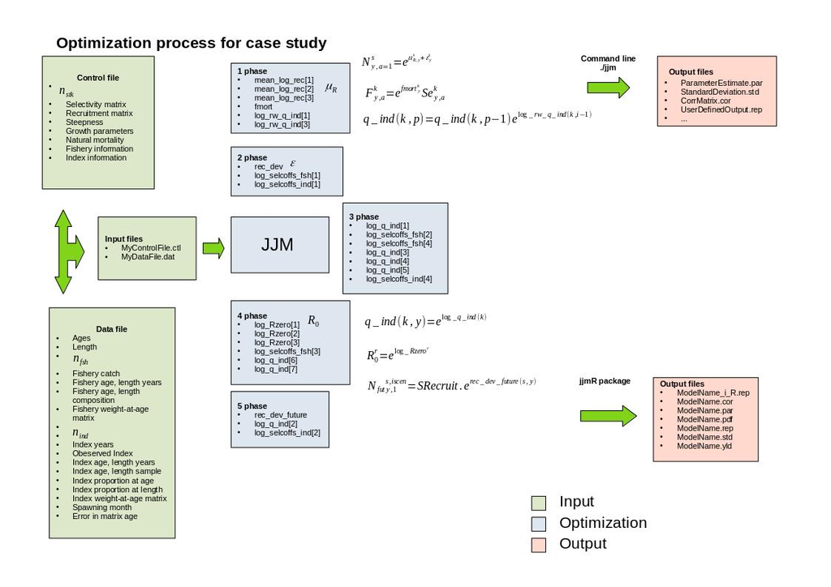

Optimization process of the JJM (Joint Jack Mackerel) model. In green: the inputs (control and data file), in each green box the respective inputs are listed. In blue: the optimization process, in this case it is a model with 5 phases; each box in blue is an optimization phase and the respective parameters to be estimated are listed. In red: the outputs, the top box represents the outputs produced when running the model using the command line, and in the bottom box the outputs using the jjmR package.

# 10 Appendix B: Assessment results of case study

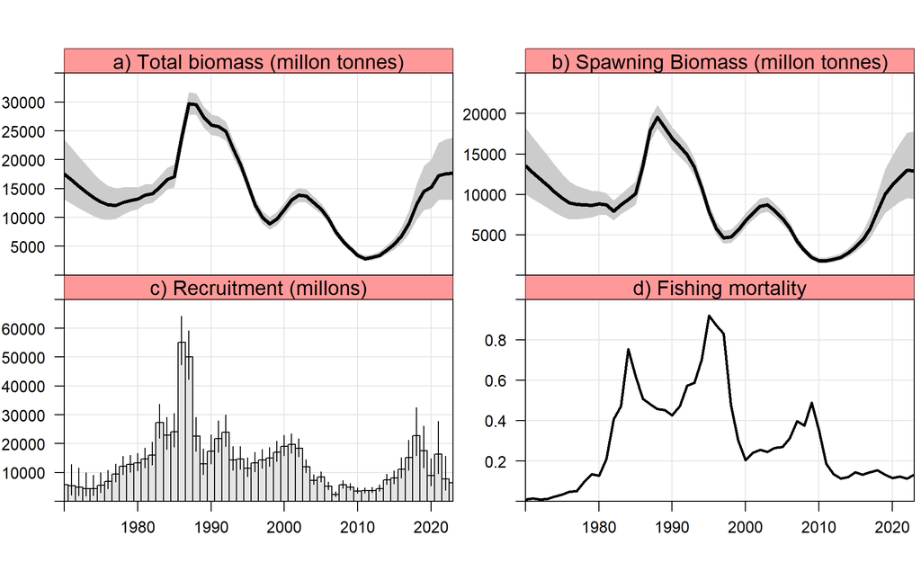

Plot for stock 1. Times series of (a) Total biomass, (b) Spawning biomass, (c) Recruitment, and (d) Fishing mortality.

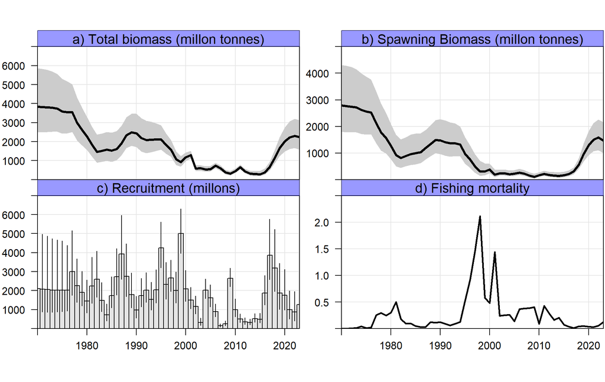

Plot for stock 2. Times series of (a) Total biomass, (b) Spawning biomass, (c) Recruitment, and (d) Fishing mortality.

## 11 References

Fournier, David A., Hans J. Skaug, Johnoel Ancheta, James Ianelli, Arni Magnusson, Mark N. Maunder, Anders Nielsen, and John Sibert. 2012. “AD Model Builder: using automatic differentiation for statistical inference of highly parameterized complex nonlinear models.” *Optimization Methods & Software* 27 (2): 233–49. https://doi.org/10.1080/10556788.2011.597854.

Fournier, David, and Chris P. Archibald. 1982. “A General Theory for Analyzing Catch at Age Data.” *Canadian Journal of Fisheries and Aquatic Sciences* 39 (8): 1195–1207. https://doi.org/10.1139/f82-157.

Hilborn, Ray, and Carl J. Walters. 1992. “Harvest Strategies and Tactics.” In *Quantitative Fisheries Stock Assessment: Choice, Dynamics and Uncertainty*, 453–70. Boston, MA: Springer US. https://doi.org/10.1007/978-1-4615-3598-0_15.

Restrepo, Victor. “GLOSARIO de Términos Pesqueros.” *ICCAT*.

Schnute, Jon T., and Laura J. Richards. 1995. “The influence of error on population estimates from catch-age models.” *Canadian Journal of Fisheries and Aquatic Sciences* 52 (10): 2063–77. https://doi.org/10.1139/f95-800.

“SPRFMO SC10-Report.” 2022. *10th SPRFMO SC Meeting (SC10)*.